# Lectures on the Philosophy of Mathematics.Hamkins2020

### **加倍立方体** **Doubling the cube**

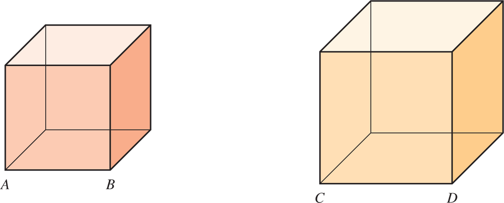

### **三分割角度** **Trisecting the angle**

另一个长期存在的经典问题是三*等分角度*的问题。问题是，给定一个角度，构造一个三分割，这个角度正好是它的三分之一大小。在某些情况下，当然，可以很容易地构建三分割。例如，如果原始角度是直角，那么三分线将是一个60*°*角，这个角出现在一个等边三角形中，我们可以很容易地构造;类似地，直角的三分面为30*°*，我们可以通过将60*°*角一分为二来构造。

Another long-standing open classical problem is that of *trisecting the angle*. The problem is, given an angle, to construct a trisection of it, an angle that is exactly one-third the size. In some cases, to be sure, one may easily construct the trisection. For example, if the original angle is a straight angle, then the trisection would be a 60*°* angle, which arises in an equilateral triangle, and this we can easily construct; similarly, the trisection of a right angle has 30*°*, which we can construct by bisecting a 60*°* angle.

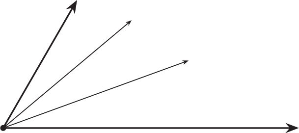

但考虑一个60*°*的角度，其三分面为20*°*。如果你能构造出这样的角度，那么你可以构造一个单位直角三角形，其腿因此长度为 cos（20*°*）。三角学的三重角公式表明，cos *θ* = 4cos<sup>3</sup>（*θ/*3） − 3cos （*θ/*3），因此，

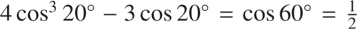

But consider an angle of 60*°*, whose trisection would be 20*°*. If you could construct such an angle, then you could construct a unit right triangle with this angle, whose leg was therefore of length cos(20*°*). The triple-angle formula of trigonometry shows that cos *θ* = 4cos<sup>3</sup>(*θ/*3) − 3cos (*θ/*3), and consequently,

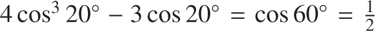

### **圆的平方** **Squaring the circle**

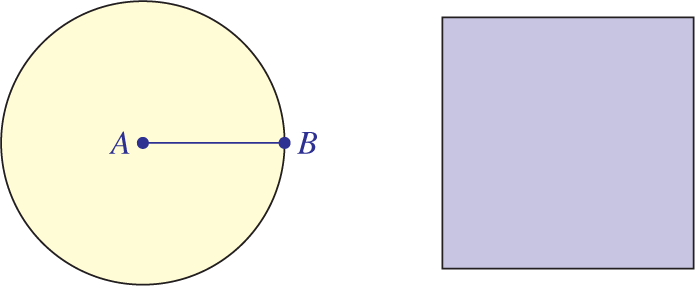

### **圆方形与角三分线** **Circle-squarers and angle-trisectors**

自古以来开放且直到十九世纪才解决的立方加倍、三等角和圆平方问题的解决，无疑凸显了代数域扩张理论中抽象发展的巨大力量。

The resolution of the doubling-the-cube, trisecting-the-angle, and squaring-the-circle problems, having been open since antiquity and solved only in the nineteenth century, surely highlights the enormous power of the abstract developments in the theory of algebraic field extensions.

然而，由于每种情况下的解答都是不可能的证明而非可能性，且这些证明并非几何学家直接获得，而是依赖代数域扩张理论，一些固执的人拒绝接受不可能证明，继续寻找积极解。数学家兼逻辑学家查尔斯·道奇森（更为人熟知的名字是作家刘易斯·卡罗尔）曾写过他试图说服这些“圆方论者”承认错误时的挫败感;逻辑学家奥古斯都·德·摩根（1872年）在其著作《*悖论预算*》中嘲讽了这些理论。

Yet, because the resolution in each case was a proof of impossibility rather than possibility, and furthermore because the proofs were not directly accessible to geometers but relied on the theory of algebraic field extensions, some stubborn souls refused to accept the impossibility proofs and carried on with the search for positive solutions. Mathematician and logician Charles Dodgson, better known as the author Lewis Carroll, wrote of his frustrations at trying to convince these “circle-squarers” of their errors; and logician Augustus De Morgan (1872) ridiculed them in his work *A Budget of Paradoxes*.

## **4.3 替代工具集** **4.3 Alternative tool sets**

自古以来，经典的直尺与圆规工具组一直用于几何构图。与此同时，还有其他工具组合。它们有同样的力量吗？

The classical straightedge-and-compass tool set has been used for geometric constructions since antiquity. Meanwhile, there are other tool sets. Do they have the same power?

### **仅指南针可构造性** **Compass-only constructibility**

经过两千年的直尺和圆规构造，得知任何可以用直尺和圆规构造的点，也能仅用圆规构造，这一定令人惊讶。你不需要直尺。这就是莫尔–莫斯凯罗尼定理的内容，该定理由乔治·莫尔于1672年证明，并于1797年被洛伦佐·莫斯凯罗尼重新发现。该定理可以通过提供仅用指南针模拟直尺所有可能用途的替代方法来证明。这些构造通常比直尺和圆规结构更复杂，但它们确实只使用罗盘。

How surprising it must have been, after two thousand years of straightedge-and-compass constructions, to learn that any point constructible by straightedge and compass can also be constructed with a compass alone. You do not need the straightedge. This is the content of the Mohr–Moscheroni theorem, proved by Georg Mohr in 1672 and rediscovered by Lorenzo Moscheroni in 1797. The theorem can be proved by providing alternative compass-only procedures to simulate every possible use of a straightedge. These constructions are generally more complicated than straightedge-and-compass constructions, to be sure, but they do use only a compass.

例如，给定两个非平行的线段 *AB* 和 *CD*，我们要找到它们对应线的交点。只有在涉及几十个圆的构造中，包括初始选择一个以任意点为中心的圆，且该圆不在任何一条直线上，才能用圆规完成。同样，必须证明给定一条线段和一个圆，只需用圆规即可找到对应直线与圆的交点（假设它们确实相交）。在使用不同方法的构图中，这也可以仅用圆规完成，具体取决于直线是否经过圆心。

For example, given two nonparallel line segments *AB* and *CD*, one seeks to find the point of intersection of their corresponding lines. One can do this with compass only in a construction involving a few dozen circles, including an initial choice of circle centered at an arbitrary point not on either line. Similarly, one must show that given a line segment and a circle, one can find the intersection points of the corresponding line with the circle (assuming they do intersect) using the compass only. This also can be undertaken with compass only in a construction that uses different methods, depending on whether the line passes through the center of the circle.

### **仅直尺可构造性** **Straightedge-only constructibility**

结果的对偶版本要求仅用直尺构造，前提是一开始就给出一个带中心的单一圆。庞斯莱-斯坦纳定理由让·维克多·庞斯莱于1822年猜想，1833年由雅各布·斯坦纳证明，该定理断言，任何可用直尺和圆规构造的点，只要有这样的初始圆，都可以仅用直尺构造。

A dual version of the result calls for straightedge-only constructions, with the stipulation that one is provided at the outset a single circle with its center. The Poncelet-Steiner theorem, conjectured by Jean Victor Poncelet in 1822 and proved by Jakob Steiner in 1833, asserts that indeed, any point constructible by straightedge and compass can be constructed by straightedge alone, given such an initial circle.

证明的基本思想是将罗盘的任意用途反射回初始圆，用该圆进行构造，然后将结果反馈到预期应用中。请注意，初始圆圈的大小可能与预期应用相差甚远。该定理类似于并严格推广了16世纪洛多维科·费拉里和杰罗拉莫·卡尔达诺关于“生锈”罗盘在固定半径上的威力的研究，表明这些罗盘在构造性上等价于普通罗盘。事实上，锈迹罗盘结果是庞斯莱-斯坦纳定理的推论，因为可以用锈迹罗盘画出初始圆，然后只用直尺继续。与此同时，锈罗盘定理的证明更简单，因为对于任意想要的另一个圆，可以构造一个具有相同中心的锈罗盘圆，然后用类似的三角形反对锈圆盘圆的应用，并将结果重新传递回去，从而省略了另一个圆的需要。

The basic idea of the proof is to reflect any desired use of the compass back to the initial circle, undertake the construction with that circle, and then to transfer the result back up to the intended application. Note that the initial circle might be quite a different size or quite distant from the intended application. The theorem is similar to and strictly generalizes the sixteenth-century results of Lodovico Ferrari and Gerolamo Cardano concerning the power of “rusty” compasses, stuck at a fixed radius, showing that indeed these are constructively equivalent to an ordinary compass. Indeed, the rusty compass result is a consequence of the Poncelet-Steiner theorem, since one may use the rusty compass to make the initial circle and then carry on with the straightedge only. Meanwhile, the rusty compass theorem admits an easier proof, since for any desired use of another circle, one can construct a rusty-compass circle with the same center, and then use similar triangles to reflect the application to the rusty-compass circle and transfer the result back again, thereby omitting the need for the other circle.

### **带有标记尺的建造** **Construction with a marked ruler**

与此同时，让我们现在考虑用额外的建筑工具来补充传统工具集。人们自然希望能够仅用直尺和圆规构造出无法构造的图形。以标记*尺*为例，它只是带有两个标记或缺口的直尺。允许使用标记尺子，将其放置在指定点上，同时滑动和旋转，使缺口与另外两个图形对齐。

Meanwhile, let us now consider augmenting the classical tool set with additional construction tools. One might naturally hope to be able to construct figures that are not constructible using the straightedge and compass alone. Consider a *marked ruler*, for example, which is simply a straightedge containing two marks or notches. One is allowed to use a marked ruler by placing it so as to lie on a given point, while sliding and rotating so as to align the notches with two other figures.

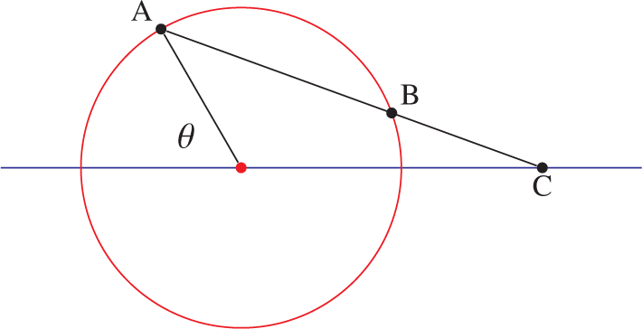

例如，在图中，给定蓝线、红圈和点*A*，可以将标记的尺子放在*A*点，然后通过滑动和旋转找到点*B*和*C*，使其与缺口完全对齐。关键是，如果将尺子向下旋转，对应的点会太近;如果向上，则彼此距离过远。因此，使用标记尺，可以找到与*A*共线且与缺口对齐*的点B*和*C*，这些点相距为单位距离。这点的重要性在于，如果圆也有单位半径，那么（古代已知）*C 处的*角度恰好是指示角度 *θ* 的三等分。因此，使用标记尺可以对任意给定角度进行三分割。因此，标记尺和圆规的制作工具集严格比单用直尺和圆规更强大。

In the figure here, for example, given the blue line and the red circle and the point *A*, one is allowed to place the marked ruler at *A*, and then, by sliding and rotating, to find points *B* and *C* so as to align exactly with the notches. The point is that if one rotates the ruler downward, then the corresponding points would be too close, and if upward, then they would be too far apart. So with the marked ruler, one can find points *B* and *C* that are collinear with *A* and exactly align with the notches, a unit distance apart. The importance of this is that if the circle also has unit radius, then it follows (as known in antiquity) that the angle at *C* is precisely the trisection of the indicated angle *θ*. With a marked ruler, therefore, one can trisect any given angle. And so the construction toolset of a marked ruler and compass is strictly more powerful than a straightedge and compass alone.

### **折纸可构造性** **Origami constructibility**

另一种几何构造方法源自日本折纸艺术的精妙。在熟练的手中，一块纸会依次折叠，创造出令人惊喜且极致美丽的作品。除了折纸的艺术性外，折叠过程本质上是几何性的，折纸也可以作为另一种几何构造方法。它与经典欧几里得直尺和圆规构造方法相比如何？

Another geometric construction method arises from the sublime Japanese paper-folding art of *origami*. In skilled hands, a single square of paper is folded successively to produce surprising works of exquisite beauty. In addition to this artistic aspect of origami, the process of folding is inherently geometrical, and one may take origami folding as an alternative method of geometric construction. How does it compare with the classical Euclidean straightedge-and-compass construction method?

对于任何允许的折纸折叠，我们会在某条线*l*上折叠，该线由已知信息确定，从而不仅构造该线，还构造了之前构造图形通过该直线的反射。完成一个折叠后，我们可以观察到某个点或图形被折叠带到哪里，将该点转移到其反射中。

For any of the allowed origami folds, we fold upon a certain line *ℓ*, determined by given information, and thereby construct not only that line, but also the reflection through that line of any figure we had previously constructed. Having made a fold, we may observe where a given point or figure is carried by the folding, transferring the point to its reflection.

例如，可以沿任意两个给定点所定的直线进行折叠。这种折纸构造可以用直尺和圆规来模拟，因为用直尺我们可以构造出那条直线本身，而用圆规则可以通过构造两个圆来构造通过任意一点直线的反射。另一种允许的折纸折叠是将一个给定点与另一个点重合。这与沿两点之间线段垂直平分线的折叠相同，这同样可以用直尺和圆规来模拟。

It is allowed, for example, to fold along the line determined by any two given points. This origami construction is simulable with the straightedge and compass because with the straightedge, we may construct that line itself, and with the compass, we may construct the reflection through the line of any other point simply by constructing two circles. Another allowed origami fold is to fold so as to bring one given point to coincide with another. This is the same as folding along the perpendicular bisector of the segment between the two points, and this again is simulable by straightedge and compass.

### **螺旋图可构造性** **Spirograph constructibility**

另一种奇思妙想的可构造性方法是*螺旋图*可构造性。某个年龄段的读者可能从童年时期就熟悉螺旋画绘画玩具，该玩具由一些齿轮环和圆圈组成，带有彩色笔孔。通过将一个齿轮放入另一个齿轮，并用笔旋转螺旋，可以创作出丰富多样且复杂的螺旋图形。

Another fanciful method of constructibility would be *spirograph* constructibility. Readers of a certain age may be familiar from their childhood with the Spirograph drawing toy, consisting of some geared rings and circles, with holes for a colored pen. By placing one gear inside another and turning the spiral with the pen, one produces a great variety of pleasing complex spiral figures.

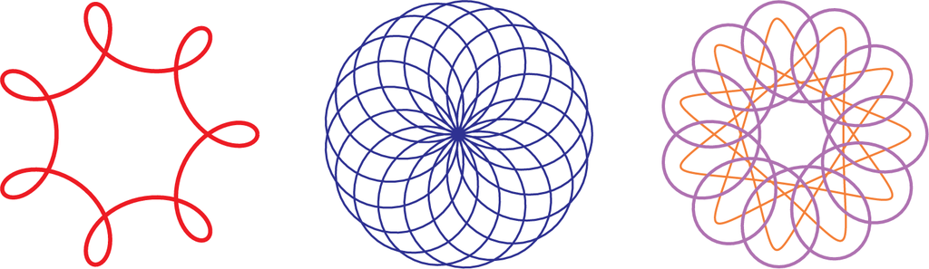

让我们将螺旋图视为一种几何构造方法。所有齿轮的啮合大小相同，因此可以成对，在一般情况下，假设有圆形齿轮和环，具有任意数量的齿数。圆形齿轮在距离中心整数处有笔孔。我们可以将齿轮放置在任何事先构造的点，然后绘制出螺旋图。

Let us consider spirographs as a method of geometric construction. All the gears have the same size mesh, so they can be paired, and in the general case, let us suppose that we have circular gears and rings with any desired number of teeth. The circular gears have holes for the pen at an integer distance from the center. We are allowed to place the gears at any previously constructed points and then draw the resulting spirograph.

螺旋图可构造性有多强大？由此产生的螺旋图可构造点是否也能用直尺和圆规构造？一个有趣的观察是，如果内齿轮直径正好是环齿轮的一半，且绘图点位于内齿轮的周长上，则可以用螺旋图绘制直线。

What is the power of spirograph constructibility? Are the resulting spirograph-constructible points also constructible with the straightedge and compass? One interesting observation is that one can draw straight lines with a spirograph if the inner gear has exactly half the diameter of the ring gear and the drawing point is on the circumference of the inner gear.

与此同时，事实证明，像折纸一样，螺旋图的可构造性严格超出了直尺和圆规的范畴。一种方法是观察到，可以通过螺纹图轻松构造任意边数的正多边形;事实上，几乎每个螺旋图图案都表现出*n*重旋转对称性，其中*n*可由两个齿轮的齿数确定。例如，上面红色螺旋图具有七重旋转对称性，因此其自交点形成一个正七边形。但已知用直尺和圆规无法构造正规七边形。根据高斯–万策尔定理，当且仅当*n*是2的幂和任意数量的不同费马素数（形如2<sup><sup>*2 k*</sup></sup> + 1）的乘积，可以构造正则*n*边形;7 并非以这种方式实现。因此，螺旋图的可构造性超过了直尺和圆规的能力。

Meanwhile, it turns out that, like origami, spirograph constructibility extends strictly beyond that of the straightedge and compass. One way to see this is to observe that one may easily construct regular polygons via spirograph, with any desired number of sides; and indeed, essentially every spirograph pattern exhibits *n*-fold rotational symmetry, where *n* can be determined from the respective number of teeth in the two gears. For example, the red spirograph above has seven-fold rotational symmetry, and so its self-intersection points form a regular septagon. But it is known that with a straightedge and compass one cannot construct a regular septagon. According to the Gauss–Wantzel theorem, one can construct a regular *n*-gon by a straightedge and compass if and only if *n* is the product of a power of 2 and any number of distinct Fermat primes, primes of the form 2<sup>2<sup>*k*</sup></sup> + 1; and 7 is not realized in this manner. So spirograph constructibility exceeds the capabilities of the straightedge and compass.

## **4.4 几何的本体论** **4.4 The ontology of geometry**

这就引出了几何构造我们到底达到了什么效果的问题。当我们在纸上进行几何构造，或者像古典风格那样，通过在沙子上蚀刻时，我们到底在做什么？我们实际构建的图形，难道只是对我们打算考虑的完美、理想的点、线和圆的表现性、不完美的暗示吗？在这种情况下，反对以禁止方式使用指南针的构造似乎很愚蠢，比如我们本可以用允许的使用方式来构造。使用刚性指南针而不是可折叠指南针，就像我们在不完美施工过程中制造的其他便利一样：我们需要注意将直尺对齐，确保它在绘图时不会滑动，等等。

This brings us to the question of what we are achieving with geometric constructions. What are we doing when we carry out a geometric construction on paper, or perhaps as in the classical style, by etching in sand? Surely the figures that we actually construct are meant to be merely representational, imperfect suggestions of the perfect, ideal points, lines, and circles we intend to consider. In this case, it would seem silly to object to constructions that use the compass in a forbidden manner, for example, if we could have made the construction with only the allowed usage. Using a rigid as opposed to a collapsible compass would be like any other convenience that we make in our imperfect construction process: we need to take care to line up the straightedge perfectly and take care that it does not slip while we are drawing, and so on.

如果几何学旨在研究理想完美几何图形——点、线和圆——的本质和特征，那么只要我们认为使用新工具符合合理的几何真理，就没有理由反对用新工具来补充我们的建筑工具集。例如，反对标记尺子的使用方式可能是什么？有人可能会反对说，实际上可能不存在像第130页图中那样与*A*共线且单位距离相距的点*B*和*C*。事实上，基于欧几里得公理无法证明存在这样的点 *B* 和 *C*，正因为（对于某些角度）这些点无法用直尺和圆规构造，而所有可构造点的集合是一个满足所有欧几里得公理的几何宇宙。与此同时，希尔伯特和塔尔斯基等更强的当代公理体系，利用德德金的连续性公理，暗示这些经典的非可构造性问题确实有解。有一个角三分线，以及一个立方体复制器和一个方形圆;这些点存在于空间中，即使我们无法用直尺和圆规构造它们。

If geometry is meant to be about the nature and features of the ideal perfect geometric figures—points, lines, and circles—then there would seem to be no reason to object to augmenting our construction toolset with new tools, provided that we thought their use accorded with sound geometrical truths. For example, what could be the objection to marked rulers, used in the manner described here? One might object that in fact there might not be points *B* and *C* as in the figure on page 130, which are collinear with *A* and unit distance apart. Indeed, one cannot prove on the basis of the Euclidean axioms that there are such points *B* and *C*, precisely because (for some angles) these points are not constructible by straightedge and compass, whereas the collection of all constructible points is a geometrical universe that satisfies all the Euclidean axioms. Meanwhile, the stronger contemporary axiomatic systems of Hilbert and Tarski, using Dedekind’s axiom of continuity, imply that those classical nonconstructibility problems do indeed have solutions. There is an angle trisector, as well as a cube duplicator and a squared circle; these points exist in space, even if we are not able to construct them with straightedge and compass.

通过这种方式，不可能证明揭示了我们几何理论中的缺陷;我们缺少断言这些非标准构造允许我们构造的点确实存在的公理。坚持用直尺和圆规构造，可能会被批评为数学中的一种教条式保守主义。持这种观点的几何学家是否在想，既然这些工具足以让欧几里得证明所有定理，为什么我们要自以为使用除直尺和圆规以外的工具？几何学是关于我们能从欧几里得公理证明的定理，还是关于一个不可变的几何实在，我们可以由此实现更多几何真理？如果是后者，我们可能会寻求更强有力的工具。不可能证明反而暗示了替代非经典几何的概念，这一可能性后来随着非欧几里得几何的发现而被强力爆发。

In this way, the impossibility proofs identify flaws in our geometric theory; we are missing the axioms asserting that the points that these nonstandard constructions allow us to construct actually exist. The insistence on straightedge-and-compass constructions might be criticized as a form of dogmatic conservatism in mathematics. Are geometers with that outlook thinking, why should we presume to use other tools than the straightedge and compass, since these sufficed for Euclid to prove all his theorems? Is geometry about the theorems that we can prove from Euclid’s axioms, or is it about an immutable geometrical reality about which we might realize further geometric truths? If the latter, we might seek stronger tools. The impossibility proofs hint instead at the idea of alternative nonclassical geometries, a possibility that later explodes forcefully into the subject with the discovery of non-Euclidean geometry.

## **4.5 图表和图表的作用** **4.5 The role of diagrams and figures**

让我们更仔细地考虑图示和图形在几何证明论证中的作用。从欧几里得时代至今，几乎每一次几何证明都伴随着一个或多个证明图示。但我们是否应该把这些图解视为它们被用来证明的一部分？还是说图解只是辅助证明的辅助工具？

Let us consider a bit more closely the role of diagrams and figures in geometric proof arguments. From the time of Euclid to the present day, nearly every geometric proof has been accompanied by one or more proof diagrams. But are we to consider these diagrams to be part of the proofs in which they are used? Or are diagrams merely supplemental but inessential aids to proof?

一个问题是，图解本质上比论证假设更具体。在图中，每条线段都有特定的长度，每个角度都是特定的角度，即使我们在论证中对这些长度或角度没有做任何特定假设。由于这种过于具体的现象，图可能会显示偶然的几何关系，比如点在圆圈内而不是外面，即使这种特征依赖于初始图形的细节，而不是假设的必然结果。担心的是，这可能导致演绎的几何误差。

One problematic issue is that diagrams are inherently more specific than the hypotheses of an argument entitle one to deduce. In a diagram, every line segment has a particular length and every angle is a particular angle, even when we have made no particular assumptions about those lengths or angles in the argument. Because of this overspecificity, the diagram might display accidental geometric relations, such as a point being inside a circle instead of outside, even when this feature is contingent on details of the initial figure and not a necessary consequence of the hypotheses. The worry is that this could lead one into deductive geometric error.

### **康德** **Kant**

伊曼努尔·康德在其《*纯粹理性批判*》（1781年）中强调，几何推理可以产生综合的先验真理判断，正如他命题分类的术语所用。康德的数学结论可以属于分析学与综合学区分的综合性一侧，因为数学结论的概念往往严格超越假设的概念——数学从先前的概念中综合新概念。相比之下，分析结论应包含在假设的本质意义中。然而，对康德来说，数学推理也是先验而非后验的，因为它基于纯粹的推理，而非经验。

Immanuel Kant emphasized in his *Critique of Pure Reason* (1781) that geometrical reasoning can produce synthetic a priori truth judgements, to use the terminology of his classification of propositions. Mathematical conclusions for Kant can lie on the synthetic side of the analytic/synthetic distinction, for the concepts of a mathematical conclusion often grow strictly beyond the concepts of the hypotheses—mathematics synthesizes new concepts from prior concepts. An analytic conclusion, in contrast, would be one that is contained in the very meaning of the hypothesis. Yet, for Kant, mathematical reasoning is also a priori rather than a posteriori, since it is based on pure reasoning and not on experience.

欧几里得的文本在很大程度上可以看作是综合而非分析，因为他更专注于他的构造工具和构建新几何图形的方法。他的公理甚至命题陈述直接关乎展示构造方法的力量，展示我们能用这些工具构建或建造的东西，而非根本的几何真理。他的命题——以当代标准来看，颇为奇怪——被陈述为建构目标，而非数学事实陈述。例如，他的第十命题如下：

Euclid’s text can be seen largely as a work of synthesis rather than analysis, in that he is preoccupied with his construction tools and his methods for constructing new geometric figures. His axioms and even his proposition statements are directly concerned with exhibiting the power of the construction methods, with what we can construct or build with those tools, rather than with fundamental geometric truth. His propositions are stated—strangely, by contemporary standards—as construction goals rather than as statements of mathematical fact. For example, his tenth proposition reads like this:

*第10号提案。将给定的线段一分为二。*

*Proposition 10. To bisect a given line segment.*

这就是综合，因为它专注于用我们的几何构造工具构建新的几何图形。相比之下，几何分析关注的是几何事实，例如每条线段确实都有中点，而不是我们构造它们的能力。人们可能会期待几何分析从几何纯粹存在公理开始，断言某些点和几何图形存在，无论我们是否能够构造它们，然后继续探究由此必然存在的几何真理。

This is synthesis, in that it is preoccupied with the process of building new geometric figures using our geometric construction tools. A geometrical analysis, in contrast, would be concerned with the geometric facts, for example that every line segment indeed has a midpoint, rather than with our ability to construct them. One might expect a geometric analysis to begin with geometric pure existence axioms, asserting that certain points and geometric figures exist, whether or not we are able to construct them, and proceed to investigate what further geometric truths there must be as a consequence.

康德进一步指出直觉在数学中的关键作用，提供了我们获得几何知识的途径：

Kant further identifies the critical role of intuition in mathematics, providing the means by which we come to that geometric knowledge:

几何学是一门通过综合方式决定空间性质的科学，但*又是先验*的。那么，我们对空间的表征必须是什么，才能使这种对空间的认识成为可能？它必须起源于直觉。（1781年，B40）

Geometry is a science which determines the properties of space synthetically, and yet *a priori*. What, then, must be our representation of space, in order that such knowledge of it may be possible? It must in its origin be intuition. (1781, B40)

对康德来说，基于这一直觉，初始构造三角形可以涵盖所有三角形的有效性，尽管它具有特异性，因为相关的推理和辅助构造都可以对任意给定三角形进行：

For Kant, an initial construction triangle can encompass validity for all triangles, based on this intuition, despite its specificity, because the relevant inferences and auxiliary constructions can be carried out for any given triangle:

我们绘制的单一图形（三角形）是经验性的，但它表达了概念，同时不削弱其普遍性。因为在这种经验直觉中，我们只考虑构建概念的行为，并从许多决定（例如边长和角度的大小）中抽象出来，这些决定并不改变“三角形”的概念。（1781年，B741–742年）

The single figure [a triangle] which we draw is empirical, and yet it serves to express the concept, without impairing its universality. For in this empirical intuition we consider only the act whereby we construct the concept, and abstract from the many determinations (for instance, the magnitude of the sides and of the angles), which are quite indifferent, as not altering the concept “triangle.” (1781, B741–742)

康德还在数学的其他领域发现了合成先验判断，包括算术。

Kant also finds synthetic a priori judgements elsewhere in mathematics, including arithmetic.

### **休谟论几何的算术推理** **Hume on arithmetic reasoning over geometry**

休谟（1739年）写道几何感知作为知识来源的可错性：

Hume (1739) writes on the fallibility of geometrical perception as a source of knowledge:

我已经观察到，我们通过几何学或艺术来确定人物比例;尽管它在普遍性和准确性上远胜感官和想象力的松散判断;但从未达到完美的精确和精准。其基本原理仍源自物体的整体外观;而当我们审视自然的极其微小的脆弱性时，这种表象永远无法给我们带来任何安全感。我们的观点似乎完美地保证了没有两条右边线能有共同的一段;但如果我们考虑这些观点，就会发现它们总是假设两条直线有明显的倾斜，并且当它们形成的角度极小时，我们没有一条如此精确的直线标准来保证这一命题的真实性。数学的大多数主要决策也是如此。（休谟，1739年，I.III.I）

I have already observ’d, that geometry, or the art, by which we fix the proportions of figures; tho’ it much excels, both in universality and exactness, the loose judgments of the senses and imagination; yet never attains a perfect precision and exactness. Its first principles are still drawn from the general appearance of the objects; and that appearance can never afford us any security, when we examine the prodigious minuteness of which nature is susceptible. Our ideas seem to give a perfect assurance, that no two right lines can have a common segment; but if we consider these ideas, we shall find, that they always suppose a sensible inclination of the two lines, and that where the angle they form is extremely small, we have no standard of a right line so precise, as to assure us of the truth of this proposition. ’Tis the same case with most of the primary decisions of the mathematics. (Hume, 1739, I.III.I)

根据休谟，我们的几何洞见——例如两条截然不同的线不可能有共同的线段——并不基于我们可能绘制或想象的任何图形，因为任何图形都有某种倾斜角，而其他线条可能倾角更小。而代数和算术则带来比几何更为确定的知识形式：

According to Hume, our geometric insight—that two distinct lines can have no segment in common, for example—is not based upon any figure that we might draw or even imagine, as any such figure will some angle of inclination, whereas other lines might have a much smaller inclination. Algebra and arithmetic, meanwhile, lead to a more certain form of knowledge than geometry:

因此，代数和算术是唯一我们可以进行任何复杂推理链，同时保持完美精确和确定性的科学。我们拥有一个精确的标准，可以判断人数的平等和比例;根据它们是否符合该标准，我们确定它们的关系，且不存在任何错误。*当两个数字如此组合，使得一个总有对另一个的每个单位的单位集合时，我们称它们相等;*正因为缺乏这样的扩展等价标准，几何学几乎无法被视为完美且无误的科学。（休谟，1739年，I.III.I，斜体加注）

There remain, therefore, algebra and arithmetic as the only sciences, in which we can carry on a chain of reasoning to any degree of intricacy, and yet preserve a perfect exactness and certainty. We are possest of a precise standard, by which we can judge of the equality and proportion of numbers; and according as they correspond or not to that standard, we determine their relations, without any possibility of error. *When two numbers are so combin’d, as that the one has always an unite answering to every unite of the other, we pronounce them equal;* and ’tis for want of such a standard of equality in extension, that geometry can scarce be esteem’d a perfect and infallible science. (Hume, 1739, I.III.I, italics added)

斜体短语是休谟对康托尔-休谟原则的陈述，见第一章。

The italicized phrase is Hume’s statement of the Cantor-Hume principle, mentioned in chapter 1.

### **曼德斯在图示证明上的表现** **Manders on diagrammatic proof**

Ken Manders（2008a，b）对图解在欧几里得几何中的作用，即实际历史数学实践中的作用有影响。曼德斯最终认为，欧几里得几何实践中的证明分为两部分，图示部分和句法部分，追踪不同的几何假设和信息。图用于推断一般的空间信息，尤其是拓扑信息，如关联或交集（或介于之间，正如二十世纪几何理论中强调的），而精确度量概念如全等性则在证明文本中被明确说明。实际上，人们利用该图来观察几何信息，这些信息在图表参数的微小偏差下保持不变，但文本中对长度和垂直性有明确的声明。

Ken Manders (2008a, b) wrote influentially on the role of diagrams in Euclidean geometry, that is, in actual historical mathematical practice. Manders argues ultimately that proofs in Euclidean geometric practice have two parts, a diagrammatic part and a sentential part, which track different assumptions and information about the geometric situation. Diagrams are used to infer general spatial, or especially topological, information, such as incidence or intersection (or betweenness, as highlighted in the twentieth-century geometric theories), while exact metric concepts such as congruence are always made explicit in the proof text. One uses the diagram in effect to observe geometric information that is invariant under small deviations in the diagrammatic parameters, but exact claims about lengths and perpendicularity are made in the text.

### **当代工具** **Contemporary tools**

数学家通常将它们的几何图形想象为不定的，会在某些地方乱晃、拉伸和塌缩，甚至极端的共线性或简并性，以便在脑海中观察假设的影响，从而判断其构造是否完全普遍，还是依赖于某种偶然特征。现代技术明确实现了这种动态性，例如交互式计算机几何系统GeoGebra，允许操作构图的输入点，同时实时传递构造的线和圆。无论是在脑海中还是在电脑屏幕上，这种可视化都能可靠地揭示偶然几何关系的真实面貌。

Mathematicians commonly imagine their geometrical figures as indeterminate, flopping about, stretching, and collapsing, even to extreme cases of collinearity or degeneracy, in order to observe in their minds the effects of their hypotheses, and thereby to gauge whether their construction is fully general or dependent on some contingent feature. Modern technology enables this dynamism explicitly, such as with the interactive computer geometry system GeoGebra, which allows one to manipulate the input points of a construction while the constructed lines and circles are carried along in real time. Such visualizations, whether in the mind alone or on a computer screen, can reliably reveal accidental geometric relations for what they are.

### **如何与人说谎** **How to lie with figures**

在几何论证中，图表很少能完美绘制。即使是几何图中非常小的误差或不完美，有时也可能导致错误的几何结论。让我来说明一下，下面这个错误的“证明”每个三角形都是等腰三角形，可能会出错。（如果你还记得，等腰三角形是指两边长度相同的三角形。）当然，我们知道这一说法不成立，因为我们可以轻易绘制非等腰三角形;尽管如此，这一论点看起来很有说服力。你能发现任何错误吗？

In geometric argument, diagrams are seldom perfectly drawn. And even a very small error or imperfection in a geometric diagram can sometimes lead one to a false geometric conclusion. Let me illustrate how things can go wrong in the following false “proof” that every triangle is isosceles. (An isosceles triangle, if you recall, is one with two sides the same length.) We know, of course, that this claim is not true, since we may easily draw nonisosceles triangles; nevertheless, the argument appears solid. Can you spot any error?

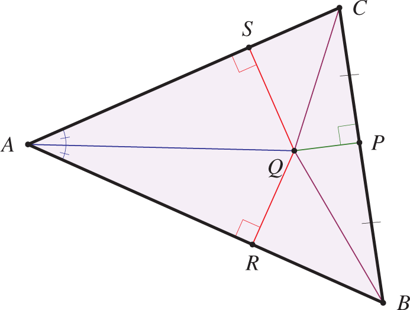

其主张每个三角形都是等腰三角形。为了“证明”这一点，考虑一个任意三角形△*ABC*。构造 ∠*A* 处的角平分线（蓝色）和线段 *BC* 在中点 *P* 处的垂直二分线（绿色），设 *Q* 为交点。从*Q*到*AB*在*R*处垂直下放（红色），在*S*处下到*AC*。由于*P*是*BC*的中点，*而PQ*是垂直的，我们通过毕达哥拉斯定理推导出*BQ*≅*CQ*。由于*AQ*是∠*A*的角平分面，三角形*AQR*和*AQS*相似，且它们共享斜边，因此全等。因此，*AR*≅*AS，QR*≅*QS*。因此，△*BQR*根据斜边-腿同余定理与△*CQS*同余。所以*RB*是*SC*的≅。因此，

The claim is that every triangle is isosceles. To “prove” this, consider an arbitrary triangle △*ABC*. Construct the angle bisector (blue) at ∠*A* and the perpendicular bisector (green) of segment *BC* at midpoint *P*, and let *Q* be the point of intersection. Drop perpendiculars (red) from *Q* to *AB* at *R* and to *AC* at *S*. Because *P* is the midpoint of *BC* and *PQ* is perpendicular, we deduce *BQ* ≅ *CQ* by the Pythagorean theorem. Since *AQ* is the angle bisector of ∠*A*, the triangles *AQR* and *AQS* are similar, and since they share a hypotenuse, they are congruent. It follows that *AR* ≅ *AS*, and also *QR* ≅ *QS*. Therefore △*BQR* is congruent to △*CQS* by the hypotenuse-leg congruence theorem. So *RB* ≅ *SC*. And therefore,

[figure not shown]

因此三角形是等腰的，正如所愿。由此可得一个简单的“推论”，即每个三角形都是等边的，因为在证明中我们是从三角形△*ABC*的任意顶点A出发，因此该论证表明每对相邻边都是全等的。

and so the triangle is isosceles, as desired. It follows as an easy “corollary” that every triangle is equilateral, because in the proof we had proceeded from an arbitrary vertex *A* of triangle △*ABC*, and so the argument shows that each pair of adjacent sides is congruent.

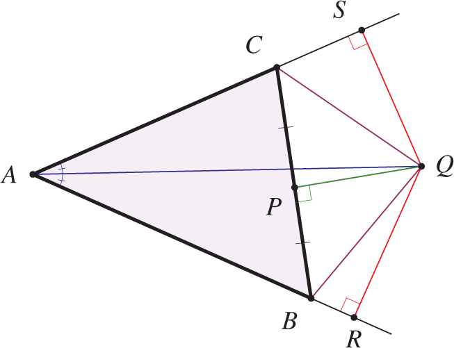

也许有人会批评我们上面给出的证明，说我们不一定知道*A处的*角平分线在三角形内侧与*BC*相交。也许交叉点位于三角形之外，如图所示。但“证据”同样适用于这个案子。即，我们再次设 *Q* 为 ∠*A* 处的角平分线与 *BC* 在中点 *P* 处的垂直平分线的交点，同时将 *Q* 的垂直线降为 *R* 和 *S*。同样，我们通过毕达哥拉斯定理得到*BQ*≅*CQ*，使用三角形△*BPQ*≅△*CPQ*。同样，我们得到 △*ARQ* ≅ △*ASQ*，因为它们是相似且斜边相同的三角形。因此，我们再次通过斜边腿得出 △*BQR* ≅ △*CQS*。因此我们推导出 *AB* ≅ *AR* − *BR* ≅ *AS* − *CS* ≅ *AC*，因此三角形是等腰三角形。读者将发现章节末练习题中论证的缺陷。

Perhaps someone might criticize the proof we gave above by saying that we do not necessarily know that the angle bisector at *A* intersects *BC* on the inside of the triangle. Perhaps the intersection point is outside the triangle, as in the diagram here. But the “proof” works just as easily for this case. Namely, we again let *Q* be the intersection of the angle bisector at ∠*A* with the perpendicular bisector of *BC* at midpoint *P*, and again drop the perpendiculars from *Q* to *R* and *S*. Again, we get *BQ* ≅ *CQ* by the Pythagorean theorem, using triangles △*BPQ* ≅ △*CPQ*. And again, we get △*ARQ* ≅ △*ASQ* since these are similar triangles with the same hypotenuse. So again, we conclude △*BQR* ≅ △*CQS* by hypotenuse-leg. So we deduce *AB* ≅ *AR* − *BR* ≅ *AS* − *CS* ≅ *AC*, and so the triangle is isosceles. The reader will uncover the flaws of the arguments in the end-of-chapter exercise questions.

### **几何构造中的误差与近似** **Error and approximation in geometric construction**

与此同时，让我们更仔细地分析几何构图中可能存在的误差。当然，在施工过程中，即使极其小心，我们也难免会犯一些小错误，比如指南针的方向或直尺的位置稍微错位。因此，我们并不期望以无限精确的精度精确实现*一个构造*，而是我们实际构造的图形仅仅是我们想象中更完美理想几何对象的一个近似。

Meanwhile, let us analyze a bit more carefully the possibility of error in geometric constructions. Surely when carrying out a construction, even with extreme care, we inevitably make some small errors, perhaps by slightly misplacing the point of the compass or the position of the straightedge. Thus, we do not expect to implement a construction *exactly*, with infinite precision, but rather, the figure we actually construct will be merely an approximation of the more perfect ideal geometric object we imagine.

此外，这些误差在构造过程中可能会累积并放大。熟悉的经典构造对直尺或圆规使用时的这些细微误差有多敏感？我们能否比较不同构造的准确性？

Furthermore, these errors might accumulate and magnify as they propagate through a construction. How sensitive are the familiar classical constructions to such small errors in the use of the straightedge or compass? Might we compare competing constructions in terms of accuracy?

让我们从这个角度重新考虑阿波罗尼乌斯对线段*AB*垂直平分线的构造。给定点*A*和*B*，试图构造中点和垂直平分线。我们先将圆规的点放在*A*点，书写工具在*B*点，然后构造以*A*为中心、半径为*AB*的圆。然而，这样做时，我们并不完全准确地将方位定位在*A*——我们可能实际上将方位放在*A*的某个小邻域内（蓝色标示）。同样，我们不会把书写或蚀刻工具精确放在*B*，而是在*B*的一个小邻域内（橙色标示）内的某个点。然后我们描绘一个以*A*为中心的圆弧，圆弧中有一个靠近*B*的点，如中间面板所示。所有可能符合这些误差界限的弧线空间在模糊的橙色弧线中表示，这是通过计算机绘制数十条此类弧线生成的图像。

Let us reconsider in this light the Apollonius construction of the perpendicular bisector of a line segment *AB*. We are given points *A* and *B* and seek to construct the midpoint and perpendicular bisector. We begin by placing the point of the compass at *A* and the writing implement at *B* and then constructing the circle centered at *A* with radius *AB*. When doing so, however, we are not perfectly accurate in placing the point of the compass at *A*—we may actually place it at some point within some small neighborhood of *A* (indicated in blue). Similarly, we do not place the writing or etching implement exactly at *B*, but instead at some point within a small neighborhood of *B* (indicated in orange). And then we trace out the arc of a circle centered near *A*, containing a point near *B*, as indicated in the middle panel. The space of all such arcs that could arise in conformance with those error bounds is indicated in the blurred orange arc, an image which was produced via computer by drawing dozens of such arcs.

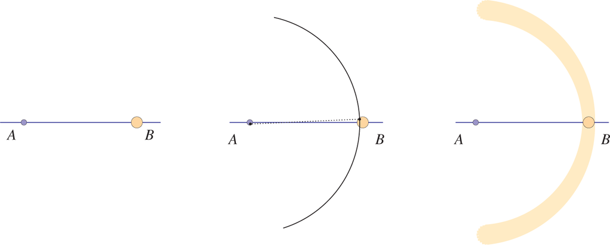

现在我们类似地构造以*B*为中心且包含*A*的圆;这是一个新的罗盘位置，带有类似但独立的误差，导致了这里显示的橙色弧线：

Let us now similarly construct the circle centered at *B* and containing *A*; this is a new compass placement, with its own similar but independent errors, leading to the orange arc of possibilities shown here:

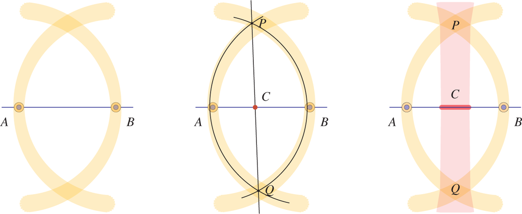

这两个可能性空间在上方和下方较深的橙色区域相交，关键是指南针在误差范围内的任何特定位置都会导致*P*和*Q*的值在该重叠范围内。我们可以把这些重叠区域分别看作*P和**Q*的可能位置空间。

The two spaces of possibility intersect in the darker orange regions above and below, and the point is that any particular placement of the compass within the error bounds will lead to values of *P* and *Q* within that overlap. We might think of these overlap regions as representing the space of possible locations of *P* and *Q*, respectively.

注意在特定样本情形（中图中黑色）中，得到的直线*PQ*明显不垂直于*AB，*且所得点*C*明显不是中点。右图中的粉色阴影区域表示所有可能与*A*和*B*误差界限一致的二分面空间，C的可能结果以*红色表示。*（一个微妙的复杂问题是，这些重叠*区域中P*和*Q*的选择实际上并不独立。）

Notice that in the particular sample case (black, in the middle figure), the resulting line *PQ* is noticeably nonperpendicular to *AB*, and the resulting point *C* is noticeably not the midpoint. The pink-shaded region (in the figure at right) indicates the space of all the bisectors that might arise in conformance with our error bounds on *A* and *B*, with the resulting possibilities for *C* shown in red. (A subtle complication is that the choices of *P* and *Q* from those overlap regions are not actually independent.)

鉴于点*A*和*B*的原始误差界限较小，令人惊讶的是，即使是这样一个标准的简单构造——构造线段的垂直平分线和中点——的误差传播似乎也较大：阴影*红色区域C*相当大，包含许多点，这些点并不被认为是中点。从这个意义上说，阿波罗尼乌斯垂直二分线的构造似乎对罗盘位置的误差很敏感。

In light of the small size of the original error bounds on the points *A* and *B*, it may be surprising that even such a standard simple construction as this—constructing the perpendicular bisector and midpoint of a segment—appears to have comparatively large error propagation: the shaded red region *C* is quite large and includes many points that one would not say are possibly the midpoint. In this sense, the Apollonius perpendicular bisector construction appears to be sensitive to the errors of compass placement.

有没有更好的结构？例如，为了提高*PQ*到*AB*垂直度的准确性，使用更大的圆似乎有助于降低“直角”的变化。但也许这种预期看起来合理，是因为我们迄今假设罗盘误差仅发生在方位的位置，而非实际绘制弧线时。例如，可以想象在使用过程中罗盘弯曲也会产生误差，尤其是当罗盘非常大时，导致偏离圆周，或者滑移，这合理预期会导致随着弧长或角度增加而产生的误差增加，依此类推，而这种模型在大圆时误差可能更大。实际几何构图中似乎存在许多不同的误差来源。

Is there a better construction? For example, to improve the accuracy of the perpendicularity of *PQ* to *AB*, it would seem to help to use a much larger circle, which might lower the variation in the resulting “right” angle. But perhaps that expectation would seem reasonable only because we have so far assumed that compass error arises only with the placement of the points of the compass, not during the course of actually drawing the arc. One can imagine, for example, that errors also arise from a flexing of the compass during use, particularly with a very large compass, causing it to deviate from circularity, or from slippage, which might reasonably be expected to cause increasing error with the length or degree of the arc, and so on, and such a model might have greater errors with large circles. There would seem to be many different sources of error in actual geometric constructions.

构成主义数学家安德烈·鲍尔曾告诉我，在他上学时，教室里有一个大圆规，虽然有些笨重，但用来在黑板上做教学构造。安德烈注意到，使用指南针从两端标记出相同长度的段子，几乎到中心，然后简单猜测所得小段子的中点，可以更可靠地获得更准确的中点结果：

Constructivist mathematician Andrej Bauer mentioned to me that in his school days, the classroom had a large compass which was a bit unwieldy, used for instructional constructions on the chalkboard. Andrej had noticed that one could reliably achieve more accurate midpoint results by using the compass to mark off segments of the same length from each end, nearly to the center and then simply guess the midpoint of the resulting small segment:

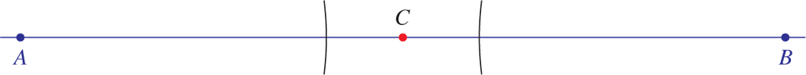

尽管安德烈成绩一向优越，他的老师还是表示反对。

His teacher objected, despite Andrej’s reliably superior results.

原则上，人们可以分析任何常见几何构图的准确性，寻找对各种误差的敏感性，事实上，已有大量文献专门从事这方面的研究。一种更复杂的误差估计模型，在部分工作中使用，将误差视为概率分布，分析该分布如何通过构造传播。例如，一个集中在*点A*和*B*邻域的分布，会通过阿波罗尼乌斯构造引出一个相对弥散的分布，靠近中点。

One could in principle analyze the accuracy of any of the usual geometric constructions, looking for sensitivity to various kinds of error, and indeed there is a literature of work doing precisely this. A somewhat more sophisticated model of error estimation, used in some of this work, views error as a probability distribution, analyzing how the distribution is propagated through a construction. For example, a distribution concentrating in neighborhoods of points *A* and *B* would lead through the Apollonius construction to a comparatively diffuse distribution near the midpoint.

与此同时，人们可能希望通过多次重复构造，以收敛到更准确的答案来提高其准确性。例如，在二分割段算法中，我们可能只需重复两次阿波罗尼乌斯二分割段构造，得到中点候选 *C*<sub>0</sub> 和 *C*<sub>1</sub>，然后我们可以进一步寻找 *C*<sub>0</sub> 与 *C*<sub>1</sub> 的中点，作为一个更准确的中点。或者我们可以以其他方式迭代，希望收敛到实际的中点。例如，我们可以产生多个中点候选，并以中位数作为最终答案。在对输入概率分布的合理假设下，这种方法确实会在有意义的意义上收敛到实际的中点。

Meanwhile, one might hope to improve the accuracy of a construction simply by repeating it several times, aiming to converge to a more accurate answer. For example, in the bisector algorithm, we might simply perform the Apollonius bisector construction twice, producing midpoint candidates *C*<sub>0</sub> and *C*<sub>1</sub>, and we could proceed to find the midpoint of *C*<sub>0</sub>*C*<sub>1</sub> as a further presumably more accurate midpoint. Or we could iterate in some other manner and hope to converge to the actual midpoint. For example, we could produce many midpoint candidates and use the median point as our final answer. With reasonable assumptions on the probability distribution of the input, this method would indeed converge in a meaningful sense to the actual midpoint.

在我看来，误差传播问题直接引向对几何构造在数学中作用的坦率哲学讨论。在几何学中，可以考虑关于几何对象——理想点、线和圆，我们的图形仅能不完美地表示这些对象——但也存在关于构造本身的柏拉图主义，我们将构造视为一个数学对象、算法或过程，接受数学分析，就像复杂性理论中分析算法一样。我们是否可以想象一个理想几何家存在于柏拉图领域，甚至为何不想象一个身穿飘逸白袍、完美实现二分割形构造的理想阿波罗尼乌斯？看到那该多美好啊。我们可以分析算法或几何构造的本质，首先假设它是绝对完美的;其次，通过分析它在不完美执行时的表现，从而脱离柏拉图领域。

To my way of thinking, the issue of error propagation leads directly to a frank philosophical discussion of the role of geometric constructions in mathematics. In geometry, one may consider platonism with respect to the geometric objects—the ideal points, lines and circles, which our figures only imperfectly represent—but there is also platonism with respect to the constructions themselves, where we take the construction as a mathematical object, an algorithm or procedure, subject to mathematical analysis, much like one analyzes algorithms in complexity theory. Shall we imagine an ideal geometer in the platonic realm, indeed, why not an ideal Apollonius himself, with flowing white robes, carrying out a perfect instance of the bisector construction? How lovely that would be to see. We may analyze the nature of an algorithm or geometric construction, first under the assumption that it is carried out with absolute perfection; and then second, departing the platonic realm by analyzing as we did above how well it performs when carried out imperfectly.

### **构建透视棋盘** **Constructing a perspective chessboard**

我想用一个有趣的例子进一步说明工具集限制构造的概念;让我教你如何用两点透视构建棋盘，只用直尺，无需任何测量或计算。我从两个角度看待这项活动。一方面，它展示了用有限工具也能取得惊喜效果，这里指的是直尺。但另一方面，这本来就是一项任何人都能享受的有趣活动。这是你现在真正能做到的事情;你只需要一张纸、一支铅笔和一把直尺。用尺子、筷子或笔记本边缘——任何直的东西都行。我就在这里等你收拾材料。

I should like to illustrate further the concept of toolset-limited constructions with a fun example; let me teach you how to construct a chessboard in two-point perspective, using only a straightedge, with no measuring or calculation of any kind. I view this activity in two lights. On the one hand, it shows how one can achieve surprising results with limited tools, in this case just a straightedge. But on the other hand, it is simply a fun activity that anyone can enjoy. This is something that you can actually do, right now; all you need is a piece of paper, a pencil and a straightedge. Use a ruler or a chopstick or the edge of a notebook—anything that is straight. I shall wait right here while you gather your materials.

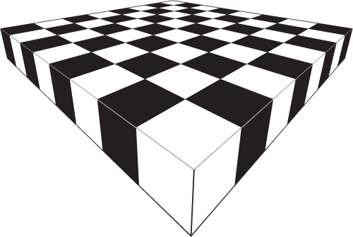

其构造遵循标准的两点透视法。首先，在页面顶部给自己一个地平线，上面有两个点（橙色），我们称之为无限远点，还有一个任意点（蓝色）作为棋盘的前角。将前角点在两边无限延伸，然后画线形成棋盘的前角正方形。这些信息将决定整个电网。

The construction follows the standard two-point perspective method. To begin, give yourself a horizon at the top of the page, with two points (orange), which we call the points at infinity, and an arbitrary point (blue) to serve as the front corner of the chessboard. Extend the front corner point to infinity at each side, and then also draw lines to form the front corner square of your board. This information will now determine the entire grid.

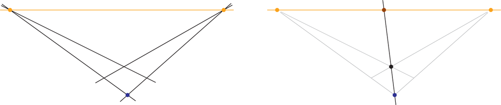

构造前角正方形的对角线，并将其展开至无穷远处的对角点（棕色），如右图所示。之后，将前方正方形的右角延伸至对角线无限远，这决定了第二个正方形的角点，如下图所示：

Construct the diagonal of the front-corner square and extend it to find the resulting diagonal point at infinity (brown) as shown above at right. After this, extend the right corner of the front square to the diagonal infinity, which determines a corner point for the second square, as shown below at left:

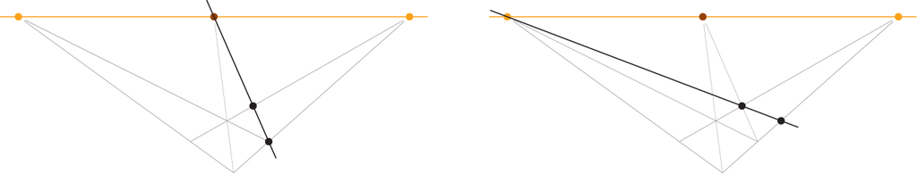

将该点向左延伸至无穷远，形成第二个正方形，如上图右图所示。

By extending that point to infinity at the left, one forms the second square, as shown above at right.

这条直线又决定了前缘上的一个新点，当它延伸到对角线无限远时，确定了第二排上的一个点，如下图左侧所示。通过这种方式继续，可以产生任意数量的第一阶方格。此外，这些直线还决定了网格中的许多额外点，网格是文件和对角线之间的交点三角形：

That line in turn determines a new point on the leading edge, which when extended to the diagonal infinity determines a point on the second rank, as below at left. By continuing in this way, one can produce as many first-rank squares as desired. Furthermore, the lines determine many additional points in the grid, a triangle of intersection points between the files and the diagonals:

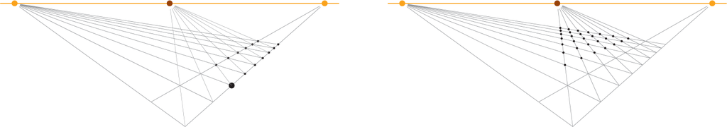

这些点的共线性本质上是德萨格定理的内容，该定理常在射影几何的语境中被讨论。这些点通过向右延伸至无限远，决定棋盘的进一步等级。因此，我们构建了一个完整的棋盘：

The collinearity of these points is essentially the content of Desargue’s theorem, often discussed in the context of projective geometry. These points determine further ranks of the board by extending to infinity at the right. Thus, we have constructed an entire chessboard:

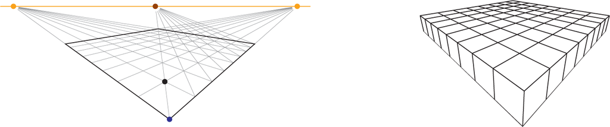

通过在无限远下方添加一个点（请直接在无限远对角点下方，但要往下较远处），可以将前方的面向下延伸，让棋盘看起来更厚实，然后简单地用常见的棋盘图案给棋盘上色阴影或上色。

By adding a point at infinity down below (do so directly below the diagonal point at infinity, but a good distance down), one can extend the leading faces downward to give the board a sense of thickness, and then simply shade or color the chessboard in the usual chessboard pattern.

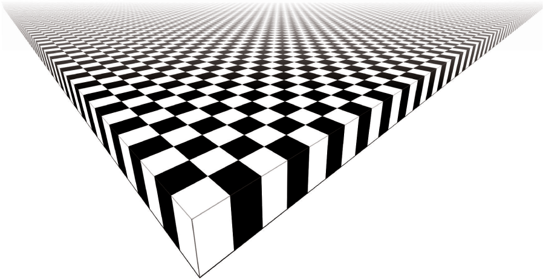

这种方法可以用来制作任意大小的棋盘，任意数量的拼块，且以各种视角排列。在文艺复兴时期的绘画中，可以看到无数令人着迷的实例，展现了铺有瓷砖的地板和宽敞的广场，或以完美的透视方式远去的台阶。许多关于透视的数学思想起源于艺术。通过练习，我希望你能学会如何在有限时间内完成无限的国际象棋盘。

One can use this method to make chessboards of any size, with any number of tiles in any of a variety of perspective views. One finds innumerable fascinating instances of the method in Renaissance paintings, showing tiled floors and great plazas or steps receding into the distance with perfect perspective. Many of the mathematical ideas on perspective originated in art. With practice, I hope you may come to learn how to complete an infinite chessboard in finite time.

## **4.6 非欧几何** **4.6 Non-Euclidean geometry**

接下来让我们考虑几何学中最有趣且最深刻的发展之一——非欧几何的发现。争议焦点在于著名的平行公设，即欧几里得《*几何原论*》中的第五公设，该公设断言如果一条直线横贯于两条直线，并且它们的总和小于两个直角形成角，那么这些直线可以被延伸以相交：

Let us consider next one of the most interesting and profound developments in geometry—the discovery of non-Euclidean geometry. At issue is the famous parallel postulate, Euclid’s fifth postulate in the *Elements*, which asserts that if a line is transverse to two lines and forms angles with them summing to less than two right angles, then the lines can be extended so as to intersect:

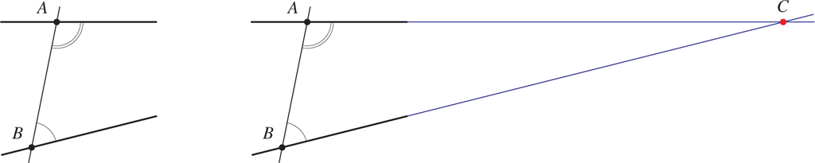

约翰·普莱费尔对该公理的表述（在某些其他几何假设下等价）断言，对于任意直线 *l* 和任意不在*直线 l 上的*点 *P*，最多存在一条通过 *P* 平行于 *l* 的直线。普莱费尔公理的一个强化形式断言，P中恰有*一条线与**l*平行：

John Playfair’s formulation of the axiom, which is equivalent given certain other geometric assumptions, asserts that for any line *ℓ* and any point *P* not on line *ℓ*, there is at most one line through *P* parallel to *ℓ*. A strengthened form of Playfair’s axiom asserts that there is exactly one line through *P* parallel to *ℓ*:

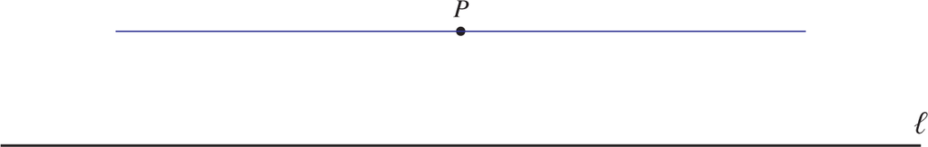

欧几里得曾一度推迟使用这一公理，直到在第29个命题中才首次使用，此前他已经发展了相当多的几何理论。自古以来，数学家们就注意到该公设的明显不同性质，与其他公理相比，它在技术上更为详细且具体，而这些公理通常被视为断言基本几何真理。你觉得这个平行公设更像是一个定理而非公理吗？或许人们自然会期望通过其他公理来证明这一断言。

Euclid had put off the need for this axiom for some time, using it for the first time only in his twenty-ninth proposition, after having developed quite a bit of his geometric theory. Since antiquity, mathematicians have noticed the manifestly different character of this postulate, which is technically detailed and particular in comparison with the other axioms, which are often seen as asserting fundamental geometric truths. Does the parallel postulate strike you as more like a theorem than an axiom? Perhaps one might naturally expect simply to prove this assertion from the other axioms.

事实上，自欧几里得时代以来的两千多年里，几何学家们一直努力做到这一点。关于证明平行公设的尝试有着悠久的历史，托勒密、普罗克洛斯、乔瓦尼·吉罗拉莫·萨凯里、约翰·海因里希·兰伯特、阿德里安-玛丽·勒让德等人在平行理论方面的著名工作。早期工作倾向于从欧几里得几何作为唯一真几何的视角出发，目标是从其他公理证明平行公理。

Indeed, during the more than two thousand years since the time of Euclid, geometers have strived to do exactly that. There is a long history of attempts to prove the parallel postulate, with notable work in the theory of parallels by Ptolemy, Proclus, Giovanni Girolamo Saccheri, Johann Heinrich Lambert, Adrien-Marie Legendre, and others. The early work tended to proceed from a perspective of Euclidean geometry as the one true geometry, with the goal of proving the parallel postulate from the other axioms.

最终，这种视角开始转变。雅诺什·博利亚伊试图通过反驳来证明这一平行假设。因此，他假设了平行公设的否定，并开始进行几何推导。但他并没有发现理想的矛盾，反而发展出一个美丽的新几何理论——这个理论让他得出了许多与古典几何相冲突的奇异新几何结论，但却展现出如此内在的连贯性和几何意义，使其看起来一致且无矛盾。他在1823年写道：“我凭空创造了一个奇异的新宇宙”（参见Greenberg 1992，第163页）。

Eventually, this perspective began to shift. János Bolyai had aimed to prove the parallel postulate by contradiction. He accordingly assumed the negation of the parallel postulate and proceeded to make geometric deductions. But rather than finding the sought-after contradiction, what he found developing instead was a beautiful new geometric theory—a theory that led him to strange new geometric conclusions, many of which stood in conflict with classical geometry, but a theory displaying such an internal coherence and geometric sense that it seemed consistent and without contradiction. He wrote in 1823, “out of nothing I have created a strange new universe” (see Greenberg 1992, p. 163).

约翰·卡尔·弗里德里希·高斯也曾私下研究非欧几里得几何理论数十年，但他计划死后发表，据说他害怕“伯罗提亚人的嚎叫”（Greenberg，1993，第182页），这在高斯数学界的巨大地位下尤为惊人。高斯发现某些非欧几里得几何具有固有且绝对的尺度概念，因此可以用绝对术语定义单位长度，而不仅仅是相对于固定的单位长度。高斯曾推测，如果物理宇宙是非欧几里得的，我们有望发现这个单位尺度，并将其作为绝对的测量标准。

Johann Carl Friedrich Gauss also had been working privately for some decades on his own theory of non-Euclidean geometry, but he planned to publish only posthumously, reportedly fearing “the howl from the boeotians” (Greenberg, 1993, p. 182), a remarkable fear in light of Gauss’s enormous stature in mathematics. Gauss had discovered that certain non-Euclidean geometries have an inherent and absolute notion of scale, such that one may define a unit length in absolute terms rather than always only relative to a fixed unit length. Gauss had speculated that if the physical universe were non-Euclidean, we could hope to discover this unit scale and use it as an absolute standard of measurement.

非欧几里得几何的第一篇发表论述是尼古拉·洛巴切夫斯基于1829年的著作，据说他早在1826年就已公开讲座。由此诞生了数学中一个引人入胜的新学科。这些非欧几里得几何的早期发展基于公理系统，通过从公理中证明定理来发展理论。由此形成的理论看似连贯且一致，但如何判断它是否真的如此呢？一致性问题最终在1868年得到解决，当时尤金尼奥·贝尔特拉米提供了经典欧几里得理论中非欧几里得几何的语义解释，从而证明非欧几何与欧几里得几何一样一致。他通过重新解释点、线、圆和角度的基本概念，以满足非欧几里得公理，提供了非欧几里得理论的模型。

The first published account of non-Euclidean geometry is that of Nikolai Lobachevsky in 1829, and he had given public lectures reportedly as early as 1826. Thus was born a fascinating new subject in mathematics. These early developments in non-Euclidean geometry proceeded on the axiomatic system, developing the theory by proving theorems from the axioms. The resulting theory seemed coherent and consistent, but how was one to know whether it really was? The consistency question was finally resolved in 1868, when Eugenio Beltrami provided semantic interpretations of the non-Euclidean geometries within the classical Euclidean theory, thereby showing that non-Euclidean geometry is as consistent as Euclidean geometry. He provided models of the non-Euclidean theories by reinterpreting the basic notions of point, line, circle, and angle in such a way so as to fulfill the non-Euclidean axioms.

### **球面几何** **Spherical geometry**

例如*，在*球面几何中，我们就像在一个完美抛光的月球表面上行走，而月球本身就是一个自成一体的非欧几里得几何宇宙。我们用彩色粉笔直接在球面表面进行几何构造。这个新几何世界的点是球面上的点，但“线”是*测地线*，即最短长度的路径，在球面上正是大*圆*，从球心与平面的交点起;这些是喷气式飞机在长途飞行中可能飞行的路径。这些圆当然不是球面嵌入的环境欧几里得空间中的直线，但在球面几何宇宙中被视为“直线”，该宇宙只知道球面表面，不了解嵌入空间。生活在球面表面，我们构造三角形、线和圆，就像欧几里得所做的那样，当图形相对于球体大小来说很小时，球面几何几乎是欧几里得的;我们甚至可能察觉不到这种偏差。

In *spherical* geometry, for example, we walk about on the surface of a large sphere as though on the surface of a perfectly polished moon, a self-contained non-Euclidean geometrical universe of its own. We carry out our geometric constructions, perhaps with colored chalk, directly on the surface of the sphere. The points of this new geometric world are the points on the surface of the sphere, but the “lines” are *geodesics*, paths of shortest length, which on a sphere are precisely the *great circles*, arising from the intersection with a plane through the center of the sphere; these are the paths that a jet might fly on a long-distance flight. These circles, of course, are not straight lines in the ambient Euclidean space in which the sphere is embedded, but they count as “straight” lines within the geometric universe of spherical geometry, which knows only of the surface of the sphere and nothing of the embedded space. Living on the surface of the sphere, we construct triangles and lines and circles, just as Euclid did, and when our figures are small in comparison with the size of the sphere, spherical geometry is nearly Euclidean; we might not even notice the deviation.

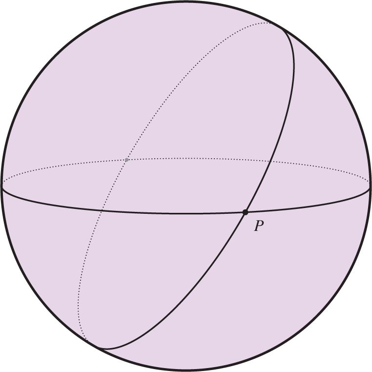

但在大尺度上，球面几何的非欧几里得性质变得显而易见。例如，在球面几何中，三角形的角度加起来可以超过180*°*。要了解这一点，可以从北极（*N*）开始旅程，沿本初子午线向正南行进至赤道*A*;向右转，沿赤道绕行四分之一至*P*;再次右转，向北返回北极点。因此，你形成了一个三角形△*NAP*，包含三个直角。事实上，在球面几何中，所有三角形的直径都超过180*°*，尽管具体多多少取决于三角形的大小。因此，几何体中固有绝对尺度单位——这是欧几里得几何中所缺乏的特征，欧几里得几何在缩放下是不变的。在球面几何中，我们不必将标准米铁棒锁在巴黎的博物馆柜中，因为我们可以将基本单位距离定义为空间本身固有的特征。

But on a large scale, the non-Euclidean nature of spherical geometry becomes obvious. In spherical geometry, for example, the angles of a triangle can add up to more than 180*°*. To see this, start a journey at the North Pole (*N*) and travel due south along the prime meridian to the equator at *A*; turn right and follow the equator one quarter of the way around to *P*; turn right again and head north back to the North Pole. Thus, you have formed a triangle △*NAP*, with three right angles. Indeed, in spherical geometry, all triangles have more than 180*°*, although precisely how much more depends on the size of the triangle. Because of this, the geometry admits an absolute unit of scale inherent in the geometry—a feature lacking in Euclidean geometry, which is invariant under scaling. In spherical geometry, we need not keep a standard meter iron rod locked in a museum case in Paris, for we could define the fundamental unit of distance as an inherent feature of space itself.

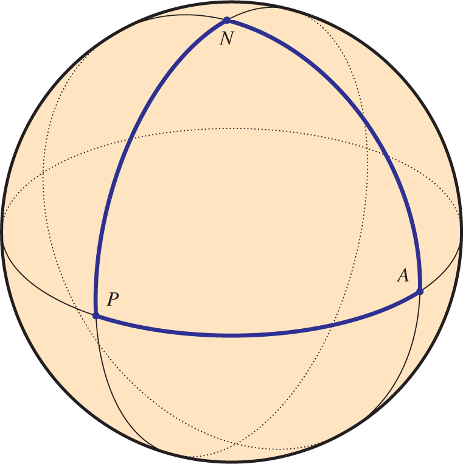

考虑光在球面几何中如何传播，作为物理空间的模型。如果光从点源向各个方向发射，它会像欧几里得空间一样向局部传播。然而，有趣的是，光最终会在环绕地球一周后重新聚集在球的另一侧，也就是对偶点。水世界中的波浪也会类似地重新汇聚：如果你在某一点跳入水中，圆波会向外扩散，并在世界另一端的对偶点重新汇聚。但接下来，必须想象一个更高维的类似空间。一个太空旅行者在一个方向上旅行足够久，最终会返回他们的起点。

Consider how light would propagate in spherical geometry as a model of physical space. If light were emitted in all directions from a point source, it would travel outward locally, much as in Euclidean space. The curious thing to notice, however, is that the light would eventually regather on the opposite side of the sphere, at the dual point after traveling around the world. Waves in a watery world would similarly reconverge: if you jumped into the water at one point, circular waves would emanate outward and reconverge at the dual point on the opposite side of the world. But next, one must imagine a higher-dimensional analogue of this kind of space. A space traveler traveling long enough in one direction would eventually return to their starting point.

在球面几何中，所有直线都相交，因为任意两个大圆都有两个对跖点交点。在球面上，你可以构造你认为是平行线的线，带有一个共同的垂直线，虽然局部看起来它们从未相交，但如果你将它们延伸到地球的半个方向，你会发现它们相交。因此，Playfair公理的强形式不成立。尽管球面几何暗示非欧几里得情况，但欧几里得的其他公理并非全部在球面几何中成立，正如我所描述的。例如，北极和南极是不同的点，但它们分布在许多不同的“线”上，这与欧几里得的第一公设相悖。

In spherical geometry, all lines intersect, since any two great circles have two antipodal intersection points. On the sphere, you might construct what you think are parallel lines, with a common perpendicular, and although locally it might appear that they never intersect, nevertheless, if you extended them halfway around the world, you would find that they meet. Thus, the strong form of Playfair’s axiom fails. Although spherical geometry is suggestive of the non-Euclidean case, nevertheless not all of Euclid’s other axioms are true in spherical geometry as I have described it. For example, the north and south poles are distinct points, but they lie on many different “lines,” contrary to Euclid’s first postulate.

### **椭圆几何** **Elliptical geometry**

Felix Klein 的球面版本——椭*圆*几何模型——通过重新定义*点*为一对对跖点来解决这个问题。因此，北极和南极合计为该几何中的一个点，任何对立点也算作一个点。对于任意两对对跖点，存在唯一的大圆包含它们，满足椭圆几何的第一公设。但与此同时，任意两条直线在椭圆几何中相交，因此平行公设在该形式下不成立。

Felix Klein’s version of the sphere, a model of *elliptical* geometry, addresses this issue by redefining *point* to refer to a pair of antipodal points. Thus, the north and south poles together count as a single point in this geometry, and similarly any pair of opposite points counts as one point. For any two pairs of antipodal points, there is a unique great circle containing them, fulfilling the first postulate for elliptical geometry. But meanwhile, any two lines intersect in elliptical geometry, and so the parallel postulate fails in that form.

### **双曲几何** **Hyperbolic geometry**

接下来考虑*双曲几何*的情况，特别是庞加莱盘的模型。这个几何宇宙的点是固定欧几里得圆盘内部的点，而这些“直线”是圆弧，它们以直角与固定圆的边界相交。这种几何结构有大量的平行线。给定任意直线*AB*和一个不在该直线上的点*C*，则有无限多条通过*C*且不与*AB*相交的直线（以颜色表示）。在该几何中，所有三角形的角和严格小于180*°*，如△*ABC*三角形所示。庞加莱模型中的距离概念有些微妙，因此同余关系也一样，因为必须理解，随着接近边界，圆盘中的欧几里得距离会被大幅放大（以非常精确的方式）。网上有许多有趣的视频展示了在双曲空间中行走的感受，基于这些虚拟体验，人们可以对双曲几何的本质有扎实的直觉。

Consider next the case of *hyperbolic geometry*, with the particular model of the Poincaré disk. The points of this geometric universe are the points interior to a fixed Euclidean disk, and the “lines” are circle arcs, which meet the boundary of the fixed circle at right angles. This geometry has abundant parallel lines. Given any line *AB* and a point *C* not on that line, there are infinitely many lines through *C* and not intersecting *AB* (shown in colors). In this geometry, all triangles have angle sums strictly less than 180*°*, as illustrated by triangle △*ABC*. The concept of distance in the Poincaré model is a little subtle, and consequently also the congruence relation, for one must understand that the Euclidean distances in the disk are to be greatly amplified (in a very precise manner) as one approaches the boundary. One can find numerous fascinating videos online showing what it is like to walk around in hyperbolic space, and based on such virtual experiences, one can gain a robust intuition for the nature of hyperbolic geometry.

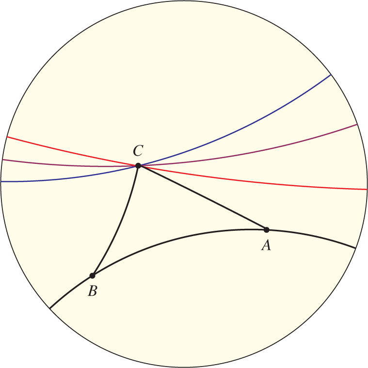

一致性证明通过在欧几里得几何中解释非欧几里得几何，从环境欧几里得空间的角度来看，非欧几里得几何可能是什么样子。由此得出结论，如果欧几里得几何是一致的，那么非欧几里得几何也是一致的。

The consistency proofs work by providing an interpretation of non-Euclidean geometry within Euclidean geometry, a way of seeing what non-Euclidean geometry could be like from the standpoint of an ambient Euclidean space. One concludes that if Euclidean geometry is consistent, then so is non-Euclidean geometry.

但不应仅仅将非欧几里得几何视为欧几里得几何中的模拟，因为这会忽视非欧几何作为自身稳健独立几何概念的观点;它具有自身的本质几何性质，具有自身的几何特征，在重要方面与经典欧几里得几何有根本不同。应想象自己居住在双曲空间本身，而不仅仅是在欧几里得空间内模拟的样子。

But one should not imagine non-Euclidean geometry only as a simulation within Euclidean geometry, for this would miss out on the view of non-Euclidean geometry as its own robust independent geometric concept; it has its own essential geometric nature, with its own geometric character that is fundamentally different from classical Euclidean geometry in important respects. One should imagine inhabiting hyperbolic space as it is, not merely as it is simulated inside Euclidean space.

反过来，也可以在非欧几里得几何中发现欧几里得几何的模拟。想象一个外星物种以双曲空间为基本;他们在其中构建了一个欧几里得空间的模拟。这种解释在两个方向上都有。

Conversely, one may also find simulations of Euclidean geometry inside non-Euclidean geometry. Imagine an alien species taking hyperbolic space as fundamental; they construct within it a simulation of Euclidean space. There are such interpretations in both directions.

### **空间曲率** **Curvature of space**

让我们进一步探讨非欧几里得几何的不同特征。例如，球面几何具有正曲率，部分原因是如果在球面上选取一个点，并在球面上画出半径逐渐递增的圆，那么这些圆的周长增长速度不会像欧几里得平面上那么快。圆略微弯曲，因为它们位于球面中。因此，圆周的公式不再是 2*πr*，而是更小的。球面几何中圆周比欧几里得空间中预期的小;球面几何中，距离你周围的位置数量比欧几里得空间少。

Let us explore a little more the differing character of non-Euclidean geometry. Spherical geometry, for example, has positive curvature, and part of what this means is that if one selects a point on the sphere and draws circles of increasing radius on the surface of the sphere, then the circumferences of these circles do not grow quite as fast as they do in the Euclidean plane. The circles are bent in slightly because they lie in the surface of the sphere. The formula for the circumference, therefore, is no longer 2*πr*, but rather something less. The circumference of a circle in spherical geometry is less than expected in Euclidean space; there are simply fewer locations within a given distance of you in spherical geometry than in Euclidean space.

挥动手臂，思考距离你周围的那些地方。在欧几里得空间中，这指的是一定数量的点，与圆周长有关，或在更高维度中，与对应球面的面积有关。但在球面几何中，臂长处的此类位置数量略少于欧几里得空间。

Swing your arm around and contemplate the locations that exist at arm’s length from you. In Euclidean space, this is a certain number of locations, having to do with the circumference of a circle, or in higher dimensions, with the area of the corresponding sphere. But in spherical geometry, the number of such locations at arm’s length is somewhat less than in Euclidean space.

相比之下，在双曲空间中，情况正好相反;在臂长处的此类位置比欧几里得空间中多，且当空间强烈负曲率时，数量远远多于此。双曲空间是负曲率的，因此圆周随半径增长速度比欧几里得空间中更快。

In hyperbolic space, in contrast, the opposite is true; there are more such locations at arm’s length than in Euclidean space, and indeed, prodigiously more when the space is strongly negatively curved. Hyperbolic space is negatively curved, and so the circumference of a circle grows more rapidly with the radius than in Euclidean space.

如果你是双曲空间城市的居民，那么你公寓附近几个街区内的商店和餐馆数量会非常多，因为在双曲空间里，离你这么近的地点更多。如果空间极度负曲，那么步行可达范围内可能存在完整的未被发现文明，因为强烈的负曲率意味着附近有大量地点。罪犯在双曲空间中很容易逃脱，只需走开一小段距离;很难远远地跟随，因为每一刻都必须在众多方向中做出选择才能继续前进。出于同样的原因，你或你所爱的人很容易在双曲空间中迷失方向，因为要准确找到回家的路非常困难;所以请小心，紧紧抱着它们。

If you are a resident of a city in hyperbolic space, then the number of shops and restaurants within a few blocks of your apartment would be enormous because in hyperbolic space, there are so many more locations that are this close to you. If the space is extremely negatively curved, then there could be whole undiscovered civilizations within walking distance, simply because a strong negative curvature means that there are such a vast number of locations quite nearby. Criminals escape easily in hyperbolic space, simply by walking away a short distance; it is too difficult to follow them far, since at every moment, one must choose from amongst so many further directions to continue. For the same reason, you or your loved ones may easily become lost in hyperbolic space, for it is so difficult to find your way exactly back home again; so please be careful and hold them close.

我再次强调，椭圆几何和双曲几何在非常小尺度上都越来越显得欧几里得。如果几何宇宙是浩瀚无垠的，那么生活在这样一个空间的人可能会基于他们在相对较小尺度上的经验，认为宇宙是欧几里得宇宙的。

Let me emphasize again that both elliptical and hyperbolic geometry appear increasingly Euclidean on very small scales. If the geometric universe were vast, then a person living in such a space might believe the universe to be Euclidean based on their experience at comparatively small scale.

## **4.7 欧几里得中的错误？** **4.7 Errors in Euclid?**

欧几里得*的《几何原本*》常被视为演绎数学推理的典范。但数学上有多完美？他犯过什么错误吗？他的数学发展有没有任何数学或逻辑上的缺陷？这项工作非常扎实，虽然并不完美，但应区分几种类型的错误。我们没有原*版《原著*》，我们对文本的了解都是基于几个世纪后出现的抄本和翻译。欧几里得中的一种错误可以描述为通过隐含假设遗漏公理。在他的论证中，欧几里得常隐含地假设其构造中的某些特征，这些特征是完全合理甚至“显而易见”的，但今天的数学家并不严格地将其视为其公理的推论。首先，对于学究者来说，有些遗漏可以看作是微不足道的，因为欧几里得并未明确说明存在任何点和直线，或者每条直线至少有两个点，或并非所有点都是共线的。但我们还是给他这些额外的事件公理。

Euclid’s *Elements* are often held up as a paragon of deductive mathematical reasoning. But how perfect is it mathematically? Did he make any mistakes? Does his mathematical development have any mathematical or logical flaws? The work is remarkably robust, although not perfect, and one should distinguish several types of error. We have no original copies of the *Elements*, and everything we know of the text is based on copies and translations that came some centuries later. One kind of error in Euclid could be described as the omission of axioms by implicit assumption. In his arguments, Euclid often implicitly assumed certain features of his constructions, features which are perfectly reasonable or even “obvious,” but which mathematicians today do not regard strictly as consequences of his axioms. To begin, for the pedants, there are what can be seen as trivial omissions, for Euclid does not state explicitly that there are any points and lines, that every line has at least two points on it, or that not all points are collinear. But let us go ahead and give him these additional incidence axioms.

### **隐含连续性假设** **Implicit continuity assumptions**

欧几里得隐含地假设他所有的几何图形都是连续的，但并未明说这一点。例如，在他的第一个命题中，他给出了一个线段上的等边三角形构造（该构造与阿波罗尼乌斯二分面构造非常相似），在此过程中，他构造了两个半径为*弧段AB*的圆，一个以*A*为中心，另一个以*B*为中心。然后，他设 *P* 为这些圆的交点，并证明三角形 △*APB* 是等边的。但我们怎么知道这两个圆实际上是相交的呢？为什么会有这样的点*P*？也许你觉得它们应该交汇。但我们声称是从公理中证明定理，而不是基于未明说的额外“显而易见”事实，而且我们似乎没有任何公理表明同一线段上的两个圆必须相交。我们是否可以想象这些圆只是以某种方式穿过彼此，没有精确的交点？也许两者都穿过彼此的缝隙。

Euclid implicitly assumes that all his geometric figures are continuous without stating so. In his very first proposition, for example, he provides the construction an equilateral triangle on a segment (a construction that is very similar to the Apollonius bisector construction), and when doing so, he constructs two circles having segment *AB* as the radius, one centered at *A* and the other at *B*. Then, he lets *P* be the point of intersection of these circles and proves that triangle △*APB* is equilateral. But how do we know that the two circles actually intersect? Why is there such a point *P*? Perhaps you find it obvious that they should intersect. But we are claiming to prove the theorems from the axioms here, not on the basis of unstated additional “obvious” facts, and we seem to have no axiom that implies that two circles on the same segment must intersect. Might we imagine that the circles simply pass through each other somehow, with no precise point of intersection? Perhaps each passes through a gap in the other.

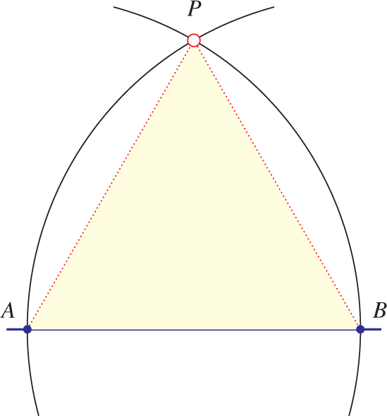

事实上，在有理平面的几何世界中，根本不存在等边三角形。也没有正五边形、正六边形，或除正方形外的正多边形——参见（Hamkins，2020c，第9章）。因此，假设同一半径上的圆必须相交是一个额外的假设，一种隐含的连续性假设，这一点由十九世纪德德金、柯西和魏尔斯特拉斯提出的连续性和极限思想所澄清，正如第二章所讨论的。德德金提出了一个与实数的德德金完备性相关的几何明式连续性公理，该公理被纳入希尔伯特的几何形式体系中。

Indeed, in the geometric world of the rational plane, there simply are no equilateral triangles at all. There are also no regular pentagons or regular hexagons, or regular polygons other than the square—see (Hamkins, 2020c, chapter 9). The assumption that circles on the same radius must intersect is therefore an extra assumption, an implicit continuity assumption, clarified by the continuity and limit ideas that arose with Dedekind, Cauchy, and Weierstrass in the nineteenth century, as discussed in chapter 2. Dedekind proposed an explicit continuity axiom for geometry, related to the Dedekind completeness of the real numbers, and this was incorporated into Hilbert’s formal system of geometry.

### **缺失的“介于之间”的概念** **The missing concept of “between”**

欧几里得中另一个缺失是“介于两者之间”概念的正确理论，该概念在欧几里得的许多构造和论证中被视为一个未定义且未公理化的概念。在许多情况下，欧几里得构造共线点*A*、*B*和*C*，并观察到*B*位于*A*和*C*之间，因此*AB*小于*AC，AC**是**AB*和*BC*的和，依此类推。同样，他假设右侧的角平分线∠*Q*会在*P*和*R*之间的一点与截面*PR*相交。

Another omission in Euclid is a proper theory of the concept of “between,” which appears as an undefined and unaxiomatized concept in many of Euclid’s constructions and arguments. In many instances, Euclid constructs collinear points *A*, *B*, and *C* and observes that *B*, say, is between *A* and *C*, and therefore *AB* is less than *AC*, and *AC* is the sum of *AB* and *BC*, and so forth. Similarly, he assumes that the angle bisector of angle ∠*Q*, as at right, will intersect the segment *PR* at a point between *P* and *R*.

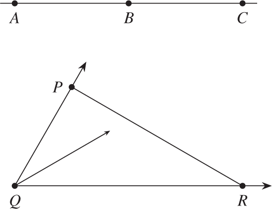

但“介于之间”的概念比预期更为微妙，适当的公理化会阐明该概念的基本性质和假设。为了理解这种微妙之处，请注意，在球面几何和椭圆几何中，中间的概念出现了偏差，因为如果三个共线点*A*、*B*和*C*中的任何一个只是绕球面反方向移动，都可以被视为彼此之间的。在纽约、布拉格和悉尼这三座城市中，哪一个更适合其他城市？这里涉及的部分原因是关于段段的模糊性，因为球面上的两个点*P*和*R*决定了两个线段：你可以从旧金山沿大圆飞往伦敦，要么是飞越大西洋向东（直接航线），要么向西飞越太平洋和亚洲（更长的航线）。在球面几何中，不详细说明就不*提及段**PR*是没有意义的。

But the concept of between is subtler than may be expected, and a proper axiomatization would explicate the fundamental properties and assumptions about this concept. To appreciate the subtlety, notice that in spherical and elliptical geometry, for example, the concept of between goes awry, as there is a sense in which any of three collinear points *A*, *B*, and *C* could be regarded as between the others if one simply goes the other way around the sphere. Of the cities New York, Prague, and Sydney, which one is between the others? Part of what is involved here is an ambiguity about segments, since two points *P* and *R* on the sphere determine two line segments: you can fly from San Francisco to London on a great circle either by flying east over the Atlantic (the direct route), or by flying west over the Pacific and Asia (a longer route). In spherical geometry, it does not make sense to refer to *the* segment *PR* without elaboration.

### **希尔伯特几何** **Hilbert’s geometry**

希尔伯特提出了一种特定的新的几何公理化，对欧几里得进行了补充和修正，并解决了我在本章及其他章节中提到的所有缺陷。他的系统包含若干介于两者之间的公理，例如断言如果一点*B*位于*A*和*C*之间，那么它也位于*C*和*A*之间;给定任意三个共线点，其中恰好有一个位于另外两个点之间（因此排除了球面和椭圆几何）。

Hilbert proposed a specific new axiomatization of geometry, augmenting and correcting Euclid and addressing all the flaws I have mentioned in this chapter and others as well. His system includes several axioms on betweenness, such as the assertion that if a point *B* is between *A* and *C*, then it is also between *C* and *A*; and given any three collinear points, exactly one of them is between the other two (so this excludes spherical and elliptical geometry).

一个更实质的点存在性公理断言：

A more substantial point-existence betweenness axiom asserts:

对于任意两个点*B*和*D*，存在点*A*、*C*和*E*，使得*点B*位于*A*和*C*之间;点*C*位于*B*和*D*之间;点*D*位于*C*和*E*之间。

For any two points *B* and *D*, there are points *A*, *C*, and *E*, such that point *B* is between *A* and *C*; point *C* is between *B* and *D*; and point *D* is between *C* and *E*.

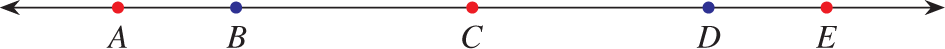

根据该说法，线段*AB*由位于*A*和*B*之间的点组成*，如果L*中没有*点介于**A*和*B*之间，则*A和**B*被定义为线l的“同一侧”。希尔伯特随后加入了公理，使得每条直线都将空间恰好划分为两边，从而使几何成为二维的平面几何，正如所愿。希尔伯特系统还明确列出了若干公理，详细说明直线上点的关联、全余的概念以及平行性的公理。马文·杰伊·格林伯格（1993年，第4章）将*中性几何*称为希尔伯特理论中没有平行公设的几何，即包含关联公理、介于公理、全余公理和连续性公理。这是欧几里得几何和双曲几何中常见的理论，因为希尔伯特的其他公理已经排除了椭圆几何。

According to this account, a line segment *AB* consists of the points that are between *A* and *B*, and points *A* and *B* are defined to be on the “same side” of a line *ℓ* if no point of *ℓ* is between *A* and *B*. Hilbert then includes axioms to the effect that every line partitions the space into exactly two sides, which has the effect of making the geometry two-dimensional, a plane geometry, as desired. The Hilbert system also makes explicit several axioms detailing the notion of the incidence of a point on a line, the concept of congruence and axioms on parallelism. Marvin Jay Greenberg (1993, chapter 4) refers to *neutral geometry* as the geometry of the Hilbert theory without the parallel postulate, that is, with the axioms of incidence, betweenness, congruence, and continuity. This is the theory that is common to Euclidean and hyperbolic geometry, as Hilbert’s other axioms already rule out elliptical geometry.

### **塔斯基几何** **Tarski’s geometry**

塔尔斯基发展了另一种公理化，称为*几何初等理论*，仅基于点，其他几何概念则通过公理化未定义的三位一体之间的关系和定义在点对上的等距关系，并包含一阶连续性方案来表达。

Tarski developed an alternative axiomatization, called the *elementary theory of geometry*, based solely on points, with all the other geometric concepts expressed in terms of points by axiomatizing the undefined trinary betweenness relation and the relation of equidistancy, defined on pairs of pairs of points, and including a first-order continuity scheme.

## **4.8 几何与物理空间** **4.8 Geometry and physical space**

几何学是研究物理空间性质的数学学问吗？历史上的几何学家和自然哲学家确实如此认为。根据这种观点，我们将点、线和圆理解为物理空间中特征的理想化数学化。

Is geometry the mathematical study of the properties of physical space? Geometers and natural philosophers throughout history have indeed thought so. According to this view, we understand points, lines, and circles as mathematical idealizations of features in physical space.

在她对非欧几里得几何哲学传统的阐述中，琼·理查兹（Joan Richards，1988年）认为，正是伯恩哈德·黎曼和赫尔曼·冯·亥姆霍兹引发了关于几何真理本质的哲学讨论。他们各自分析了基本的空间概念，试图找出哪些几何概念在逻辑上是必要的，哪些部分依赖于经验，最终断言欧几里得几何与非欧几里得几何之间的决定是通过经验决定的。她写道，“因此，他们的分析提出了欧几里得几何是否必然或仅是偶然成立的问题”（Richards，1988，第64页）。

In her account of the philosophical tradition in non-Euclidean geometry, Joan Richards (1988) argues that it was Bernhard Riemann and Hermann von Helmholtz who triggered philosophical discussions of the nature of geometrical truth. Each analyzed the basic spatial concept, seeking to discover which geometric concepts were logically necessary and which parts were contingent on experience, asserting ultimately that the decision between Euclidean and non-Euclidean geometry was experientially determined. She writes that “thus, their analysis raised the question of whether Euclidean geometry was necessarily or only contingently true” (Richards, 1988, p. 64).

鉴于非欧几里得几何的可能性，可以将欧几里得空间理论作为一个科学假说进行科学检验。我们如何通过实验判断物理宇宙是欧几里得宇宙还是非欧几里得宇宙？一种方法是简单地形成一个大三角形，测量这些角度的加起来是否达到180*°*。据说高斯利用三座遥远的山峰进行;结果与欧几里得几何相符，且在测量误差范围内。洛巴切夫斯基呼吁在天文尺度上进行三角形实验。

In light of the possibility of non-Euclidean geometry, one might take the Euclidean theory of space as a scientific hypothesis to be scientifically tested. How could we determine experimentally whether the physical universe was Euclidean or non-Euclidean? One way would be simply to form a large triangle and measure the angles to see if they add up to 180*°*. Gauss reportedly did so using three distant mountain peaks; the result conformed with Euclidean geometry to within the margin of error in the measurement. Lobachevsky called for such experiments to be undertaken with triangles on an astronomical scale.

Greenberg（1993）强调了这一点

Greenberg (1993) emphasizes the point that

由于实验误差，物理实验永远无法确凿证明空间是欧几里得的——它只能证明空间是非欧几里得的。

because of experimental error, a physical experiment can never prove conclusively that space is Euclidean—it can prove only that space is non-Euclidean.

测量结果即为其误差范围，如果将180*°*排除在该区间，则表明空间是非欧几里得的;但如果180*°*在误差范围内，那么其他非常接近但不等于180*°*的度数和也会在误差范围内。因此，任何与欧几里得空间兼容的实验结果也与非欧几里得（但近欧几里得）空间兼容。

The measurement will be such as it is, with its margin of error, and if 180*°* is excluded from that interval, then it shows that space is non-Euclidean; but if 180*°* is within the margin of error, then also other sums-of-degrees very near but not equal to 180*°* will also be within the margin of error. Thus, any experimental result compatible with Euclidean space is also compatible with non-Euclidean (but nearly Euclidean) space.

假设物理宇宙最终不是欧几里得宇宙——这会以某种方式推翻欧几里得几何理论的任何方面吗？难道所有定理和构造不还是适用于欧几里得几何所涉及的那种几何吗？如果是这样，这不正已经否定了几何学是物理空间数学研究的观点吗？欧几里得几何关注的是满足欧几里得几何公理的对象——点、线和圆的数学领域，无论物理宇宙是否满足。

Suppose that the physical universe turns out not to be Euclidean—would this somehow refute any aspect of Euclid’s theory of geometry? Would not all the theorems and constructions still be correct for the kind of geometry that Euclidean geometry was about? If so, doesn’t this counterfactual already refute the idea that geometry is the mathematical study of physical space? Euclidean geometry is about the mathematical realm of objects—points, lines, and circles—that satisfy the axioms of Euclidean geometry, whether or not the physical universe does so.

我们目前最好的物理理论确实与各种经典几何理论，无论是欧几里得几何、双曲几何还是椭圆几何，都是物理空间几何的观点相冲突。根据当前理论，空间的本质（物理学家所称的时空）受质量存在影响，质量会扭曲和弯曲质量附近的空间。光在引力影响下会弯曲，这由相对论预测，并通过实验观测得到证实，例如观察到中等质量物体周围远处光源的引力透镜效应。物理空间在几何上比我们讨论的任何几何理论都要复杂得多。

Our best current physical theories indeed have grown to conflict with the view that the various classical geometric theories, whether Euclidean, hyperbolic, or elliptic, are the geometry of physical space. According to current theories, the nature of space (or spacetime as it is regarded by the physicists) is affected by the presence of mass, which warps and curves space in the vicinity of the mass. Light bends under the influence of gravity, as predicted by relativity theory and confirmed by experimental observation, such as observations of gravitational lensing of distant light sources around intermediate massive objects. Physical space is much more complex geometrically than any of the geometric theories we have been discussing.

将几何学视为物理空间研究还有一些问题。也许正如未来某种改进的量子力学版本所解释的，空间（像能量一样）被量子化为离散的不可分割单位;也许它是有限的。并考虑空间的均匀性，即物理空间的局部性质是否处处相同。也许未来改进的物理技术会揭示空间可以在局部被撕裂或退化，使其变得不均匀。

There are further problematic issues with taking geometry to be the study of physical space. Perhaps it will turn out, as explained by some future improved version of quantum mechanics, that space (like energy) is quantized into discrete indivisible units; perhaps it is finite. And consider the homogeneity of space, the question of whether the local nature of physical space is everywhere the same. Perhaps a future improved physics will reveal that space can become torn or degraded somehow locally, making it inhomogeneous.

## **4.9 庞加莱论几何的本质** **4.9 Poincaré on the nature of geometry**

最终，人们会将几何视为关注纯数学问题，脱离与物理空间的必要联系。亨利·庞加莱对上述问题及康德的回应是：

One is led ultimately to a view of geometry as concerned with purely mathematical questions, divorced from any necessary connection with physical space. Henri Poincaré responded to the issues above and to Kant by saying:

然而，仍然存在一个难以逾越的难题。如果几何是一门实验科学，它就不是精确科学，而是需要不断修订的学科。不，从现在起它肯定会错，因为我们知道没有完全刚性的固体。

A difficulty remains, however, and it is unsurmountable. If geometry were an experimental science, it would not be an exact science but rather one subject to continual revision. No, it would be sure of being incorrect from now on, since we know that there are no perfectly rigid solids.

*几何公理既不是综合*的先验*判断，也不是实验事实。*

*Geometric axioms are then neither synthetic* a priori *judgments, nor experimental facts.*

它们是*大会*。在所有可能的约定中，我们的选择以实验事实*为指导*，但它依然*自由*，仅受限于避免所有矛盾的必要性。这样，即使促成其采纳的实验定律仅是近似的，这些公设仍能保持*严格*成立。换句话说，*几何公理*（我说的不是算术公理）*只是伪装的定义*。

They are *conventions*. Among all possible conventions, our choice is *guided* by experimental facts, but it remains *free* and is only limited by the need to avoid all contradiction. In this way, the postulates can remain *strictly* true even when the experimental laws contributing to their adoption are only approximate. In other words, *the axioms of geometry* (I am not speaking of those of arithmetic) *are only definitions in disguise*.

此时，我们应如何理解这个问题：欧几里得几何是否真实？这个问题毫无意义。人们也可以问，公制系统是否为真，旧的度量单位是否为假;如果笛卡尔坐标为真，极坐标为假。一种几何形状不可能比另一种更真实，它只能*更实用*。（庞加莱，2018，第42页，原文强调）

At this point, how should we understand this question: Is Euclidean geometry true? The question does not make any sense. One might just as well ask if the metric system is true and the old units of measure false; if the Cartesian coordinates are true and the polar coordinates false. One geometry cannot be truer than another, it can only be *more useful*. (Poincaré, 2018, p. 42, emphasis in the original)

对庞加莱来说，替代几何的存在意味着物理空间的几何真理无法先验知晓。各种几何框架可以用数学研究，但当它们作为物理现实模型时，实际上只是约定。公理本身定义了它们所涉及的主题。

For Poincaré, the existence of the alternative geometries means that the geometrical truths of physical space cannot be known a priori. The various geometrical frameworks can be studied mathematically, but they amount to conventions when put forth as a model of physical reality. The axioms themselves define the subject that they are about.

## **4.10 塔尔斯基论几何的可判定性** **4.10 Tarski on the decidability of geometry**

让我以回到塔尔斯基的几何初级理论及其所证明的一件事作为本章结尾，在我看来，这对古典几何作为数学活动的学科有深远的影响。也就是说，塔尔斯基证明了他的几何初等理论既完备又可判定。也就是说，他对几何的公理化逻辑上解决了用初等几何语言提出的所有问题，此外，他提供了一种可计算的程序来确定任何此类命题的真伪。太棒了！经过两千年的数学斗争，我们已经把几何简化成机械程序。

Let me conclude this chapter by returning to Tarski’s elementary theory of geometry and something he proved about it, which to my way of thinking has profound implications for the subject of classical geometry as a mathematical activity. Namely, what Tarski proved is that his elementary theory of geometry is both complete and decidable. That is, his axiomatization of geometry logically settles every question that can be asked in the language of elementary geometry, and furthermore, he provides a computable procedure for determining the truth of any such statement. Amazing! After two millennia of mathematical struggle, we have reduced geometry to a rote procedure.

塔尔斯基的几何决策过程源自他关于实闭域的深度定理，他在其中确定了有序实数域结构⟨R，+， ·，0,1， < ⟩的完整公理集合。塔尔斯基证明了有序域语言中的每一条断言在他的实闭域公理上等价于不使用任何量词的断言，因此其真伪易于判定。例如，存在断言∃*x ax*<sup>2</sup> + *bx* + *c* = 0，在实数中等价于判别式非负，*即 b*<sup>2</sup> − 4*ac* ≥ 0，后者断言无量词。Tarski 令人惊讶地证明，有序实数域语言中的*每一个*断言同样等价于无量词断言。这对几何学有影响，因为有序域的完整语言极其丰富——丰富到可以通过描述这些对象的代数方程来指代所有经典几何对象（点、直线、平面、圆、抛物线、圆锥曲线、双曲面、角度等）。因此，在这种形式语言中，可以对所有三角形、圆或锥做出宽泛的断言，要求对于任何代数可表达的性质，还存在具有某些性质的几何对象。因此，通过应用塔斯基判定程序，可以判定任何此类几何断言的真伪。

Tarski’s geometric decision procedure is a consequence of his deep theorem on real-closed fields, in which he identified a complete set of axioms for the ordered real number field structure ⟨ℝ,+, ·,0,1, < ⟩. Tarski proved that every assertion in the language of ordered fields is equivalent over his real-closed field axioms to an assertion not using any quantifiers, whose truth is therefore easily decided. For example, the existential assertion ∃*x ax*<sup>2</sup> + *bx* + *c* = 0 is equivalent in the real numbers to the assertion that the discriminant is nonnegative, *b*<sup>2</sup> − 4*ac* ≥ 0, and this latter assertion is quantifier-free. Tarski proved, amazingly, that *every* assertion in the language of the ordered real number field is similarly equivalent to a quantifier-free assertion. This has consequences for geometry because the full language of ordered fields is extremely rich—rich enough to refer to all the classical geometric objects (points, lines, planes, circles, parabolas, conic sections, hyperboloids, angles, and so on) by referring to the algebraic equations that describe them. In this formal language, therefore, one can make sweeping assertions about all triangles, circles, or cones, requiring that there are further geometric objects with certain properties and so forth, for any algebraically expressible properties. And thus, by applying the Tarskian decision procedure, one can decide the truth of any such geometric assertion.

从乐观主义者的角度看，塔斯基决策程序是几何学主题的理论完成，这一项目始于两千多年前，如今以一种决策程序完成，该程序自动化了几何推理过程，通过死记硬背判定任何几何陈述在实数提供的解析几何模型中任意维度下的真实性。我们已经建造了一台几何真话机器。

From an optimist perspective, the Tarskian decision procedure is a theoretical completion of the subject of geometry, a project begun over two thousand years ago and now completed with a decision procedure that automates the process of geometric reasoning, determining by rote the truth of any geometric statement, in any desired dimension, in the Cartesian model of analytic geometry provided by the real numbers. We have built a geometric truth-telling machine.

当然，对这一宏大愿景的反驳是，塔尔斯基的决策程序仅具有理论价值，因为尽管我们对该程序有具体描述，但实际操作中耗时过长难以发挥作用。塔斯基原始算法的时间复杂度极其庞大且增长迅速，无法被任何初等递归函数限制。算法的改进版本将时间复杂度降至双倍指数，虽然有巨大进步，但实际应用中仍不可行。双指数界限在某些意义上已被证明是基于量词消除的任何程序的最优。

A counterargument to this grandiose vision, of course, is the observation that Tarski’s decision procedure is of only theoretical use, since although we have a concrete account of the procedure, it simply takes far too long in practice to be useful. The time complexity of Tarski’s original algorithm is so huge and fast-growing that it cannot be bounded by any elementary recursive function. Improved versions of the algorithm have brought the time complexity down to doubly exponential, a vast improvement but still infeasible for any practical purpose. The double exponential bound has been proved optimal, in certain senses, for any procedure based, as Tarski’s method is, on quantifier elimination.

另一个严肃的反驳是，该算法在所适用的形式陈述中不支持对整数或自然数的引用，尽管经典几何确实有此类引用。根据哥德尔定理（见第7章），可以推断出算术初等理论不存在判定程序，因此不可能修改塔尔斯基判定程序以包含算术。特别是，我们不能用塔斯基程序来判断诸如“这个特定的构造程序是否能在有限步内达到某种构型？”或“是否存在具有这些特定性质的构造程序？”这样的问题。从这个意义上说，塔斯基的决策程序并未完成这种更完整的几何概念。

Another serious counterargument is that the algorithm does not accommodate reference to integers or natural numbers in the formal statements to which it applies, although classical geometry does make such references. In light of Gödel’s theorems (see chapter 7), it follows that there can be no decision procedure for the elementary theory of arithmetic, and so it will be impossible to modify the Tarskian decision procedure to include arithmetic. In particular, we cannot use Tarski’s procedure to decide questions of the form, “Will this specific constructive procedure achieve a certain configuration in finitely many steps?” or “is there a constructive procedure with these specific properties?” In this sense, this fuller conception of geometry is not completed by the Tarskian decision procedure.

## **进一步思考的问题** **Questions for further thought**

**4.1** 在我们给出的指南针等价定理证明中，我们同时使用了直尺和指南针。此外，由于证明依赖矩形，也使用了平行公设。尽管如此，已有仅用指南针而未使用平行公设的证明。找到这样的证明（例如在欧几里得中或网上搜索），并自行进行构造。解释为什么这种争论方式可能更好。

**4.1** In the proof we gave for the compass equivalence theorem, we used both a straightedge and a compass. In addition, because the proof relied on rectangles, it also used the parallel postulate. Nevertheless, there are proofs of this theorem using only a compass and not using the parallel postulate. Find such a proof (for example, in Euclid or by searching online) and undertake the construction yourself. Explain why this manner of arguing might be superior.

**4.2** 证明任意两个可构造数的和和乘积是可构造的。

**4.2** Show that the sum and product of any two constructible numbers are constructible.

**4.3** 构造一个正六边形，带有直尺和圆规，给定一个用作边的段。还有哪些正多边形你可以轻松构建？（但请查阅高斯–旺策尔定理。）

**4.3** Construct a regular hexagon with a straightedge and compass, given a segment to be used as a side. Which other regular polygons can you easily construct? (But look into the Gauss–Wantzel theorem.)

**4.4** 讨论经典数轴上不可构造数的本体论。如果我们无法构造这些点，这些点还存在吗？

**4.4** Discuss the ontology of nonconstructible numbers on the classical number line. Do these points exist if we cannot construct them?

**4.5** 在文本中，我们描述了如何原则上通过从两个点*A*和*B*开始，穷尽构造平面上所有可构造的点，然后在每个阶段用这些点形成所有可能的线和圆，找到它们的交点，然后再进入下一阶段。这个过程是否取决于你从*哪个点A*和*B*开始？如果是这样，我们以什么意义定义了“可构造点”？对“可构造数”的定义是否有类似的反对意见？

**4.5** In the text, we described how one can in principle exhaustively construct all the constructible points in the plane by starting with two points *A* and *B*, and then at each stage form all possible lines and circles using those points and finding their points of intersection before proceeding to the next stage. Does this process depend on which particular points *A* and *B* you start with? If so, in what sense have we defined “constructible point”? Is there a similar objection to the definition of “constructible number”?

**4.6** 几何构造在尺度下何种意义上不变？如果我可以用直尺和圆规构造图形，那么对于任意*x*，我能否构造出乘以*x*倍比例的图形？可构造数在任意缩放下是不变的吗？

**4.6** In what sense are geometric constructions invariant under scaling? If I can construct a figure using a straightedge and compass, can I construct the same figure scaled by a factor of *x*, for arbitrary *x*? Are the constructible numbers invariant under arbitrary scaling?

**4.7** 讨论罗盘等价定理作为某些非欧几里得构造工具（如标记尺或折纸、螺旋图）负面出现的情况的积极实例。

**4.7** Discuss the sense in which the compass equivalence theorem is a positive instance of a situation that arises negatively with some non-Euclidean construction tools, such as a marked ruler or the use of origami or spirographs.

**4.8** 任何物理直尺都有一定长度，任何物理罗盘都可以打开到最大半径。这些物理限制是否导致理论上限制了它们原则上执行任意直尺和圆规构造的能力？先考虑只有罗盘受限或只有直尺受限的情况，然后全面考虑两者都受限的情况。参见Hamkins（2020a）、Goucher（2020）。

**4.8** Any physical straightedge has some finite length and any physical compass can open to a maximum radius. Do these physical limitations cause theoretical limitations in their capacity in principal to undertake arbitrary straightedge and compass constructions? Consider first the cases where only the compass is limited or only the straightedge is limited, and then consider fully the case where both are limited. See Hamkins (2020a), Goucher (2020).

**4.9** 可构造平面是否满足与实数平面 R<sup>2</sup> 相同的几何真理？换句话说，对于几何语言中可表达的断言，可构造平面是否是实数平面的基本子结构？[提示：实数平面中有解点，实现了角的三分割和立方体的倍增。这些信息在那里可以验证吗？]

**4.9** Does the constructible plane satisfy all the same geometric truths as the real number plane ℝ<sup>2</sup>? In other words, is the constructible plane an elementary substructure of the real number plane, with respect to assertions expressible in the language of geometry? [Hint: The real number plane has solution points realizing the trisection of the angle and the doubling of the cube. Are these verifiable there?]

**4.10** 我们不能用直尺和圆规把立方体加倍，但能把正方块加倍吗？给定一个正方形，构造一个面积恰好是正好两倍的正方形。

**4.10** We cannot double the cube with a straightedge and compass, but can you double the square? Given a square, construct a square with exactly twice the area.

**4.11** 考虑其他经典作图，如角度的二分，并分析指南针或直尺位置误差的传播。

**4.11** Consider some other classical construction, such as the bisection of an angle, and analyze the propagation of error in the placement of the compass or straightedge.

**4.12** 数轴上的每个点都可以通过直尺和圆规构造吗？你怎么知道？

**4.12** Is every point on the number line constructible by straightedge and compass? How do you know?

**4.13** 康托尔关于存在不可构造数的论证是否构成性？它是否能提供某个特定的不可构造数的存在？

**4.13** Is the Cantor argument that there are nonconstructible numbers constructive? Does it provide the existence of a particular nonconstructible number?

**4.14** 考虑另一种经典构造，如角平分段构造，并在GeoGebra系统中实现。

**4.14** Consider another classical construction, such as the angle bisector construction, and implement it in the GeoGebra system.

**4.15** 论证任何可以用直尺、圆规和文中提到的两种基本折纸折法完成的构造，也可以仅用直尺和圆规完成。

**4.15** Argue that any construction that can be undertaken with the straightedge, compass, and the two basic origami folds mentioned in the text can also be undertaken with a straightedge and compass only.

**4.16** 批评每个三角形都是等腰三角形的证明。它有缺陷吗？

**4.16** Criticize the proof that every triangle is isosceles. Is it flawed?

**4.17** 几何是物理空间的数学研究吗？如果不是，几何学的主题是什么？

**4.17** Is geometry the mathematical study of physical space? If not, what is the subject matter of geometry?

**4.18** 讨论是否可以通过实验判断物理空间是否为欧几里得的问题。测量能显示空间是欧几里得空间吗？或者它不是欧几里得？

**4.18** Discuss the question of whether one could determine whether physical space is Euclidean experimentally. Could a measurement show that space is Euclidean? Or that it is not Euclidean?

**4.19** Playfair 对平行公设的表述在球面几何中是否成立？如果不是，为什么这种几何被认为是非欧几里得的？

**4.19** Is Playfair’s formulation of the parallel postulate true in spherical geometry? If not, why is this geometry considered non-Euclidean?

**4.20** 我们对欧几里得几何真理的直觉在多大程度上也能支持非欧几里得几何，尤其是在曲率非常接近零的情况下？

**4.20** To what extent can the intuitions that we might have for the truths of Euclidean geometry also support non-Euclidean geometry, especially if the curvature is very near zero?

**4.21** 塔尔斯基公理化的完备性与可计算决策程序的存在有何关系？你能论证每个具有可计算枚举公理化的完整理论都是可计算判定的吗？（我们将在第六章进一步讨论这个问题。）

**4.21** How is the completeness of Tarski’s axiomatization related to the existence of a computable decision procedure? Can you argue that every complete theory having a computably enumerable axiomatization is computably decidable? (We shall discuss this issue further in chapter 6.)

**4.22** 讨论塔尔斯基判定算法作为数学实践对几何的重要性;算法的不可行性起了什么作用？

**4.22** Discuss the significance of Tarski’s decision algorithm for geometry as a mathematical practice; what role does the infeasibility of the algorithm play?

## **延伸阅读** **Further reading**

- 马文·杰伊·格林伯格（1993年）。这是一部充满数学、历史和哲学元素的奇幻叙述;强烈推荐。
- Marvin Jay Greenberg (1993). A fantastic account of the subject, rich in mathematics, history, and philosophy; highly recommended.
- 约翰·斯蒂尔韦尔（2005年）。这是几何学科的完全扎实的数学发展。
- John Stillwell (2005). A completely solid mathematical development of the subject of geometry.
- 戴夫·里奇森（2018年）。这是一个有趣的GeoGebra实例，实现了透视棋盘构造，让人可以看到初始数据设置的变化如何影响结果的透视。
- Dave Richeson (2018). A fun GeoGebra instance implementing a perspective chessboard construction, allowing one to see how changes in the setup of the initial data affects the perspective of the result.
- 罗伯特·格雷茨拉格（1995年）。一篇引人入胜且易懂的折纸几何介绍，包括将折纸作为几何构造方法的分析。
- Robert Geretschlager (1995). A fascinating and accessible account of the geometry of origami, including an analysis of origami as a method of geometric construction.
- 维克多·布劳舍（2013年）。延续了冯·亥姆霍兹关于作为一个生物生活在双曲空间中的感受的观点，关于视觉体验和幻觉与欧几里得空间的比较，反之亦然。
- Viktor Blåsjö (2013). Follows through on the ideas of von Helmholtz concerning what it would be like to be a creature living in hyperbolic space, concerning visual experience and illusions in comparison with Euclidean space, and vice versa.

## **制作人员** **Credits**

感谢Deborah Franzblau和Ilya Kofman的评论和建议。每个三角形都是等腰三角形的错误证明源自W. W. Rouse Ball，《*数学娱乐与论文*集》，1892年（Ball，1905年，第38页），这里的讨论改编自我的著作《*证明与数学艺术》（*Hamkins，2020c）。仅用直尺构建棋盘的过程，以及与艺术史的联系，见（Stillwell，2005，第88–94页）中有详细描述。将立方体加倍并使角三等分的不可能性最早由皮埃尔·旺策尔于1837年证明。关于非欧几何历史的材料，包括对博亚伊和高斯的讨论，改编自格林伯格（1993年）。琼·理查兹的言论摘自理查兹（1988年）。塔尔斯基关于初等几何构造理论的阐述见于塔尔斯基（1959年）。他在实闭域的判定过程见于Tarski（1951年）。

Thanks for the comments and suggestions of Deborah Franzblau and Ilya Kofman. The false proof that every triangle is isosceles is due to W. W. Rouse Ball, *Mathematical Recreations and Essays*, 1892 (Ball, 1905, p. 38), and the discussion here was adapted from my book *Proof and the Art of Mathematics* Hamkins (2020c). The chessboard construction using the straightedge alone is described, along with a discussion of its connection to art history, in (Stillwell, 2005, pp. 88–94). The impossibility of doubling the cube and trisecting the angle was first proved by Pierre Wantzel in 1837. The material on the history of non-Euclidean geometry, including the discussion of Bolyai and Gauss, was adapted from Greenberg (1993). Joan Richards’s remarks are taken from Richards (1988). Tarski’s account of the theory of elementary geometric constructions appears in Tarski (1959). His decision procedure for real-closed fields appears in Tarski (1951).

**5**

**5**

# **证明** **Proof**

**摘要。**什么是证据？证据与真理之间有什么关系？每一个数学真理都是有原因的吗？在澄清句法与语义的区别并讨论关于证明本质（包括证明即对话）的各种观点后，我们将探讨形式证明的本质。我们将强调在任何形式化证明系统中，稳健性、完整性和可验证性的重要性，概述证明完备性定理的核心思想。紧致性性质将证明的有限性提炼为一个独立的、纯语义的推论。计算机验证证明的重要性日益增强;其作用在四色定理的历史中得到了很好的说明。非经典逻辑，如直觉主义逻辑，是通过削弱逻辑规则自然产生于形式系统。

**Abstract.** What is proof? What is the relation between proof and truth? Is every mathematical truth true for a reason? After clarifying the distinction between syntax and semantics and discussing various views on the nature of proof, including proof-as-dialogue, we shall consider the nature of formal proof. We shall highlight the importance of soundness, completeness, and verifiability in any formal proof system, outlining the central ideas used in proving the completeness theorem. The compactness property distills the finiteness of proofs into an independent, purely semantic consequence. Computer-verified proof promises increasing significance; its role is well illustrated by the history of the four-color theorem. Nonclassical logics, such as intuitionistic logic, arise naturally from formal systems by weakening the logical rules.

证明一个数学断言意味着什么？据说，在美国刑事司法系统中，检察官有时会拒绝数学家，因为他们缺乏“排除合理怀疑”证明某事的常规理解，而这也是陪审团定罪时遵循的证据标准;数学家的证明标准很高。让我们明确区分真理与证据。当一个陈述所表达的观点成立时，该陈述即为真。（当然，关于真理的确切本质存在激烈的哲学辩论，阐述了拥有真理谓词或提出真理断言可能意味着什么。）相反，证明一个陈述意味着提供它为真的一个理由，一个相信它的理由，一个证明该陈述确实成立的理由。还有一个同样丰富的证明理论，我们将在本章中讨论。也许你会想象一个陈述可以独立于我们能提供的任何理由而为真？每个数学真理都是有原因的吗，比如证明？有可能存在偶然的数学真理吗？

What does it mean to prove a mathematical assertion? Mathematicians, it is said, are sometimes rejected by prosecutors during jury selection in the US criminal justice system because they do not have the ordinary understanding of what it means to prove something “beyond a reasonable doubt,” the standard of evidence that juries follow for conviction; the mathematician’s standard of proof is high. Let us distinguish sharply between truth and proof. A statement is true when the idea it expresses is the case. (There is, to be sure, a vibrant philosophical debate on the precise nature of truth, explicating what it might mean to have a truth predicate or to make a truth assertion.) To prove a statement, in contrast, means to provide a reason why it is true, a reason for believing it, a justification that the statement is indeed the case. And there is a similarly rich proof theory, which we shall discuss in this chapter. Perhaps you may imagine that a statement could be true independently of whatever reasons we may be able to provide for it? Is every mathematical truth true for a reason, such as a proof? Can there be accidental mathematical truths?

## **5.1 句法-语义区分** **5.1 Syntax-semantics distinction**

因此，证明和真理在句法语义上处于对立面，因为从根本上说，证明是一种论证，是一组以某种语法结构化的断言集合，而断言的真理则根植于关于事物现状的深刻语义问题。

Proof and truth, therefore, lie on opposite sides of the syntax-semantics divide, for at bottom, a proof is a kind of argument, a collection of assertions structured syntactically in some way, while the truth of an assertion is grounded in deeply semantic issues concerning the way things are.

在语义层面，我们关注意义、真理、存在和有效性。如果 *M* 是一个数学结构，*φ* 是相应语言中的断言，可能带有 *M* 的参数，那么我们定义满足关系 *M* ⊨ *φ*，发音为“*M* 满足*φ*”，意味着 *φ* 在 *M* 中为真。这种关系在任何一阶语言中以及许多扩展中都通过归纳对*φ*复杂性的归纳定义，这种归纳被称为*合成*方式，通过将复合断言的真值归还为其组成子断言实例的真值。理论*T*，即语言中的一组句子，如果存在一个模型，使得理论中的每个句子都为真，则该理论是*可满足*的。在语义方面，我们有逻辑后涵 *T* ⊨ *φ* 的概念，这意味着 *φ* 在理论 *T* 的每个模型中都成立。在空理论中，我们有有效性⊨ *φ*的概念，这意味着*φ*在每个模型中都成立。

On the semantic side, we are concerned with meaning, truth, existence, and validity. If *M* is a mathematical structure and *φ* is an assertion in the corresponding language, possibly with parameters from *M*, then we define the satisfaction relation *M* ⊨ *φ*, pronounced “*M* satisfies *φ*,” to mean that *φ* is true in *M*. This relation is defined in any first-order language and many extensions by induction on the complexity of *φ*, in what is called a *compositional* manner, by reducing the truth of a compound assertion to the truths of instances of its constituent subassertions. A theory *T*, meaning a set of sentences in the language, is *satisfiable* if there is a model in which every sentence of the theory is true. Still on the semantic side, we have the notion of logical consequence, *T* ⊨ *φ*, which means that *φ* holds in every model of the theory *T*. In the empty theory, we have the notion of validity ⊨ *φ*, which means that *φ* holds in every model.

相比之下，证明坚定地属于句法方面，因为理想情况下可以将证明作为纯句法对象进行验证和分析，无需理解意义概念，也无需在任何模型中解释语言。对于任何理论 *T*，我们写 *T*，*⊢ 表示 T φ* 表示存在由 *T* 证明*φ*。同样，⊢ *φ*意味着*φ*可由空理论证明，且不存在额外的公理，除了可能内置于形式证明系统本身的逻辑公理之外。

Proof, in contrast, lies solidly on the syntactic side, since ideally one can verify and analyze a proof as a purely syntactic object, without a concept of meaning and without ever interpreting the language in any model. For any theory *T*, we write *T* ⊢ *φ* to mean that there is a proof of *φ* from *T*. Similarly, ⊢ *φ* means that *φ* is provable from the empty theory, with no extra axioms beyond the logical axioms that might be built into the formal proof system itself.

| **语法** **Syntax** | **语义** **Semantics** |
| --- | --- |
| 语言 Language | 含义 Meaning |
| 数字 Numeral | 编号 Number |
| 公式*φ* Formula *φ* | *M*型 Model *M* |
| 变量/常数符号 Variable/constant symbol | 元素*A* ∈ *M* Element *a* ∈ *M* |
| 关系符号 Relation symbol | 关于*M*的实际关系 Actual relation on *M* |
| 函数符号 Function symbol | M*上的实际*函数 Actual function on *M* |
| 理论*T* Theory *T* | 真理*M* ⊨ *φ* Truth *M* ⊨ *φ* |
| 证明*T*（T）*⊢φ* Proof *T* ⊢ *φ* | 有效性 *T* ⊨ *φ* Validity *T* ⊨ *φ* |
| *T* 的一致性 Consistency of *T* | *睾酮*的可满足性 Satisfiability of *T* |
| “雪是白色的” “Snow is white” | 雪是白色的 Snow is white |
| 提及 Mention | 用途 Use |
| 存在主张 Existence claim | 实际存在 Actual existence |
| 形式主义 Formalism | 柏拉图主义 Platonism |
| 用“裤子”当“裤子” Using “pants” as “trousers” | 裤子当裤子 Using pants as trousers |

因此，我们将逻辑概念沿着句法/语义边界划分，许多数学逻辑的深刻成果都涉及跨越这一界限的相互作用。

We thus divide our logical conceptions along the syntax/semantic boundary, and many profound results of mathematical logic concern the interaction across this divide.

### **使用/提及** **Use/mention**

语义与句法的区别也被称为*使用/提及*区分，即使用一个词和提及该词之间的区别。最近在牛津的高桌上（学院研究员和学者定期聚会，享受愉快的正式晚宴），我的同事亚历克斯·莫兰引用了英格兰北部的“惯例”，说道：

The distinction between semantics and syntax is also known as the *use/mention distinction*, the distinction between using a word and mentioning it. At high table recently in Oxford (a regular gathering of college fellows and scholars at an enjoyable formal meal), my colleague, Alex Moran, citing “customary practice” in the north of England, said:

我一般把裤子当裤子穿。

I generally use pants as trousers.

或者他说过，

Or perhaps he had said,

我一般用“裤子”来当作“裤子”。

I generally use “pants” as “trousers.”

对于美国人来说，我想提一下英国人常用“pants”一词来指代美国所谓的“内裤”、“内裤”或“内裤”。我偷偷看了一眼桌子底下，可以报告说他当时似乎并没有把裤子当裤子穿。由于引号通常不会被发音，甚至不会无声地发音，我无法确定他说的是哪一句话。但由于我们讨论了语言使用上的地区差异，他可能提到了“pants”和“trousers”这两个词，而不是直接使用。

For the Americans, let me mention the common British usage of the word “pants” for what would be called “underwear,” “underpants,” or “panties” in the US. I made a discreet glance under the table and can report that he didn’t seem to be using pants as trousers at the time. Since quotation marks are not usually pronounced, not even silently, with two curled fingers in the air, I couldn’t be sure which sentence he had said. But as we had been discussing regional variations in language use, probably he had mentioned the words “pants” and “trousers” rather than used them.

我的女儿希帕提娅问道，

My daughter Hypatia inquired,

所有东西都自相连吗？

Does everything rhyme with itself?

我回答说没有，因为我误听（也许是带点调侃）她问，

I had replied that it did not, having wrongly (and perhaps teasingly) heard her to ask,

“一切”和“itself”押韵吗？

Does “everything” rhyme with “itself”?

但话说回来，她也许是说

But then again, she might have meant

“everthing”这个词会押韵吗？

Does “everything” rhyme with itself?

或者可能是

or possibly

所有东西都和“itself”押韵吗？

Does everything rhyme with “itself”?

## **5.2 什么是证据？** **5.2 What is proof?**

当初出茅庐的数学家终于能够可靠地分辨自己什么时候有证明，什么时候没有，并且对自己诚实面对这一点时，这是成熟的传统标志。较不成熟的学生有时会在论证中加入胡说八道，甚至可能自己都没意识到——“这根本没错”——而数学家通常要么有正确的论证，要么如果没有，宁愿什么都不写，或者修正已证明的论点。数学家对证明和证明思想有明确区分。

It is a traditional mark of maturity when a fledgling mathematician is finally able reliably to recognize when they have got a proof and when they have not, and furthermore, to be honest with themselves about this. Less mature students are seen sometimes to allow nonsense into their arguments, perhaps without even realizing it—“it’s not even wrong”—whereas the mathematician has generally either got a correct argument, or if not, would prefer to write nothing or to revise the claim to what had been proved. Mathematicians sharply distinguish between a proof and a proof idea.

但什么是证明？在高中几何课上，学生通常学习标准的两列证明形式，其中某些类型的陈述可以在第一列出现，前提是它们在第二列有特定的理由进行证明。这种证明方式强调了一个极其重要的特点——即证明必须提供一条逻辑推理链，逻辑上建立前提的结论，同时强调每个数学断言都需要证明的理念。在当代数学研究中，僵硬的双列证明风格逐渐被开放、更灵活的证明格式所取代。大多数当代数学证明以散文形式写成，但保留了证明必须逻辑上证明结论真实性的标志性。

But what is a proof? In high-school geometry, students often learn a standard two-column form of proof, in which certain kinds of statements are allowed in the first column, provided that they are justified by certain kinds of reasons in the second column. This form of proof highlights an all-important feature—namely, that a proof must provide a chain of reasoning that logically establishes the conclusion from the premises, while also emphasizing the idea that every mathematical assertion requires proof. In contemporary mathematical research, the rigid, two-column proof style gives way to an open, more flexible proof format. Most contemporary mathematical proofs are written in prose, essay-style, while retaining the defining feature that a proof must logically establish the truth of its conclusion.

当被要求给出一个精确的定义时，许多数学家可能会很难准确说出什么是证明。在数学实践中，证明是指任何足够详细且令人信服的数学论证，能够从定理的前提逻辑上建立结论。新定理的成功证明往往通过引入新的数学思想或方法而成功，从证明中获得的数学洞见不仅仅是了解定理本身的真理。我们重视这些证明，因为我们可能会用新方法来回答其他引起我们兴趣的问题。通过引入新方法证明定理通常比用已知技术证明更有价值。

Pressed for a precise definition, many mathematicians might have difficulty saying exactly what a proof is. In mathematical practice, a proof is any sufficiently detailed convincing mathematical argument that logically establishes the conclusion of a theorem from its premises. Successful proofs of new theorems often succeed by introducing new mathematical ideas or methods, and one gains mathematical insight from the proof beyond merely learning the truth of the theorem itself. We value such proofs because we might use the new methods to answer other questions that intrigue us. To prove a theorem by introducing a new method is often more valuable than to prove it with known techniques.

### **作为对话的证明** **Proof as dialogue**

数学证明通常发生在社会语境中，论证是否算作证明取决于目标受众。对某些受众来说，可能需要更多细节，而在另一些人，更少的细节就足够了。当有人提出证明，怀疑者可以通过要求在难点中详细说明或更详细来探究论证时，那么当清晰且令人满意的解释出现时，这无疑被视为证明坚实性的积极证据。相反，当证明提供者无法更彻底地解释或证明其论点的某一部分时，情况就很糟糕。证明中可能存在缺口;也许反对意见已经打破了这个论点。通过这种方式，我们得出将证明理解为一种对话。

Mathematical proofs often take place in a social context, and whether an argument counts as a proof can depend on the intended audience. For some audiences, perhaps more details will be needed, while in others, fewer will suffice. When a proof is offered and skeptics can probe the argument by asking for elaboration or fuller details in the difficult parts, then surely it counts as positive evidence of the robustness of the proof when clear explanations are readily and satisfactorily forthcoming. In contrast, when the proof-provider is unable to explain or justify a part of their argument more thoroughly, this is bad news. There may be a gap in the proof; perhaps the objections have broken the argument. In this way, we come to an understanding of proof as a kind of dialogue.

Catarina Dutilh Novaes（2020）强调证明的对话性质，解释了这一视角如何与数学实践中证明的多个相互关联的角色相契合，包括传统的（1）证明作为验证，即证明的逻辑真值保持功能，建立定理的有效性，她将其区别于（2）证明作为认证，即社区对证明有效性的认可， 通过裁判和社区审核可能产生：

Catarina Dutilh Novaes (2020) emphasizes this dialogical nature of proof, explaining how this perspective meshes with the several interrelated roles for proof in mathematical practice, including the traditional (1) proof as verification, the logical truth-preserving function of proof, establishing the validity of the theorem, which she distinguishes from (2) proof as certification, meaning the community recognition of the validity of a proof, as it might arise via refereeing and community vetting:

用证明怀疑论者的说法，我们可以说，如果有足够多合适的怀疑论者审查了证明，且没有人发现错误，那么该证明就被认证了。当然，什么算是“足够多”和“合适的怀疑论者”在某种程度上是情境问题。不可避免地，杰出数学家的高调结果会受到怀疑论者的更多关注，因此如果没有发现错误，认证程度会比发表在鲜为人知的期刊上平凡的结果更高。推测，风险更高，因为更多人会依赖这些“著名”成果来完成自己的工作。因此，认证也可以被视为程度的问题（类似实证研究中的稳健性和重复性）：越有能力的专家仔细审查证明且未发现重大错误，认证越高。（第222–223页）

In Prover-Skeptic terms, we may say that a proof has been certified if it has been examined by a sufficient number of suitable Skeptics, and none of them has found errors in it. Of course, what counts as a “sufficient number” and a “suitable Skeptic” is to some extent a contextual matter. Inevitably, high-profile results by distinguished mathematicians will receive more attention from Skeptics, and thus will be certified to a higher degree if no mistakes are found than an unremarkable result published in an obscure journal. Presumably, the stakes are higher also because more people will rely on these “famous” results in their own work. Certification can thus also be conceived as a matter of degrees (perhaps similar to robustness and replication in empirical research): the more competent experts have scrutinized a proof and not found any significant mistakes, the more certified it is. (pp. 222–223)

她还区分了（3）沟通和说服的证明和（4）作为解释的证明，不仅*指出某事*是真实的，还说明*为什么*它是真的;以及（5）创新的证明，通过证明作为新思想和新视角的媒介。在几个引人注目的历史案例中，有缺陷的证明仍被视为至关重要，因为它们带来了新的数学思想。最后，在（6）证明作为系统化的作用中，证明被认为统一了尚未在数学中合并的相关思想。

She also distinguishes (3) proof for communication and persuasion and (4) proof as explanation, indicating not only *that* something is true, but *why* it is true; and also (5) proof as innovation, by which proof serves as a conduit of new ideas and perspectives. In several striking historic cases, flawed proofs were still seen as critically important because of the new mathematical ideas they offered. Finally, in the role of (6) proof as systematization, proofs are seen to unify related ideas that have not yet been joined together in mathematics.

### **维特根斯坦** **Wittgenstein**

路德维希·维特根斯坦（1956年，III.§46）强调我们能够精确复现证明，而非精确复现颜色或笔迹的难度：

Ludwig Wittgenstein (1956, III.§46) emphasizes our capacity to reproduce a proof exactly, as opposed to the difficulty of reproducing a shade of color or handwriting exactly:

要把这个证明写下来一定很容易。这时书面证明比图纸更有优势。后者的本质常常被误解。欧几里得证明的绘制可能不精确，比如直线不直，圆的线段不完全是圆形等，但同时该图仍然是精确证明。

It must be easy to write down exactly this proof again. This is where a written proof has an advantage over a drawing. The essentials of the latter have often been misunderstood. The drawing of a Euclidian proof may be inexact, in the sense that the straight lines are not straight, the segments of circles not exactly circular, etc. etc., and at the same time the drawing is still an exact proof.

维特根斯坦还强调，证明必须*是可理解*的;符号不准确或形式化晦涩可能导致证明丢失：

Wittgenstein also emphasizes that proof must be *understandable*; poor notation or obscure formalization can mean that proof is lost:

我想说的是：如果你有一个无法被接受的证明模式，通过符号的变化将其变成可以接受的模式，那么你正在产生一个之前没有的证明。

I want to say: if you have a proof-pattern that cannot be taken in, and by a change in notation you turn it into one that can, then you are producing a proof, where there was none before.

例如，光滑的算术符号可能带来在繁琐形式主义中无法实现的新见解：

For example, a smooth arithmetical notation may allow new insights that are not possible in a cumbersome formalism:

如果有人发明了十进制计算——那将是数学上的发明！——即使他已经得到了罗素的《数学原理》。

if a man had invented calculating in the decimal system—that would have been a mathematical invention!—Even if he had already got Russell’s Principia Mathematica.

即使已经建立了基础性形式主义，人们仍常常可以在其之外表达富有洞见的数学思想。因此，他将数学描述为“各种证明技巧的杂烩”。

Even when a foundational formalism has been established, nevertheless one can often express insightful mathematical ideas outside of it. Accordingly, he describes mathematics as “a MOTLEY of techniques of proof.”

### **瑟斯顿** **Thurston**

几何学家比尔·瑟斯顿（1994）描述了一个数学愿景，认为数学“理解”是首要目标，他认为定义定理证明模型未必是最有能力实现这一目标的。举例来说，他列出了七种理解函数导数意义的方式——熟悉的无穷小概念、切线斜率、*ε*形式主义、线性逼近等——他想象这份清单还在继续;“没有理由让它停止。”他设想列表中的第37项：定义域上的实值函数的导数是某一余切丛的拉格朗日截面：

The geometer Bill Thurston (1994) describes a vision of mathematics where mathematical “understanding” is a primary goal, and he argues that the definition-theorem-proof model is not necessarily the one best equipped to arrive at it. As an illustration, he rattles off seven ways of understanding the meaning of the derivative of a function—familiar conceptions using infinitesimals, slopes of tangent lines, *ε* formalism, linear approximation, and so on—and he imagines the list continuing; “there is no reason for it ever to stop.” He imagines item 37 on the list: the derivative of a real-valued function on a domain is the Lagrangian section of a certain cotangent bundle:

这是一份关于导数的不同思考或理解方式的列表，而非各种逻辑定义的列表。除非极力保持原始人类洞察的语气和味道，否则一旦心理概念转化为精确、形式和明确的定义，差异就会开始消散。

This is a list of different ways of thinking about or conceiving of the derivative, rather than a list of different logical definitions. Unless great efforts are made to maintain the tone and flavor of the original human insights, the differences start to evaporate as soon as the mental concepts are translated into precise, formal and explicit definitions.

在瑟斯顿的观点中，形式化与数学理解之间的张力直指数学的核心;形式化可以抹去数学意义：

In Thurston’s account, tensions between formalization and mathematical understanding run to the very core of mathematics; formalization can erase mathematical meaning:

让计算机程序运行所需的正确性和完备标准，比数学界的有效证明标准高出几个数量级。然而，即使是经过非常仔细编写和测试的大型计算机程序，似乎总会有漏洞。......考虑到写出一个接近优秀数学论文的智力范围的计算机程序有多难，以及要让它“几乎”形式正确，需要投入多少时间和精力，那么声称我们所实践的数学接近形式正确是荒谬的。

The standard of correctness and completeness necessary to get a computer program to work at all is a couple of orders of magnitude higher than the mathematical community’s standard of valid proofs. Nonetheless, large computer programs, even when they have been very carefully written and very carefully tested, always seem to have bugs.…When one considers how hard it is to write a computer program even approaching the intellectual scope of a good mathematical paper, and how much greater time and effort have to be put into it to make it “almost” formally correct, it is preposterous to claim that mathematics as we practice it is anywhere near formally correct.

但瑟斯顿并不认为数学不可靠。他的观点是，数学的可靠性并非源于形式证明，而是源于数学理解：

But Thurston does not find mathematics unreliable. Rather, his point is that the reliability of mathematics arises not from formal proof, but from mathematical understanding:

数学家能够且确实会在需要或被动时，填补空白、纠正错误，并提供更多细节和更细致的学术研究。我们的系统在生成可靠且可被坚实支持的定理方面表现得相当出色。只是可靠性主要来自数学家形式检验形式论证;它来自于数学家对数学思想进行的认真和批判性思考。

Mathematicians can and do fill in gaps, correct errors, and supply more detail and more careful scholarship when they are called on or motivated to do so. Our system is quite good at producing reliable theorems that can be solidly backed up. It is just that the reliability does not primarily come from mathematicians formally checking formal arguments; it comes from mathematicians thinking carefully and critically about mathematical ideas.

### **形式化与数学误差** **Formalization and mathematical error**

与此同时，由于许多已发表的证明存在错误，许多已发表的定理也不正确，人们不禁好奇为什么数学不会简单地崩溃。与瑟斯顿类似，迈克·舒尔曼（2019）为“数学的根本内容是观念和理解”而非证明“的观点辩护;即使是错误的数学论证，依然可以具有数学上的稳健性和价值。他讲述了一个例子：

Meanwhile, because many published proofs do have errors and many published theorems are incorrect, one wonders why mathematics does not simply collapse. Much like Thurston, Mike Shulman (2019) defends the idea that “the fundamental content of mathematics is ideas and understanding,” rather than proof; even incorrect mathematical arguments can still be mathematically robust and valuable. He relates an instance:

在最近的一个项目中，我发现了不少于九条已发表或即将发表的文献中的错误定理陈述（不仅仅是证明正确定理时的错误），其中包括几条由知名专家提出（还有两条是我自己写的）。然而，在这九种情况下，强化假设或削弱结论都很容易，使定理成立，且足以满足我所知的所有应用。我认为这是因为错误陈述基于正确的想法，而错误只是在让这些想法变得准确时。

While working on a recent project I discovered no fewer than nine mistaken theorem statements (not just mistakes in proofs of correct theorems) in published or almost-published literature, including several by well known experts (and two by myself). However, in all nine cases it was simple to strengthen the hypothesis or weaken the conclusion in such a way as to make the theorem true, in a way that sufficed for all the applications I know of. I would argue that this is because the mistaken statements were based on correct ideas, and the mistakes were simply in making those ideas precise.

舒尔曼解释了一个强大的数学家社区如何有效地应对错误，即使错误的确切来源尚未完全明了，比如存在复杂的定理证明和同样复杂的反例。数学家依靠他们经过充分理解和验证的理念来引导他们走出僵局。

Shulman explains how a robust community of mathematicians responds effectively to error, even when the exact source of the error is not completely understood, such as when there is a complicated theorem proof and an equally complicated counterexample. Mathematicians rely on their well understood and tested ideas to lead them through the impasse.

这里的重点是，一个共同发展想法的社区很可能已经得出了正确的直觉，而这些直觉可以标记“可疑”的结果，并导致对其的更多审查。

The point here is that a community of people developing ideas together is likely to have arrived at correct intuitions, and these intuitions can flag “suspicious” results and lead to increased scrutiny of them.

舒尔曼的部分观点是，形式数学陈述可能实际上无法真正捕捉预期的数学洞见，因此数学家可能对形式断言的真假或已被证伪的地位兴趣不大，优先考虑这些陈述在不经过形式化的情况下可能获得的数学洞察和理解。

Part of Shulman’s point is that formal mathematical statements may not actually capture the intended mathematical insight, and mathematicians accordingly may be less interested in the true/false or proved/refuted status of formal assertions, giving preference and priority to the mathematical insight and understanding that they might achieve without formalization.

### **形式化作为数学思想的磨砺** **Formalization as a sharpening of mathematical ideas**

但这会不会让错误轻易被忽略？让我用例子来说明形式化在日常数学实践中是如何工作的。假设我们有一个实值函数，基于实数，我们有理由认为它非常“扭曲”，我们认为它对某个后续结果相关。我们思考：函数究竟在什么意义上是蠕动的？这是否足以得出结论？也许函数是蠕动的，导数变化频率无限大。因此，它经常会上升然后下降，哪怕只是微小的。或者，这个函数之所以难以捉摸，仅仅是因为它有无限多个拐点？或者函数是可微的，但在每个区间导数都变符号？或者该函数不可微，但它在某种意义上是蠕动的，因为它在任何区间都不是单调的？或者，它被正负斜度的割线横跨，坡度尽可能陡峭？或者它根本无法区分，这本身就是一种蠕动？或者，也许还有另一种关于蠕动的理解，适用于我们的功能并适用于应用？

But does this let the mistakes slide off too easily? Let me illustrate by example how formalization works in ordinary mathematical practice. Suppose that we have a real-valued function on the real numbers that we have reason to think is very “wriggly,” in a way that we think is relevant for a certain further consequence. We ponder: In what sense exactly is the function wriggly, and is this sufficient for the conclusion? Perhaps the function is wriggly in the sense that the derivative changes sign infinitely often. Thus, it very often goes up and then down, if only minutely. Or perhaps the function is wriggly merely in the sense that it has infinitely many inflection points? Or perhaps the function is differentiable, but on every interval, the derivative changes sign? Or perhaps the function is not differentiable, yet it is wriggly in the sense that it is not monotone on any interval? Or perhaps, it is crossed by secants with positive and negative slopes as steep as desired? Or perhaps it is nowhere differentiable, which is itself a form of wriggliness? Or perhaps there is still another conception of wriggliness that holds of our function and works for the application?

我的观点是，形式化过程通常不是将完整的数学思想翻译成枯燥的语言，标点和平衡括号才是主要关注点。相反，形式化过程通常也是加深我们思想的过程，赋予最初模糊的概念或证明思想实质和进一步意义;它是数学活动的核心：弄清楚并准确表达你的意思。关于蠕动的初步想法包含数十种精确表述，每一种都是模糊想法的略有不同表达，且并非全部等价，尽管其中一些可能相近。我们可以把这份名单放在瑟斯顿的旁边，形成对比。他列出了关于同一底层数学特征的不同思考方式，这些特征形式化时等价，而我们却列出了同一底层非正式思想的不等价形式表现。形式化这个想法就是采用其中一种表述，弄清楚我们的意思，并准确表达出来。通过这种方式，形式化往往赋予我们的想法和直觉更多的深度和意义，而非减少。

My point is that the process of formalization is not typically one of translating fully formed mathematical ideas into a sterile language, with punctuation and balanced parentheses being the main concern. Rather, the process of formalization is quite commonly also one of sharpening our ideas, giving substance and further meaning to initially vague conceptions or proof ideas; it is at the very heart of mathematical activity: figuring out and saying precisely what you mean. An initial idea about wriggliness admits dozens of precise formulations, each one a slightly different expression of that vague thought, and not all equivalent, although some of them may be. We might place this list next to Thurston’s, for contrast. Whereas he had a list of different ways of thinking about the same underlying mathematical feature, equivalent when formalized, we have a list of inequivalent formal manifestations of the same underlying informal idea. To formalize the idea is to adopt one of these formulations, to have figured out what we meant and to express exactly that. In this way, formalization often gives more depth and meaning to our ideas and intuitions, rather than less.

### **数学不是在形式语言中进行的** **Mathematics does not take place in a formal language**

一些哲学家认为，数学活动就是从公理到定理进行论证。这些公理和定理以某种数学语言陈述，可能是形式语言或半形式语言，因此从这个角度看，数学活动总是涉及数学语言。特别是，根据这种观点，数学活动不发生在数学结构中，无论这些结构是否真实存在，而是发生在数学理论和语言中，人们对该结构提出主张和断言。

Some philosophers have the view that mathematical activity consists of arguing from axioms to theorems. These axioms and theorems are stated in a mathematical language of some kind, perhaps a formal or semiformal language, and so from this view, mathematical activity always involves a mathematical language. In particular, according to this view, mathematical activity does not take place in a mathematical structure, whether or not such structures enjoy a real existence, but rather in a mathematical theory and language, in which one makes claims and assertions about such a structure.

与此同时，数学家有时会为这样一个观点辩护，认为数学思想并不总是，甚至通常不是通过形式语言来中介的，甚至可能根本不是通过任何语言。几何学家可能会想象一个几何形状，并在脑海中操控它以“看到”某些数学特征显而易见的效果。这个过程似乎并不直接涉及任何形式语言，但其中的思考和分析显然是数学性的。在这些情况下，数学思想并非自然地通过文字或符号表达，而是通过其他视觉或空间特征或抽象概念表达，但不一定是语言或符号的。狗会思考，但很可能不是用通常理解的任何语言或符号语言。这些替代数学概念或许更难传达给他人，但对数学家本人来说同样具有吸引力。这一现象不仅限于几何或数学的视觉部分;不同数学专业的数学家有时报告说，他们对数学思想的内在理解与这些思想用语言或形式语言表达的并不完全相同。许多数学家报告说他们对某些数学概念有独特的理解，包括对某些数学结构的非常抽象的概念：

Meanwhile, mathematicians sometimes defend the idea that mathematical ideas are not always or even usually mediated in this way through a formal language, or indeed perhaps not through any language at all. A geometer might imagine a geometric shape, mentally manipulating it in order to “see” certain mathematical features as obvious. This process does not seem directly to involve any formal language, and yet the thoughts and analysis it involves are clearly mathematical. In these cases, the mathematical ideas are not naturally expressed in words or symbols, but in other conceptions, of a visual or spatial character or abstract, but not necessarily linguistic or symbolic. A dog thinks, but probably not in any linguistic or symbolic language as ordinarily understood. These alternative mathematical concepts are perhaps more difficult to communicate to others, but no less compelling to the mathematician himself or herself. And the phenomenon is not limited to geometry or the visual parts of mathematics; mathematicians in widely disparate mathematical specialities sometimes report that their internal conceptions of mathematical ideas are not identical to the expressions of those ideas in words or in a formal language. Many mathematicians report having idiosyncratic understanding of certain mathematical concepts, including very abstract notions of certain kinds of mathematical structure:

你对数学的思考和你对别人说的话之间有多大差距？......我对这个问题所涉及的现象一直很着迷。我们拥有经过数百万年进化而成的复杂思维，许多模块始终在运作。很多内容我们并不习惯用语言表达，其中一些在任何媒介中都很难表达或沟通。无论是出于这个原因还是其他原因，我觉得数学家们往往有着难以解释的无声思维引导他们的工作，或者他们感到太受限而不敢尝试。一个典型的情况是：有一个数学对象显然（对你来说）在某种变换下是不变的。例如，线性映射可能出于“显而易见”的原因守恒体积。但你没有好的语言来解释你的理由——所以你没有解释，或者在尝试解释失败后，只能靠计算来解释。你转动曲柄，毫不费力地证明该物体确实是不变的。瑟斯顿（2016年）

How big a gap is there between how you think about mathematics and what you say to others? …I’ve been fascinated by the phenomenon the question addresses for a long time. We have complex minds evolved over many millions of years, with many modules always at work. A lot we don’t habitually verbalize, and some of it is very challenging to verbalize or to communicate in any medium. Whether for this or other reasons, I’m under the impression that mathematicians often have unspoken thought processes guiding their work which may be difficult to explain, or they feel too inhibited to try. One prototypical situation is this: there’s a mathematical object that’s obviously (to you) invariant under a certain transformation. For instance, a linear map might conserve volume for an “obvious” reason. But you don’t have good language to explain your reason—so instead of explaining, or perhaps after trying to explain and failing, you fall back on computation. You turn the crank and without undue effort, demonstrate that the object is indeed invariant.Thurston (2016)

因此，瑟斯顿区分了“思考”和“解释”。人们可以自己看到或思考一个数学事实，带有个人的观念，但由于这些事实难以或不可能向他人解释，必须找到另一种语言来解释。Thurston（2016）还收录了由著名数学家如陶特伦斯和蒂莫西·高尔斯在该领域发布的有趣实例。

Thus, Thurston distinguishes between “thinking” and “explaining.” One can see or think a mathematical fact for oneself, with one’s own private conceptions, but since these are difficult or impossible to explain to others, one must find a different language for explanation. Thurston (2016) includes fascinating further instances of this phenomenon posted there by distinguished mathematicians such as Terence Tao and Timothy Gowers.

Eugenia Cheng（2004，第20页）这样描述：

Eugenia Cheng (2004, p. 20) describes it like this:

答案是，道德理由比证明更难传达。

The answer is that a moral reason is harder to communicate than a proof.

证明的关键特征不是它的无误性，也不是说服力，而是它的可转移性。证明是向X传达论点的最佳媒介，不会有歧义、误解或失败的风险。证明是从一个人到另一个人的关键，但双方都需要一些翻译。

The key characteristic about proof is not its infallibility, not its ability to convince but its transferability. Proof is the best medium for communicating my argument to X in a way which will not be in danger of ambiguity, misunderstanding, or defeat. Proof is the pivot for getting from one person to another, but some translation is needed on both sides.

所以当我读一篇文章时，我总是希望作者能附上理由，而不仅仅是证明，这样我就能说服自己，而不必费心去读那些繁琐的证明。当这种情况发生时，收益非常显著。

So when I read an article, I always hope that the author will have included a reason and not just a proof, in case I can convince myself of the result without having to go to all the trouble of reading the fiddly proof. When this does happen, the benefits are very great.

Maddy（2017）指出数学基础在论证和证明的公认标准下扮演着*共同的标准*角色。形式证明系统的存在以及共同的公理框架，为数学请求的裁决提供了终审法院。然而，瑟斯顿似乎对此有所回避，认为数学洞察往往是个性化的，相当于维特根斯坦式的私人语言，无法或难以转化为共享框架，否则会失去某些数学洞见。John P. Burgess（2015）试图为非正式证明寻找空间，旨在找到必要且充分的标准来界定何者算作证明，划分哪些非正式证明算是合法的。然而，伯吉斯似乎否定了某些证明比其他证明更具“解释性”的说法。

Maddy (2017) identifies the *shared standard* role played by a foundation of mathematics, with agreed-upon standards of argument and proof. The existence of a formal proof system, as well as a common axiomatic framework, provides a final court of appeal for adjudicating mathematical claims. Thurston, however, seems to retreat from this, claiming that mathematical insight is often idiosyncratic, amounting to a Wittgensteinian private language, impossible or difficult to translate into a shared framework without the loss of some mathematical insight. John P. Burgess (2015) seeks to find room for informal proof, aiming to find necessary and sufficient criteria for what counts as proof, demarcating the informal proofs that count as legitimate. And yet, Burgess seems to dismiss claims that some proofs can be more “explanatory” than others.

### **沃沃茨基** **Voevodsky**

弗拉基米尔·沃沃茨基（2014）最终得出与瑟斯顿在形式化相关性上持相反观点，他讲述了一个数学错误实例是在长时间延迟后才被发现，随后用更复杂的证明修复，这些证明后来也发现包含错误：

Coming ultimately to an opposite view as Thurston on the relevance of formalization, Vladimir Voevodsky (2014) relates how an instance of mathematical error was uncovered only after a long delay and then repaired with much more complicated proofs, which were also subsequently found to contain errors:

这个故事让我害怕。从1993年开始，多个数学小组在研讨会上研究了我的论文并用于他们的工作，但没有人注意到这个错误。而且这显然不是意外。由可信作者提出的技术性论证，难以核实且看起来与已知正确的论证相似，几乎从未被详细核查。

This story got me scared. Starting from 1993, multiple groups of mathematicians studied my paper at seminars and used it in their work and none of them noticed the mistake. And it clearly was not an accident. A technical argument by a trusted author, which is hard to check and looks similar to arguments known to be correct, is hardly ever checked in detail.

这一事件促使他寻找更稳固的形式基础，最终发展出单价基础和同伦类型理论，后面将在本章讨论。

The incident motivated him to find more secure formal foundations and led eventually to univalent foundations and homotopy type theory, discussed later in this chapter.

### **无词证明** **Proofs without words**

让我尝试以最基本的方式传达瑟斯顿和其他人提到的那种理解。尽管瑟斯顿关注对高级数学思想的深入理解，但被称为*“无词证明*”的数学证明体裁，在我看来，既能体现他意图的精神和感受，又保持在初级数学层面。在这些无词证明中，数学家试图用完全不言语的方式传达数学论证，仅通过富有洞察力的图形或图示来传达证明。这些论点常常非常巧妙，旨在引发当理解理念*时的顿*悟时刻。例如，考虑这里的图，作为无词的证明，表示从大小*为 n* + 1 的集合中选择两个元素的方法。你能看出这个图是如何证明身份的吗？

Let me try to convey in an elementary way the kind of understanding that Thurston and others have mentioned. Although Thurston is concerned with deep understanding of advanced mathematical ideas, nevertheless the genre of mathematical proof called *proofs without words* offers, to my way of thinking, something of the spirit and feeling of what he intends while remaining on an elementary mathematical level. In these proofs without words, mathematicians attempt to communicate a mathematical argument using no words at all, conveying the proof purely by means of an insightful graphic or diagram. Often very clever, these arguments often aim to induce an *Aha!* moment of understanding when one grasps the idea. Consider the figure here, for example, as a proof without words of the indicated identity, where the notation means the number of ways of choosing two elements from a set of size *n* + 1. Can you see how the figure proves the identity?

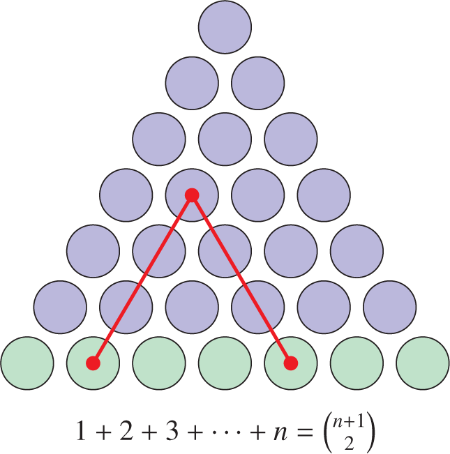

我用几句话解释一下证明吗？三角形排列的蓝色圆圈顶部有一个，然后是两个，再三个，依此类推，使得1 + 2 + ... + *n*个蓝色圆圈，分布*在n*行中。关键是每个蓝色圆圈由两个绿色圆圈中的选择决定，反之亦然，方向如红色所示的斜向。啊哈！由此可见，蓝色圆圈的数量等于选择两个绿色圆圈的次数，从而确定了所需的同一性。

Shall I explain the proof with a few words? The triangular arrangement of blue circles has one at the very top, and then two, and then three, and so on, making 1 + 2 + ⋯ + *n* many blue circles in *n* rows. The key thing to notice is that every blue circle is determined by a choice of two green circles, and vice versa, in the diagonal manner indicated in red. Aha! It follows that the number of blue circles is equal to the number of ways of choosing two green circles, which therefore establishes the desired identity.

在我看来——尽管这种证明体裁被称为证明——几乎所有所谓的无词证明，都会被几个精心挑选的词语所提升。我认为在没有解释的情况下提供真正的证明是一种虚假的美德;我知道很多情况下，原本打算用无言的证明根本没被理解。因此，在这种情况下，我倾向于将这些所谓的无词证明视为解释不清的证明。在校样中使用富有启发性的图形，当然，也要用文字。

To my way of thinking—and despite the name of this proof genre—almost every so-called proof without words is improved by a few well chosen words. I find it a false virtue to offer a proof truly without explanation; I know of many cases where an intended proof-without-words was simply not understood. In such cases, therefore, I tend to regard these so-called proofs-without-words instead merely as poorly explained proofs. Use illuminating figures in your proofs, yes, but also words.

### **如何与人说谎** **How to lie with figures**

当然，人们必须警惕人物，因为它们很容易让人误入歧途。请考虑这张图，作为证明

Of course, one must be on guard with figures, since they can easily lead one astray. Consider this diagram, offered as proof that

[figure not shown]

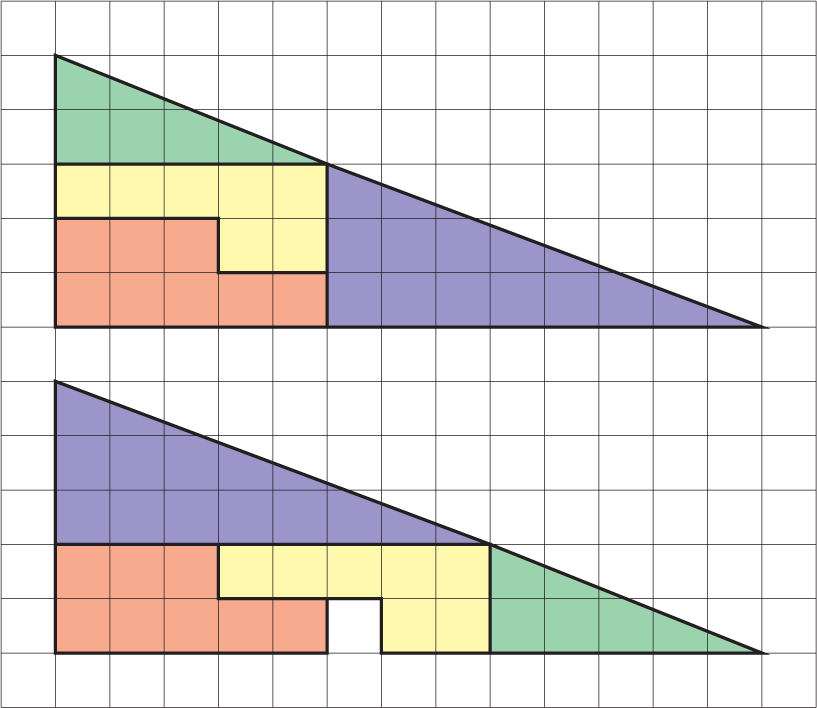

这两种彩色瓦片排列可以通过重新排列瓦片来转换，因为两张图中的瓦片形状和尺寸完全相同。在上图中，这些瓷砖似乎填满了一个以13为底、高度为5的三角形，面积为32.5;但在下方的那块，缺少一个方格，所以彩色区域少了一个。这个论点正确吗？读者会在第5.3题中批评它。

The two colored-tile arrangements can be transformed into one another by rearranging the tiles, which each have exactly the same respective shapes and dimensions in both images. In the upper image, the tiles appear to fill out a triangle with base 13 and height 5, having area 32.5; but in the lower one, there is a missing square, so the colored area is one less. Is this argument correct? The reader will criticize it in question 5.3.

### **硬性论点与软性论点** **Hard arguments versus soft**

难论证是指技术上很难的论证;也许需要繁琐的建造或复杂的计算;也许它需要将各种不同的细节恰到好处地组合在一起，才能取得成功;或者，它可能涉及证明关于相对抽象构造的各种具体事实，或许是关联不同抽象层次的相关性。对于硬有力的论证，必须密切关注。相比之下，软性论证只诉诸情境的非常普遍的抽象特征，几乎不需要构造或计算任何东西。这些通常是我最喜欢的证明。

A hard argument is one that is technically difficult; perhaps it involves a laborious construction or a difficult calculation; perhaps it involves bringing disparate fine details together in just the right combination in order to succeed; or perhaps it involves proving various specific facts about a comparatively abstract construction, perhaps relating disparate levels of abstraction. With a hard argument, one must pay close attention. A soft argument, in contrast, is one that appeals only to very general abstract features of the situation, and one needs hardly to construct or compute anything at all. These are often my favorite proofs.

当一个定理有多个证明时，通常可以观察到某种守恒原则，即难度守恒。定理的一个证明可能看起来比另一个更难的论证更为宽松，但经过反思，人们会发现软证明使用的是一个背景理论或定理，而这些理论本身的发展本身也很难，且往往以同样的方式进行。因此，存在难度守恒;无论如何，艰难的工作都得做。但当然，这个守恒原则只是一个常见现象，并非真正的普遍原则。数学史上充满了数学家找到真正更容易证明的案例，这成为该定理的新难度标准。

When a theorem has multiple proofs, one can often observe a certain conservation principle, the conservation of difficulty. One proof of the theorem may seem softer than another more difficult argument, but upon reflection, one realizes that the soft proof uses a background theory or theorem, whose development is itself difficult, often in just the same way. Thus, there is a conservation of difficulty; one needs to do the hard work one way or another. But of course, this conservation principle is merely a commonly observed phenomenon, not actually a universal principle. The history of mathematics is full of cases where a mathematician has found a genuinely easier proof, which then becomes the new standard of difficulty for that theorem.

萨哈龙·谢拉从未在面对数学难题时退缩，他指出许多数学明珠的来源正是这些难题：

Saharon Shelah, not known ever to shrink in the face of a mathematical difficulty, identifies in those difficulties the source of many mathematical pearls:

还有人怀念那些“美好旧时光”，那时校样多是想法，技术性不那么高。总体来说，我不太喜欢那些“美好旧时光”，那时牙齿不需要局部麻醉，而“技术”这个词对我来说是个警示信号，因为它很多时候不是用来指例行的实施想法，而是指那些难以理解且包含主要新颖之处的零件、想法。

Still others mourn the loss of the “good old days” when the proofs were with ideas and were not so technical. In general, I am not a great fan of the “good old days” when they treated your teeth with no local anesthesia, and the term technical is a red flag for me, as it is many times used not for the routine business of implementing ideas but for the parts, ideas and all, which are just hard to understand and many times contain the main novelties.

我觉得，虽然夸张了，但美是永恒的，而哲学价值则追随时尚。

My feeling, in an overstated form, is that beauty is for eternity, while philosophical value follows fashion.

......至于美，我指的是定义、定理和证明在和谐中发挥作用的结构中的美;但复杂的证明对我来说并不困扰。......

…As for beauty, I mean the beauty in a structure in which definitions, theorems and proofs have their part in the harmony; but complicated proofs do not bother me.…

厌恶的读者可能会喊道：“美？你在你的混乱中找到了一丝美感？”我只能说我能听到那些球体的音乐，或者每个人都喜欢自己的泥土（差别很小）。（谢拉，1993年，A轴）

A disgusted reader may shout: “Beauty? You find in your mess some trace of beauty?” I can only say that I hear the music of those spheres or that every one likes his own dirt (the difference is small). (Shelah, 1993, Axis A)

### **道德数学真理** **Moral mathematical truth**

数学家有时会说某个数学命题是“道德上”真实的，或者数学证明是“道德上正确的”。例如，刚刚快速搜索了一下，MathOverflow上有431个该语言实例。这是什么意思？其实，这和道德哲学或善良观念关系不大。相反，当数学家说X在*道德上*为真时，他们的意思大致是：“X几乎是一个重要且数学上解释性的普遍真理，除非有一些技术性反例，这些反例可能因特殊情况而出现，这些反例可以被解释或纳入”;或者，“X作为隐喻是真实的，不是字面意义上的，而是深刻地揭示了数学洞见。”当X在道德上为真时，虽然严格来说它不必字面上为真，但它（或非常相似的事物）在重要相关情形下仍为真，此外，认识这些实例对数学理解也很重要。

Mathematicians sometimes speak of a mathematical statement being “morally” true, or a mathematical proof being “morally correct.” A quick search just now revealed 431 instances of this language on MathOverflow, for example. What is meant? Well, it has very little to do with moral philosophy or notions of goodness. Rather, when a mathematician states that X is *morally* true, what they mean is something like, “X is an important and mathematically explanatory universal truth, nearly, except for some technical counterexamples that might arise from extenuating circumstances, which can be explained away or incorporated”; or, “X is true as a metaphor, not literally, but in a deep way that reveals mathematical insight.” When X is morally true, then although it need not be literally true, strictly, nevertheless it (or something very like it) is true in the important relevant cases and furthermore, realizing these instances is important for mathematical understanding.

举一个初级例子，考虑有理数上的*n*次多项式有*n*根。这在实数上不成立，因为 *x*<sup>3</sup> − *x* + 1 只有一个实数根，因此应当在复数或代数闭域上工作;即便如此，这也不完全成立，因为即使在复数中，（*x* − 1）<sup>³</sup> 也只有一个根。但许多数学家会说，*n*次多项式有*n*个根是道德*上的*正确，因为在一般情况下，根不会重复，此外，如果引入根的*重数*概念，其中根在更高次数的分解中出现时会被计数多次， 那么这个陈述就成真了。当然，还有许多更复杂的例子。

For an elementary example, consider the assertion that an *n*th degree polynomial over the rational numbers has *n* roots. This is not true over the real numbers, since *x*<sup>3</sup> − *x* + 1 has only one real number root, and so one should be working over the complex numbers or an algebraically closed field; and even then, it is not strictly true, since (*x* − 1)<sup>3</sup> has only one root even in the complex numbers. But many mathematicians would say that it is *morally* true that an *n*th degree polynomial has *n* roots, since in the generic case, roots are not repeated, and furthermore, if one introduces the concept of *multiplicity* for roots, where roots are counted more than once when they appear in the factorization with a higher degree, then the statement becomes true. And there are, of course, many more sophisticated examples.

但为什么要用道德词汇？Eugenia Cheng（2004）这样解释：

But why the moral vocabulary? Eugenia Cheng (2004) explains it like this:

数学理论很少能在真理层面上竞争。我们不会坐在那里争论哪个理论对哪个错。理论在另一个层面上竞争，涉及理论“应该”是什么样子，“正确”的做法是什么。这就是我们称之为道德的另一层“应当”。那么，什么是道德？什么算是某件事为真的一个道德理由？它除了“一个不够严谨、无法算作证明的论证”之外，还有别的含义吗？它真的在数学中扮演有意义的角色吗？......道德关乎一个人应该如何行为，而不仅仅是知道这是对的，这错的。数学道德关乎数学应如何行为，而不仅仅是这是否正确。数学家确实用“道德”这个词来形容这个观点。（第7–8页）

Mathematical theories rarely compete at the level of truth. We don’t sit around arguing about which theory is right and which is wrong. Theories compete at some other level, with questions about what the theory “ought” to look like, what the “right” way of doing it is. It’s this other level of “ought” that we call morality. So what is morality? What counts as a moral reason for something to be true? Does it mean anything other than “an argument that isn’t rigorous enough to count as a proof”? And does it really play a meaningful role in mathematics? …Morality is about how one should behave, not just knowing that this is right, this is wrong. Mathematical morality is about how mathematics should behave, not just that this is right, this is wrong. Mathematicians do use the word “morally” for this idea. (pp. 7–8)

她区分了道德数学真理与优雅，说：

She distinguishes moral mathematical truth from elegance, saying that,

优雅的证明往往是一个巧妙的把戏，一种魔法......当你试图理解某件事时，这种证明会让你抓狂，因为它太巧妙以至于根本无法解释任何东西。（第13页）

An elegant proof is often a clever trick, a piece of magic…, the sort of proof that drives you mad when you’re trying to understand something precisely because it’s so clever that it doesn’t explain anything at all. (p. 13)

她将其与建构性证明、解释性证明以及其他许多类型的证明区分开来。然而，尽管她说这个词在数学家中被广泛使用，但最终她并没有对该术语做出积极且完整的解释。这意味着什么？

And she distinguishes it from constructive proof and from explanatory proof, and from a host of other kinds of proof as well. Ultimately, however, she offers no positive full account of the term, even though she is quite right that this word is widely used by mathematicians. What does it mean?

我是数学道德家。我更关心道德真理，而非可证实的真理。但我依然是一个守法的数学家。我咬紧牙关，勉强写出证明，尽管我已经知道结果是真的，写完证明后也不会更相信它真实。要是我能找到一个数学体系，让道德真理和可证真理永远等价就好了。那样我就再也不用证明什么了。（第17–18页）

I am a mathematical moralist. I am more interested in moral truth than provable truth. But nevertheless I am a law-abiding mathematician. I grit my teeth and grudgingly chug through writing a proof even though I already know the result is true, and will not be any more convinced of its truth when I’ve written the proof. If only I could find a mathematical system in which moral truth and provable truth were always equivalent. Then I’d never have to prove anything again. (p. 17–18)

让我试着介绍一下数学中道德语言的使用情况。在我看来，一位数学家说X在道德上是真实的，意味着X蕴含了一个伟大的真理——一个对数学洞察和进步至关重要的根本真理——即使这个真理可能难以准确捕捉;在边缘情况下可能会模糊。这是许多道德主张共有的真理地位。他们并不是要断言X的真理是一个绝对被证实的字面事实，是一个推导出来的普遍真理。陈述X可能略显非正式，或者如果明确表述，并非如此理解;X的精确版本不可避免地会允许技术上承认违规的特殊情节。在声称自己拥有道德正确证明的观点中，存在一种“应当”的感觉——这是正确的证明，应该通过使用和表达深刻的数学洞见来支持该定理，并将其作为论证的指导思想。这种“道德正确”的用法往往表达了对数学推理质量的价值判断。可以想象，组合论者可能认为计数论证在道德上是正确的，而范畴论者则可能认为论证在识别并使用图示性普遍性质时是道德正确的。

Let me try to give an account of the use of moral language in mathematics. As I see it, a mathematician says that statement X is morally true to mean that X encapsulates a great truth—a fundamental truth important for mathematical insight and progress—even if it may be one that is difficult to capture exactly; it may be fuzzy in the edge cases. This is a status of truth shared by many moral claims. They do not mean to assert that the truth of X is an absolutely proven literal fact, a derived universal truth. The statement X may be slightly informal or, if stated precisely, is not meant to be taken that way; precise versions of X will inevitably allow extenuating circumstances that technically admit violations. In the claim that one has the morally correct proof, there is a sense of “ought”—it is the right proof, the one that ought to work for that theorem, by using and expressing a profound mathematical insight, following it as a guiding idea through the argument. This kind of use of “morally correct” often thereby expresses value judgements about the quality of mathematical reasoning. One can imagine that combinatorialists might find counting arguments morally correct, while category theorists might find arguments morally correct when they identify and use a diagrammatic universal property.

在另一条连接道德与数学的研究线中，贾斯汀·克拉克-多恩（2020）探讨了道德与数学之间令人毛骨悚然的平行关系。在许多令人惊讶的哲学领域，这两个主题面临着共同的问题以及类似的解决方案和反驳，无论是现实主义、先验正当性、客观性、自然主义还是多元主义。克拉克-多恩探讨了什么是真正普遍的，什么是不常见的。

In a separate research line connecting morality and mathematics, Justin Clarke-Doane (2020) explores the uncanny parallelism of morality and mathematics. On a surprising number of philosophical fronts, the two subjects face common problems and analogous solutions and rebuttals, whether the issue is realism, a priori justification, objectivity, naturalism, or pluralism. Clarke-Doane looks into what is truly common and what is not.

## **5.3 形式证明与证明理论** **5.3 Formal proof and proof theory**

那么，什么是证据？真正有力的答案来自数理逻辑学家在证明论领域提出*的形式证明*概念。让我们在本章剩余部分专注于形式证明。形式证明是严谨且精确的，采用形式语言书写，并遵循关于允许公理和推理规则的严格规则。

So, what is proof? A truly robust answer arises with the concept of *formal proof* provided by mathematical logicians in the subject of proof theory. Let us concentrate on formal proof for the rest of this chapter. Formal proof is exacting and precise, written in a formal language and according to rigid rules concerning the allowed axioms and rules of inference.

也就是说，在给定形式证明系统中，从理论*T*中*φ*断言的*证明*，是形式语言中一系列或有序的断言系统，每个断言要么是逻辑公理，要么是*T*的公理，要么是通过允许的推理规则从证明中早期断言推导出来的，其中最终断言*φ*， 正在证明的定理。当有这样的证明*φ*时，我们写作 *T* *⊢ φ*，发音为“*T* 证明*φ*”。

Namely, a *proof* of an assertion *φ* from a theory *T* in a given formal proof system is a sequence or ordered system of assertions in the formal language, each of which is either a logical axiom, an axiom of *T*, or deducible from earlier assertions in the proof by an allowed rule of inference, and where the final assertion is *φ*, the theorem being proved. When there is such a proof of *φ*, we write *T* ⊢ *φ*, pronounced “*T* proves *φ*.”

要指定这种形式证明系统，需要指定形式语言、系统的逻辑公理和推理规则。例如，逻辑公理可能包括所有具有命题重言式形式的断言，以及涉及量词和等号的公理。推理规则可能包括诸如*modus ponens*等规则，即断言：从*φ*和*φ**→ψ*，推导出*ψ*。此类规则通常通过将前提与结论分隔的线表示，如下所示：

To specify such a kind of formal proof system, one needs to specify the formal language, the logical axioms of the system and the rules of inference. The logical axioms, for example, might include all assertions having the form of a propositional tautology, as well as axioms dealing with quantifiers and equality. Rules of inference may include such rules as *modus ponens*, which asserts: from *φ* and *φ* → *ψ*, deduce *ψ*. Such a rule is usually indicated by a line separating the premises and the conclusion, like this:

[figure not shown]

另一个规则可能是*析取三段论*，它断言：从*φ*∨*ψ*和¬*φ*，推导出*ψ*：

Another rule might be *disjunctive syllogism*, which asserts: from *φ* ∨ *ψ* and ¬*φ*, deduce *ψ*:

[figure not shown]

有些证明系统有许多公理但只有少数演绎规则，而另一些系统则只有少量或没有公理，但有大量演绎规则。

Some proof systems have many axioms and just a few deduction rules, and other systems have few or no axioms and a lot of deduction rules.

在某些系统中，证明按线性顺序排列，但在其他证明系统中，通常将证明组织成树状结构，突出证明中使用的特定推理规则。形式证明系统种类繁多。在学习证明论时，通常会介绍和分析一个特定的证明系统。但在这一章中，我宁愿稍作退后，一般性地讨论这些问题。我想讨论形式证明系统中可能期望的特征，而不介绍具体系统。

In some systems, proofs are arranged linearly in a sequence, but in other proof systems, the convention is to organize the proof in the form of a tree, highlighting the particular deduction rules that were used in the proof. There are a wide variety of formal proof systems. When studying proof theory, one would typically introduce and analyze a specific proof system. But in this chapter, let me rather stand back a bit and discuss matters generally. I would like to discuss the features that one might desire in a formal proof system, without introducing a specific system.

### **健全性** **Soundness**

我们当然希望我们的证明概念能够保持真理，以证明逻辑的后果。也就是说，如果我们能从理论*T*证明*φ*，那么只要*T*为真，*φ*都成立。换句话说，我们想要

We surely want our concept of proof to be truth-preserving in order to certify logical consequence. That is, if we can prove *φ* from a theory *T*, then we want it to be the case that *φ* is true whenever *T* is true. In other words, we want

[figure not shown]

这称为*健全性*。符号*T* ⊨ *φ*，发音为“*T* 逻辑上蕴含*φ*”，意味着在满足 *T* 的每个模型中*φ*都为真。如果每当*T*证明某断言*φ*时，证明系统就是健全的，那么*φ*确实是*T*的逻辑推论;在所有*T*模型中都成立。要证明一个证明系统是可靠的，只需观察逻辑公理都是有效的——它们在所有模型中都成立——且推理规则本身具有保持真理的。由此，通过对证明长度的归纳法，整个证明系统将是健全的。

This is called *soundness*. The notation *T* ⊨ *φ*, pronounced “*T* logically implies *φ*,” means that *φ* is true in every model satisfying *T*. A proof system is sound if whenever *T* proves an assertion *φ*, then *φ* is indeed a logical consequence of *T*; it is true in every model of *T*. To establish that a proof system is sound, it suffices to observe that the logical axioms are all valid—they are true in every model—and that the rules of inference are themselves truth-preserving. It follows from this by induction on the length of the proof that the entire proof system will be sound.

请注意，这里我们讨论的是*理论与元理论*的区分。即在客论中，我们使用理论*T*;我们假设T的公*理和理*性都存在于*由T*描述的世界，即T断*言为真的*世界。相比之下，在元理论中，我们提到*理论T*;我们推理哪些断言能在*T*中被证明或无法证明，或关于*各种*T模型的本质。由于理论与元理论的相互作用，数理逻辑的学科也被称为*元数学*。

Notice that we are engaged here with the *theory-metatheory* distinction. Namely, in the object theory, we use the theory *T*; we assume the axioms of *T* and reason in the world described by *T*, the world in which the assertions of *T* are true. In the metatheory, in contrast, we mention the theory *T*; we reason about the assertions that can or cannot be proved in *T* or about the nature of the various models of *T*. Because of this theory-metatheory interaction, the subject of mathematical logic is also known as *metamathematics*.

### **完备性** **Completeness**

相反，我们可能希望证明系统足够强大，能够证明所有有效的推理。也就是说，我们可能希望如果 *φ* 在 *T* 的每个模型中都为真，那么实际上存在从 *T* 显式证明 *φ*。具有此性质的证明系统称为*完备*的。

Conversely, we might want our proof system to be strong enough to prove all the valid inferences. That is, we might hope for the property that if *φ* is true in every model of *T*, then in fact there is an explicit proof of *φ* from *T*. A proof system with this property is said to be *complete*.

[figure not shown]

但这是合理的要求吗？毕竟，有效性是一个涵盖所有理论模型的普遍属性，包括不可数的庞大且难以想象的基数模型，以及所有可能的解释，是一个巨大的可能性领域。相比之下，可证性是一种有限主义的句法概念，涉及形式系统的有限组合细节。为什么我们要指望找到一个命题的证明，一个有限的有效性证明，仅仅因为该命题在所有模型中都为真？这听起来可能太过分了。一个理论的每一个数学推论都能从该理论证明吗？每一个数学真理都是有原因的吗？

But is this a reasonable requirement? After all, validity is a sweeping universal property concerning all models of a theory, including uncountable models of vast unimaginable cardinalities, with all possible interpretations, a huge realm of possibility. Provability, in contrast, is a finitistic syntactic notion engaging with the finite combinatorial details of the formal system. Why should we expect to find a proof of a statement, a finite certificate of validity, just because the statement is true in all models? It may seem too much to ask. Is every mathematical consequence of a theory provable from that theory? Is every mathematical truth true for a reason?

我对我们竟然能设计出相对简单的可靠和完全证明系统感到惊讶。这些系统架起了句法与语义、证明与真理之间的鸿沟。在这样的系统中，当一个命题在所有模型中都为真时，才是可精确证明的：

I am astounded by the fact that indeed we are able to design comparatively simple sound and complete proof systems. These systems bridge the canyon between syntax and semantics, between proof and truth. In such a system, a statement is provable exactly when it is true in all models:

[figure not shown]

因此，有了健全且完整的证明系统，确实不存在偶然真理;在理论*T*的所有模型中，所有为真的命题实际上都可以由该理论证明;这个领域的每一个普遍真理都是有原因的，有证明，是我们能表达的有限理由。

Thus, with a sound and complete proof system, there are indeed no accidental truths; every statement that is true in all models of a theory *T* is actually provable from the theory; every universal truth in this realm is true for a reason, a proof, a finite reason that we can express.

### **紧致性** **Compactness**

让我强调证明系统完备性的一个关键后果，特别是证明有限性的后果。也就是说，如果一个陈述*φ*是理论*T*的逻辑推论，那么完备性上*存在T的**φ*证明。由于该证明是有限的，它只使用*有限*个T的公理，且由于是证明，这个理论的有限片段已经足以逻辑上推导出*φ*。这种有限性质被称为*紧性定理*。

Let me highlight a key consequence of completeness for a proof system, a consequence specifically of the finiteness of proofs. Namely, if a statement *φ* is a logical consequence of a theory *T*, then by completeness, there is a proof of *φ* from *T*. Since this proof is finite, it uses only finitely many axioms of *T*, and because it is a proof, this finite fragment of the theory is already sufficient to logically imply *φ*. This finiteness property is known as the *compactness theorem*.

**Theorem 9 (Compactness theorem).** *If T* ⊨ *φ, then there are finitely many assertions ψ*<sub>0</sub>*, …, ψ*<sub>*n*</sub> *in T such that ψ*<sub>0</sub>*, …, ψ*<sub>*n*</sub> ⊨ *φ*.

等价地，当理论的每一个有限子集都是可满足的，即该理论是可满足的。

It follows, equivalently, that a theory is satisfiable exactly when every finite subset of the theory is satisfiable.

我想强调，紧致性定理纯粹是语义论断，完全没有提及任何证明系统;它用⊨表达，即语义有效性概念，而非⊢语法可证性概念。紧致性定理将证明有限性的语义本质提炼为纯模型论性质，在模型论中具有无可估量的根本性质，被用于成千上万的论证中。尽管哥德尔最初以我们刚才描述的方式证明了紧性定理，但由于他的完备性定理和证明的有限性，但现在数理逻辑学家和模型论家更常见地舍弃证明论，直接证明紧致性定理。例如，传统的亨金完备性定理证明更容易直接证明紧致性定理：给定一个有限可满足的理论，将其推广为完备的有限可满足亨金理论，每个此类理论都有由亨金常数构建的模型。人们只需用有限可满足性（finite-satisfis）替代常见的亨金完备性证明中的一致性思想，后者是一致性的语义类比。

I should like to emphasize that the compactness theorem is a purely semantic claim, making no mention at all of any proof system; it is expressed with ⊨ , the semantic validity notion, rather than ⊢, the syntactic provability notion. The compactness theorem distills the semantic essence of the finiteness of proofs into a purely model-theoretic property, of inestimable fundamental importance in model theory, used in thousands of arguments. Although Gödel had originally proved the compactness theorem in the way we just described, as a consequence of his completeness theorem and the finiteness of proofs, it is far more common now for mathematical logicians and model theorists to dispense with the proof theory and prove the compactness theorem directly. The traditional Henkin proof of the completeness theorem, for example, works even more easily to prove the compactness theorem directly: given a finitely satisfiable theory, one extends it to a complete finitely satisfiable Henkin theory, and every such theory has a model built from the Henkin constants. One simply replaces consistency ideas in the usual Henkin completeness proof with finite-satisfiability, which is the semantic analogue of consistency.

### **可验证性** **Verifiability**

我们证明系统中最想要的第三个关键特征是*可验证*性。我们希望眼前的证据是否是证明，是清晰且确定的。对于给定的证明候选人，是否真的是证明的问题，原则上应该可以通过机械的计算程序来验证。因此，证明系统与可计算性概念相关，后者将在下一章讨论。

A third key feature we want in our proof systems is *verifiability*. We want it to be clear and determinate whether what is in front of us is a proof or not. For a given proof candidate, the question of whether it is actually a proof or not should be something that can in principle be checked by a rote computational procedure. Because of this, proof systems are related to the concept of computability, discussed in the next chapter.

奇怪的是，在证明论的讨论中，可验证性往往被忽略。人们可能会发现对其健全性和完整性的广泛讨论，却几乎没有关于可验证性的提及。然而，读者可以确定，即使在这些情况下，也有隐含的坚持认为证明系统应当是可验证的。毕竟，定义证明系统的普通方法是明确列出公理和演绎规则，如果你能识别系统中的公理和推理规则实例，那么你只需检查每一步就能验证证明。因此，大多数提出的证明系统确实是可验证的。

Strangely, verifiability often goes unmentioned in discussions of proof theory. One might find extensive talk of soundness and completeness, with nary a peep about verifiability. Yet the reader can be sure that even in such cases, there is an implicit insistence that proof systems should be verifiable. The ordinary way to define a proof system, after all, is explicitly to list the axioms and deduction rules, and if you are able to recognize the axioms and instances of the deduction rules in a system, then you can verify proofs simply by checking each step. For this reason, most proof systems that are proposed are indeed verifiable.

然而，人们很容易想象一些可能无法验证的奇异系统。例如，或许系统的公理或规则仅仅是可计算枚举的，但不可计算判定;在这样的系统中，我们可以计算证明某些正的实例，但我们不一定能证明某事不是证明，因为我们可能无法确定某个公理最终不会被允许。另一个例子是人们谈论“在二阶逻辑”中证明断言的情况。然而，二阶逻辑没有可验证且完整的证明系统，因为我们可以证明不可能通过任何可计算的程序枚举算术的二阶有效性。然而，对于二阶逻辑，存在一些健全且完全且不可验证的证明系统，这些系统在语义上定义，就像接下来考虑的系统之一一样。哲学家有时还会为二阶逻辑提供各种可靠且可验证但不完整的证明系统。

Nevertheless, one can easily imagine strange systems that might not be verifiable. For example, perhaps the axioms or rules of a system are merely computably enumerable but not computably decidable; in such a system, we could computably certify positive instances of proofs, but we would not necessarily be able to certify that something was not a proof, since we might not be able to know for sure that a certain axiom would not eventually be allowed. Another example would be cases where people speak of proving an assertion “in second-order logic.” There is no verifiable sound and complete proof system for second-order logic, however, since we can prove that it is impossible to enumerate the second-order validities of arithmetic by any computable procedure. Yet, there are sound and complete unverifiable proof systems for second-order logic, defined semantically as in one of the systems considered next. Philosophers also sometimes provide various proof systems for second-order logic that are sound and verifiable, but not complete.

### **合理且可验证，但不完整** **Sound and verifiable, yet incomplete**

为了强调拥有这三种性质的重要性，让我们看看如何轻松设计出具有两种但非全部三种性质的证明系统。这些系统在每种情况下要么简单，要么无用，这也凸显了我们确实想要这三种属性的观点。

To emphasize the importance of having all three of these properties, let us see how one may easily design proof systems that have two but not all three of the properties. These systems are in each case either trivial or useless, which serves to underline the point that we do want all three properties.

首先，我们提供一个既合理且可验证但不完整的简单证明系统。为此，只需考虑空证明系统，即没有逻辑公理和推理规则的系统。从给定的命题*φ*，在这个系统中你只能推导出*φ*本身。这无疑是合理的，也可验证，但显然不完整。这种证明系统显然无法完全体现逻辑效度的全部。

To begin, let us provide a trivial proof system that is both sound and verifiable but not complete. For this, simply consider the empty proof system, the system with no logical axioms and no rules of inference. From a given statement *φ*, in this system you can deduce only *φ* itself. This is certainly sound, and also verifiable, but it is clearly incomplete. This proof system obviously does not capture the full extent of logical validity.

### **完整且可验证，却不够可靠** **Complete and verifiable, yet unsound**

接下来，我们提供另一个平凡的证明系统，它是完备且可验证的，但不够可靠。考虑这样一个系统，其中每个命题都被允许作为逻辑公理，并且从任何前提中允许所有可能的结论作为推理规则。该系统显然是完备的，因为每当Γ逻辑上能蕴含*φ*时，那么*φ*确实可以从系统中的Γ推导出，因为实际上每个*φ*都可以从无中推导出。该系统也是可验证的。但这显然是不合理的——荒谬地荒谬——因为在这个系统中，绝对所有命题都可以被证明，包括无效的命题。

Next, let us provide another trivial proof system, which is complete and verifiable but not sound. Consider the system in which every statement is allowed as a logical axiom, and every possible conclusion is allowed from any premise as a rule of inference. This system is clearly complete, since whenever Γ logically implies *φ*, then indeed *φ* is deducible from Γ in the system, since in fact every *φ* is deducible from nothing. The system is also verifiable. But it is clearly unsound—absurdly so—since absolutely every statement is provable in this system, including invalid statements.

### **既合理又完整，却无法证实** **Sound and complete, yet unverifiable**

现在我们给出一个一阶证明系统，它既可靠且完整，但不可验证。这或许是这些例子中最有趣的，因为它表明证明系统中，健全性和完整性并非全部。这种特定的证明系统虽然可靠且完整，但由于无法验证，因此无用。

Let us now provide a first-order proof system that is sound and complete but not verifiable. This is perhaps the most interesting of these examples, for it shows that soundness and completeness are not the whole story in a proof system. This particular proof system, although sound and complete, is useless because it is not verifiable.

为了定义该系统，我们将所有有效性，即所有模型中为真的所有陈述作为逻辑公理;我们以 *modus ponens* 作为唯一的推理规则：从*φ*和*φ*→*ψ*推导出*ψ*。这些公理和规则显然是合理的。系统也已完整。为了证明这一点，假设 *T* ⊨ *ψ*。根据紧致性定理，存在有限个断言 *φ*<sub>0</sub>*， ...， φ*<sub>*n*</sub> 在 *T* 中逻辑上推导出 *ψ*。由此得出

To define the system, let us take as our logical axioms all validities, that is, all statements true in all models; and let us have *modus ponens* as the only rule of inference: from *φ* and *φ* → *ψ*, deduce *ψ*. These axioms and rules are clearly sound. The system is also complete. To see this, suppose that *T* ⊨ *ψ*. By the compactness theorem, it follows that there are finitely many assertions *φ*<sub>0</sub>*, …, φ*<sub>*n*</sub> in *T* that logically imply *ψ*. It follows that

[figure not shown]

是一个逻辑有效性。该断言在逻辑上等价于

is a logical validity. This assertion is logically equivalent to

[figure not shown]

通过对该公理施加的推理模，利用每个 <sub>*φ i*</sub> 都属于理论 *T* 的事实，我们得出 *T* *⊢ψ*该证明系统中的 T，正如所愿。

By modus ponens applied successively to this axiom, using the fact that each *φ*<sub>*i*</sub> is in the theory *T*, we conclude that *T* ⊢ *ψ* in this proof system, as desired.

在他的通俗逻辑讲义中，阿诺德·米勒介绍了该系统的一个版本，他称之为*MM证明系统*（“米老鼠”证明系统）。这个系统到底出了什么问题？米勒写道：

In his popular logic lecture notes, Arnold Miller introduced a version of this system, which he called the *MM proof system* (the “Mickey Mouse” proof system). What is wrong with this system? Miller writes:

可怜的《绿野仙踪》系统去找《绿野仙踪》说：“我想更像其他所有的证明系统。”巫师回答：“你几乎拥有任何其他证明系统拥有的一切，甚至更多。完备性定理在你的系统中很容易证明。你几乎没有逻辑规则和逻辑公理。你只差一样东西。凡人很难在你系统中看到证明并判断它是否真的是证明。难点在于把所有逻辑有效性都当作逻辑公理。”向导随后给MM提供了一个递归的逻辑有效性子集Val，并且具有仅用Val中的Modus Ponens可以证明每个逻辑有效性的性质。”（米勒，1995，第57页）

The poor MM system went to the Wizard of Oz and said, “I want to be more like all the other proof systems,” and the Wizard replied, “You’ve got just about everything any other proof system has and more. The completeness theorem is easy to prove in your system. You have very few logical rules and logical axioms. You lack only one thing. It is too hard for mere mortals to gaze at a proof in your system and tell whether it really is a proof. The difficulty comes from taking all logical validities as your logical axioms.” The Wizard went on to give MM a subset Val of logical validities that is recursive and has the property that every logical validity can be proved using only Modus Ponens from Val.” (Miller, 1995, p. 57)

随后，米勒通过一系列练习概述了如何构造Val集合，Val是一个可判定的有效性集合，所有其他有效性都可以由此证明。由此产生的证明系统变得健全、完整且可验证。

Miller then proceeds to outline in a series of exercises how one may construct the set Val, a decidable set of validities from which all other validities can be proved. The resulting proof system becomes sound, complete, and verifiable.

### **空结构** **The empty structure**

传统证明系统通常具有这样一个特性：断言∃*x x* = *x*是显式形式可证的。但我们认为这句话有效吗？数学存在能否仅凭逻辑证明？当然，在空结构中断言失败，即结构在其域中没有元素。因此，表面上∃*x x* = *x*的可证性违反了这些证明系统的合理性;这是一个可证但并非在所有结构中都为真的命题，因为它在空结构中不成立。传统上，这个问题通过从主体中排除空结构来解决，作为定义问题：定义有效*性T* ⊨ *φ*意味着*T*的每个*非空*模型都是*φ*的模型。这样，证明系统仍然可以被视为可靠。右？

Traditional proof systems often have the property that the assertion ∃*x x* = *x* is explicitly formally provable. But do we regard this statement as valid? Can mathematical existence be proved purely from logic? The assertion fails, of course, in the empty structure, the structure having no elements in its domain. On its face, therefore, the provability of ∃*x x* = *x* is a violation of the soundness of these proof systems; it is a statement that is provable but not true in every structure, for it is not true in the empty structure. This problem is addressed traditionally simply by excluding the empty structure from the subject, as a matter of definition: one defines validity *T* ⊨ *φ* to mean that every *nonempty* model of *T* is a model of *φ*. In this way, the proof systems can still be seen as sound. Right?

这样可以吗？不，至少我不认为是这样。在早期几十年，数学逻辑刚兴起时，排除空洞结构似乎是无害的。毕竟，我们从未真正对空结构感到困惑，将主语限制在非空结构类上似乎提供了某些便利，比如规范形的处理，或围绕每个模型都允许语言扩展的事实，这对空结构来说是个问题，因为大语言有常数符号。但在当代，数学家通常坚持认为设计良好的数学理论应对所有边界情况进行有力处理;事实上，当理论遇到琐碎的边缘情况，如空结构时，常被认为定义或概念存在缺陷。在当代形式证明系统中未能正确处理空结构，是“空性病”的明显例子，即我们在第一章讨论的疾病，当传统数学发展不重视空结构时，就会发生这种情况。这种疾病在数学的大部分领域已被根除，但它依然存在于证明论中。对当今许多数学家来说，提出使用一个无法正确处理空结构的证明系统是不可接受的，甚至是致命的。在我看来，旧的校准系统在这方面只是错误，现在是时候修正它们了。

Is this satisfactory? No, not really, not to my way of thinking. In earlier decades, at the dawn of mathematical logic, it may have seemed innocent to exclude the empty structure. After all, we are not ever genuinely confused about the empty structure, and restricting the subject to the class of nonempty structures might seem to offer certain conveniences, such as with the treatment of the normal forms or surrounding the fact that every model admits expansions of the language, which is problematic for the empty structure when the larger language has constant symbols. But in contemporary times, mathematicians generally insist that well designed mathematical theories treat all their boundary cases robustly; and indeed, when a theory stumbles upon a trivial edge case, such as the empty structure, it is often taken to indicate flawed definitions or concepts. The failure to treat the empty structure properly in contemporary formal proof systems is a clear instance of “emptysetitis,” the disease we discussed in chapter 1, occurring when a traditional mathematical development declines to take the empty structure seriously. This disease has been eradicated in most parts of mathematics, but it lives on in proof theory. For many mathematicians today, it is a nonstarter, a deal-breaker, to propose the use of a proof system that does not handle the empty structure properly. To my way of thinking, the older proof systems are simply mistaken on this issue, and it is past time to fix them.

幸运的是，一些现代的校样系统确实能正确处理空结构。一个重要的区别在于证明系统在语言展开时的表现，尤其是关于新的常数符号，因为虽然每个非空结构都是任何扩展语言中某结构的约简，但空结构则不然。具体来说，由于具有常数符号的语言在空结构中不允许解释，相对有效关系 T ⊨ *φ* 可以依赖于背景语言，即使 *T* 和 *φ* 只使用了部分背景语言。如果背景语言有常数符号，则该*语言中所有*T的模型均非空，但如果不是，则空结构可能相关。从这个意义上说，健全处理空结构的一部分是认识到有效性概念依赖于背景语言。在符号常数的语言中，∃*x x* = *x* 是有效的，但不然。

Thankfully, some contemporary proof systems do handle the empty structure properly. One important difference concerns how the proof system behaves upon expansions of the language, especially with regard to new constant symbols, because although every nonempty structure is the reduct of a structure in any expanded language, this is not true of the empty structure. Specifically, since a language with constant symbols admits no interpretation in the empty structure, the relative validity relation *T* ⊨ *φ* can depend on the background language, even when *T* and *φ* use only a part of it. If the background language has constant symbols, then all models of *T* in that language are nonempty, but if not, then the empty structure may be relevant. In this sense, part of treating the empty structure robustly is recognizing that one’s validity concept depends on the background language. In a language with constant symbols, ∃*x x* = *x* is valid but not otherwise.

### **形式演绎示例** **Formal deduction examples**

也许通过举一些示例推理来澄清形式证明的概念。在不完全指定证明系统的情况下，假设我们正在使用允许我接下来两个形式推理示例中使用的逻辑公理和推理规则的形式证明系统。

Perhaps it will help to clarify the concept of formal proof by giving some example deductions. Without fully specifying the proof systems, let us imagine that we are working in formal proof systems that allow the logical axioms and rules of inference that I use in the two sample formal deductions provided next.

**Theorem.** ∃*x φ*(*x*)*,* ∀*x* (*φ*(*x*) → *ψ*(*x*)) ⊢ ∃*x ψ*(*x*)

我们先给出一个传统的序列证明。这种证明系统通常有针对各种量词操作和各种恒复形式的公理，通常以推理法为唯一的推理规则：

Let us first give a traditional sequence proof. This kind of proof system typically has axioms for various quantifier manipulations and for various tautological forms, often with modus ponens as the only rule of inference:

1. ∃*x φ*，已定。
2. ∃*x φ*, given.
3. （∃*x φ*） →¬∀*x* ¬*φ*，量词公理。
4. (∃*x φ*) →¬∀*x* ¬*φ*, quantifier axiom.
5. ¬∀*x* ¬*φ，modus* ponens。
6. ¬∀*x* ¬*φ*, modus ponens.
7. 已给出∀*x*（*φ*→*ψ*）。
8. ∀*x* (*φ* → *ψ*), given.
9. ∀*x*（*（φ* → *ψ*） → （¬ *ψ* →¬*φ*）），逻辑公理（对抗）。
10. ∀*x* ((*φ* → *ψ*) → (¬*ψ* →¬*φ*)), logical axiom (contrapositive).
11. [∀*x* （*（φ* → *ψ*） → （¬*ψ* →¬*φ*））] → [∀*x* （*φ →* *ψ*） →∀*x* （¬ *ψ* →¬*φ*）]，量词公理。
12. [∀*x* ((*φ* → *ψ*) → (¬*ψ* →¬*φ*))] → [∀*x* (*φ* → *ψ*) →∀*x* (¬*ψ* →¬*φ*)], quantifier axiom.
13. ∀*x*（*φ* → *ψ*） →∀*x* （¬ *ψ* →¬*φ*），modus ponens。
14. ∀*x* (*φ* → *ψ*) →∀*x* (¬*ψ* →¬*φ*), modus ponens.
15. ∀*x*（¬*ψ* →¬*φ*），modus ponens。
16. ∀*x* (¬*ψ* →¬*φ*), modus ponens.
17. ∀*x* （¬*ψ* →¬*φ*） → （∀*x* ¬*ψ* →∀*x* ¬*φ*），量词公理。
18. ∀*x* (¬*ψ* →¬*φ*) → (∀*x* ¬*ψ* →∀*x* ¬*φ*), quantifier axiom.
19. ∀*x* ¬*ψ* →∀*x* ¬*φ，modus* ponens。
20. ∀*x* ¬*ψ* →∀*x* ¬*φ*, modus ponens.
21. [∀*x* ¬*ψ* →∀*x* ¬*φ*] → [¬∀*x* ¬*φ* →¬∀*x* ¬*ψ*]，逻辑公理。
22. [∀*x* ¬*ψ* →∀*x* ¬*φ*] → [¬∀*x* ¬*φ* →¬∀*x* ¬*ψ*], logical axiom.
23. ¬∀*x* ¬*φ* →¬*∀x* ¬*ψ，modus* ponens。
24. ¬∀*x* ¬*φ* →¬∀*x* ¬*ψ*, modus ponens.
25. ¬∀*x* ¬*ψ，modus* ponens。
26. ¬∀*x* ¬*ψ*, modus ponens.
27. ¬∀*x* ¬*ψ* →∃*x ψ*，量词公理。
28. ¬∀*x* ¬*ψ* →∃*x ψ*, quantifier axiom.
29. ∃*x ψ，modus* ponens。QED
30. ∃*x ψ*, modus ponens. QED

这里有一个自然演绎的证明。在自然演绎证明系统中，通常几乎没有或没有逻辑公理，但为引入和消除每个逻辑常数提供了演绎规则：

And here is a natural deduction proof of the same theorem. In natural deduction proof systems, there are usually few or no logical axioms, but deduction rules are provided for the introduction and elimination of each of the logical constants:

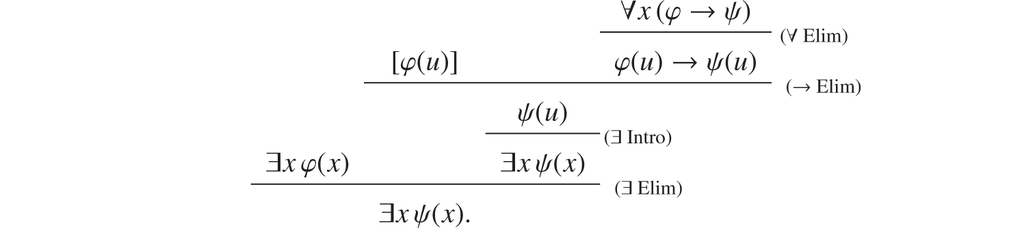

该证明在右上角使用∀消元和→消去法（modus ponens），假设*φ*（*u*），在最终∃消去时释放;我们应注意常数 *u* 不在 *φ* 或 *ψ* 中出现。

This proof uses ∀ elimination and → elimination (modus ponens) at the top right, with the assumption of *φ*(*u*), discharged in the final ∃ elimination; we should take care that the constant *u* does not appear in *φ* or *ψ*.

### **形式演绎的价值** **The value of formal deduction**

我们应如何看待这些正式的推理？一方面，形式证明通过细微、原始的推理步骤进行，这些步骤可以被精确验证，毫无疑问其正确性。这种高标准的明确逻辑严谨无疑令人信服。另一方面，我们是否因为推理而相信这个例子的逻辑有效性？不，我们在看到推理结果之前就相信了它的有效性;这种有效性是显而易见的：如果存在一个具有某种性质的对象，而该性质必然蕴含另一个性质，那么就存在一个具有第二个性质的对象：正是同一个对象。这种有效性不需要形式上的详细阐述，当然，形式证明并不比我刚才给出的非正式初等解释更有说服力。

How shall we view such formal deductions? On the one hand, formal proofs proceed via minute, primitive steps of reasoning that can be precisely verified, leaving no doubt about their correctness. This high standard of explicit logical rigor is certainly convincing. On the other hand, do we believe the logical validity of this example because of the deductions? No, we believed the validity before seeing the deductions; this validity is trivial: if there is an object with a certain property, and this property necessarily implies another property, then there is an object with this second property: the very same object. This validity requires no formal elaboration, and certainly the formal proofs are in no way more convincing than the informal elementary explanation I just gave.

这种情况是形式推理的典型特征：一个实际上可以用手工完成的形式推理，必然证明一些琐碎或本质上是基本的。结论通常更容易或更直接地被视为有效，无需繁琐的形式细节。在新设计的证明系统中工作时，我倾向于将这里给出的这种推理的存在视为证明系统本身正常工作的证据，而非证明其证明定理有效性的证据，而该定理本身是无可置疑的。演绎使我们关注逻辑推理的细节，比如量词的逻辑解释，或许伴随的假设和执行，或是分配逻辑连接词的细节。相比之下，我们数学期刊和讲堂中的证明跳过了这些琐碎之处，专注于构成我们数学理解框架的高层数学概念和思想。因此，我们通常不会直接通过形式证明学习关于客论的难忘数学思想。我们通常根本不会从形式证明中学到任何数学。比如说，我觉得有人为了探索新的数学概念而开始写下形式推理很荒谬。<sup>3</sup> 我们通过玩味和探索数学思想来学习，而不是通过在形式系统中操控这些想法的形式化。

This situation is typical of formal deductions: a formal deduction that can actually be carried out by hand is inevitably proving something trivial or essentially elementary. The conclusion can usually be seen as valid more easily, or more directly, without the cumbersome formal details. When working in a newly designed proof system, I am inclined to take the existence of a deduction of the kind given here principally as evidence that the proof system itself is working properly rather than as evidence of the validity of the theorem that it proves, which was not in doubt. Deductions focus our attention on the minutia of logical reasoning, such as the logical accounting of quantifiers perhaps with accompanying assumptions to be made and discharged or the details of distributing a logical connective. The proofs in our mathematics journals and lecture halls, in contrast, skip over those trivialities and focus our attention on the higher-level mathematical concepts and ideas that constitute the framework of our mathematical understanding. For this reason, we do not generally learn memorable mathematical ideas about the object theory from formal proofs directly. We do not usually learn any mathematics from a formal proof at all. I would find it absurd, for example, for someone to start writing down formal deductions in order to explore a new mathematical concept.<sup>3</sup> We learn by playing with and exploring mathematical ideas, not by manipulating formalizations of those ideas in a formal system.

Alexander Paseau（2016）指出，用原子化的形式版本替代证明论证可能会降低可信度，因为原始证明中可能存在的深刻思想必然与形式证明中无数平庸的原子演绎步骤混合在一起;证明的核心理念在无趣细节的海洋中被淹没了。他基于此及其他原因得出结论：“原子化本身在认识论上并不具备价值”（第204页）。

Alexander Paseau (2016) makes the point that replacing a proof argument with an atomized formal version can reduce credence because whatever insightful ideas might have existed in the original proof are of necessity mixed in with innumerable banal atomic deductive steps in the formal proof; the key idea of the proof is lost in a sea of uninteresting details. He concludes for this and other reasons that “atomization is not in itself epistemically valuable” (p. 204).

In particular, in current ordinary mathematical practice, we rarely use formal deductions to convince ourselves of the truth of a mathematical conclusion; almost never.<sup>4</sup> Rather, proof theory is a theoretical tool that logicians use to analyze the underlying interaction of language and meaning in mathematics. We study the proof system abstractly, noting features that enable us to make conclusions about what may or may not be provable in it, or about the nature of those proofs.

我发现形式证明和证明论的情境本质上类似于图灵机在可计算性理论中的应用（见第六章）。我们研究图灵机不是为了用它们进行实际计算;相反，我们研究图灵机是为了理解计算的本质，并分析其固有的能力和局限。同样，我们学习形式证明，并不是因为我们想要对数学论证进行实际的形式证明;相反，我们研究形式证明，以理解证明的本质，并分析其固有的能力和局限。

I find the situation of formal proof and proof theory to be fundamentally similar to the use of Turing machines in computability theory (see chapter 6). We do not study Turing machines in order to use them to undertake actual computation; rather, we study Turing machines in order to understand the nature of computation and analyze its inherent capabilities and limits. Similarly, we study formal proofs not because we aim to undertake actual formal proofs of our mathematical arguments; rather, we study formal proofs to understand the nature of proof and analyze its inherent capabilities and limits.

## **5.4 自动定理证明与证明验证** **5.4 Automated theorem proving and proof verification**

然而，对这一观点的有力反驳，且在相对较近的将来可能完全推翻它，那就是计算机验证证明力量的增强。这可能只是形式证明领域的一个游戏规则改变者。我们这一代人正见证自动化定理证明和证明助手的成熟，它们似乎注定要改变数学实践。未来的数学家可能会常用证明助手和自动化证明验证器，拥有庞大且不断增长的正式验证数据库来进行数学研究。人们想象一个庞大的形式数学知识库，所有知识都经过验证，旨在成为人类数学洞见的总和，以形式系统表达。这项努力的开端现在已经开始。

A strong counterpoint to this perspective, however, which furthermore in the comparatively near future may completely overturn it, arises with the increasing power of computer-verified proof. This may simply be a game-changer in the realm of formal proof. Our generation is witnessing the coming-of-age of automated theorem proving and proof assistants, which seem destined to transform mathematical practice. Mathematicians of the future may be commonly using proof assistants and automated proof verifiers, with large and growing databases of formally verified proofs, to undertake their mathematical investigations. One imagines a vast repository of formal mathematical knowledge, all with verified proofs, aspiring to be the sum total of human mathematical insight, expressed in a formal system. The beginnings of that effort are now seriously underway.

### **四色定理** **Four-color theorem**

以四色定理的历史为例，该定理最早由奥古斯都·德·摩根的学生弗朗西斯·格思里于1852年猜想。该定理断言每张地图都可以是四色的，这意味着对于你在平面上绘制的任何地图，多个国家相互接壤（受一定的自然连通性要求约束），每个国家最多只能用四种颜色上色，从而使相邻国家获得不同的颜色。

Consider as an illustration the history of the four-color theorem, first conjectured in 1852 by Francis Guthrie, a student of Augustus de Morgan. The theorem asserts that every map can be four-colored, meaning that for any map you can draw in the plane, with various countries bordering one another (subject to certain natural requirements about connectedness), the countries can each be colored, using at most four colors, in such a way that adjacent countries get different colors.

经过多次失败和阿尔弗雷德·肯普（Alfred Kempe）广受赞誉的证明（1879–1890年）后被证明错误，最终于1976年由肯尼斯·阿佩尔（Kenneth Appel）和沃尔夫冈·哈肯（Wolfgang Haken）证明，他们部分通过计算机对大量案例进行计算分析来证明该定理。将无限问题简化为有限问题本身就是一种数学成就。

After fitful false starts and a widely acclaimed proof by Alfred Kempe that had stood for over a decade (1879–1890) before it was realized to be wrong, the theorem was finally proved in 1976 by Kenneth Appel and Wolfgang Haken, who proved the theorem in part by using a computer to undertake a computational analysis of a large number of cases. Reducing the infinite problem to a finite one was itself a mathematical achievement.

Appel-Haken 证明涉及数学证明本质的若干哲学问题。由于证明的计算性质，即使是一生的日常工作，也无法手工核对证明的细节。然而，这一证明仍被数学界广泛接受为证明。这是否违反了证明应当可调查的预期？毕竟，如果无法核实或核实，证据又有什么用呢？怎么可能有说服力？我们可以检查程序是否正确（确实有人这么做过），也就是说，如果算法完全按照程序执行，并且得到正确的结果，那么定理确实是真的。在这种情况下，我们对定理的信心似乎取决于计算机是否正确地执行了该算法。由于计算机的运行是一个物理过程，会受到伽马射线和量子涨落等干扰，这似乎赋予了定理证明科学实验的性质。如果习惯于将数学证明视为纯粹先验的推理，这显得非常奇怪。四色证明是通过经验得出的数学知识实例吗？我们在这里似乎有一种后验数学推理。

The Appel-Haken proof engages with several philosophical issues concerning the nature of mathematical proof. Because of its computational nature, it was not possible for a person to check the details of the proof by hand, even in a lifetime of daily work. Yet, the proof was nevertheless widely accepted as a proof by the mathematical community. Does this violate an expectation that proofs should be surveyable? What good is a proof, after all, if you cannot verify or check it? How could it be convincing? Well, we could check that the program was correct (as indeed people did), in the sense that if the algorithm was undertaken exactly in accordance with it, with the right result, then it would indeed mean that the theorem was true. In this case, our confidence in the theorem would seem to be relying on knowing that the computer did carry out that algorithm correctly with that result. Because the operation of the computer is a physical process, subject to disturbance by gamma rays and quantum fluctuation, and so on, this would seem to give the proof of the theorem the character of a scientific experiment. This would seem very strange if one is accustomed to thinking of mathematical proof as a purely a priori deduction. Is the four-color proof an instance of mathematical knowledge arrived at empirically? We would seem here to have a posteriori mathematical reasoning.

令人惊讶的是，四色定理的历史故事超越了Appel和Haken，直到2005年Georges Gonthier提出*的形式化证明*，并可通过自动证明检查器验证其正确性。这在四色定理证明中计算机的使用方式有着根本不同的意义，因为形式证明对象在逻辑上是稳健的，能够经受详细的审查以验证其合法性。现在对四色定理的真实性毫无合理怀疑。贡蒂耶的验证赋予四色定理比目前大多数其他普遍接受的数学定理更高的确定性，因为这些定理尚未在形式证明系统中被正式证明。

Amazingly, the historical story of the four-color theorem continues beyond Appel and Haken to the 2005 development of Georges Gonthier, who was able to produce a *formal* proof of the four-color theorem, one which could be validated as correct by automated proof-checkers. This is a profoundly different kind of use of computers in the proof of the four color theorem because the formal proof object is logically robust and able to withstand detailed scrutiny as to its legitimacy. There can be no reasonable doubt now about the truth of the four-color theorem. Gonthier’s verification gives the four-color theorem a greater level of certainty than is currently enjoyed by most of the other commonly accepted theorems of mathematics, since they have not yet generally been given formal proofs in a formal proof system.

### **形式系统的选择** **Choice of formal system**

当代关于证明验证的研究部分目的是寻找合适的形式系统。20世纪初，数学家意识到集合论提供了坚实且便捷的数学基础（见第8章）;集合论似乎具备表达本质上任意数学结构的能力，从这个意义上说，任何数学论证都可以视为发生在集合论中。集合论还有一种简单、极简的语言，仅∈集合成员关系，策梅洛-弗兰克尔公理（ZFC）是一阶可表达的。因此，它被应用于多个自动校对系统中。

Contemporary work on proof verification is aimed in part at finding the right formal system for this purpose. In the early twentieth century, mathematicians realized that set theory provided a robust and convenient mathematical foundation (see chapter 8); set theory seems to offer the capacity to express essentially arbitrary mathematical structure, and in this sense, one could view any mathematical argument as taking place in set theory. Set theory also had a simple, minimalist language, with just the set membership relation ∈, and the Zermelo-Fraenkel (ZFC) axioms were first-order expressible. So it was implemented in several automated proof systems.

与此同时，一些数学家对将他们的数学思想转化为集合论的形式语言感到不满。正因为其极简性，最终的形式断言显得笨拙甚至荒谬，耗尽了数学活力，且基础并不自动支持某些数学家所期望的类型化。想象一下，你要为你的秘密午夜恋人写一首诗，但必须用摩尔斯电码，通过按顺序堆叠一堆矮或高的石头来表达。集合论问题似乎越来越与数学思想无关，因此一些数学家开始认为集合论是错误的形式基础。

Meanwhile, some mathematicians chafed at the idea of translating their mathematical ideas into the formal language of set theory. Precisely because of its minimality, the resulting formal assertions are awkward or even absurd, drained of mathematical vitality, and the foundation does not automatically accommodate typing in a way that some mathematicians desire. Imagine composing a poem to your secret midnight lover, but having to convey it in Morse code by assembling piles of rocks, either short or tall, in a sequence. The set-theoretic issues seemed increasingly irrelevant to the mathematical ideas, and so some mathematicians have come to view set theory as the wrong formal foundation.

Michael Harris（2019）解释了在不熟悉的基础上进行形式化努力时，如何显得陌生或局限性：

Michael Harris (2019) explains how formalization efforts can seem alien or limiting when undertaken with an unfamiliar foundation:

像怀尔斯发表的那样的证明，不应被视为自成一体的文物。相反，怀尔斯的证明是开放式对话的出发点，这种对话既难以捉摸又充满生命力，无法被与主题外来的基础约束所限制。

A proof like the one Wiles published is not meant to be treated as a self-contained artifact. On the contrary, Wiles’ proof is the point of departure for an open-ended dialogue that is too elusive and alive to be limited by foundational constraints that are alien to the subject matter.

我们所期望的是一个形式系统，使我们能够自然地表达数学思想，更加紧密地结合我们数学概念和实践的形式基础与架构。

What is desired is a formal system in which we can express our mathematical ideas naturally, a closer alignment of the formal foundation and the architecture of our mathematical conceptions and practice.

为解决这个问题，沃沃茨基提出了单价基础和同伦类型理论作为替代基础，明确旨在促进计算机验证证明的常规应用。该理论综合了同伦论、类型论和范畴论的思想，被提出为一种有前景的形式系统，被描述为在某些领域更接近数学实践，且易于证明形式化。

Attempting to address this, Voevodsky proposed univalent foundations and homotopy type theory as an alternative foundation explicitly aimed at facilitating the routine use of computer-verification of proofs. Synthesizing ideas of homotopy theory, type theory and category theory, this theory has been put forth as a promising formal system, one that has been described as closer in some domains to mathematical practice and amenable to proof formalization.

单价基础，类似于基于ZFC的基础，且与范畴论不同，是一个完整的基础系统，但它与ZFC有很大不同。为了提供比较的格式，我假设任何既适合人类推理又适合计算机验证的数学基础，应包含以下三个组成部分。第一个组成部分是一个形式演绎系统：一种语言及其纯形式句子操作规则，使得这些操作的记录可以被计算机程序验证。第二个组成部分是一种结构，通过人类直观理解的心理对象为该语言的句子赋予意义。第三个组成部分是一个结构，使人类能够通过与语言直接相关的对象来编码数学思想。（沃沃茨基，2014年，第9页）

Univalent foundations, like ZFC-based foundations and unlike category theory, is a complete foundational system, but it is very different from ZFC. To provide a format for comparison, let me suppose that any foundation for mathematics adequate both for human reasoning and for computer verification should have the following three components. The first component is a formal deduction system: a language and rules of manipulating sentences in this language that are purely formal, such that a record of such manipulations can be verified by a computer program. The second component is a structure that provides a meaning to the sentences of this language in terms of mental objects intuitively comprehensible to humans. The third component is a structure that enables humans to encode mathematical ideas in terms of the objects directly associated with the language. (Voevodsky, 2014, p. 9)

因此，这一新基础的重要目标之一是提供一个形式系统，同时又足够贴近数学家的思维方式，从而简化实际数学的形式化过程。支持者指出，计算实现的简便性是单价基础吸引的原因之一。

Thus, an important part of the goal of this new foundation is provide a formal system that is also close enough to the mathematician’s way of thinking that it eases the process of formalizing actual mathematics. Advocates cite the ease of computational implementation as part of the attraction of univalent foundations.

与此同时，批评者认为单价基金会被过度吹捧;许多人觉得这个新基金会令人困惑且陌生，学习曲线陡峭，远未达到自然主义的可用性目标。我怀疑任何形式系统都难以实现这一目标，因为证明验证本质上涉及数学上无趣的形式，这些形式必然与数学家关注的思想区分开来，无论使用哪种形式系统。和瑟斯顿一样，正因如此，我怀疑任何形式系统能真正接近数学家的实际思维和工作方式。因此，我认为形式验证将作为独立的专长继续存在，不同形式体系的专家们会寻求将其他数学家的工作形式化，而非像有时设想的那样，作为每位数学家的常规过程。

Meanwhile, critics say that univalent foundations are oversold; many find the new foundation simply bewildering and alien, on a steep learning curve, far from meeting the naturalist usability goal. I suspect that the goal will be elusive for any formal system, since proof verification inherently involves mathematically uninteresting formalities of syntax that will inevitably stand apart from the ideas upon which mathematicians are focused, regardless of which formal system is used. Like Thurston, for this reason, I am skeptical that any formal system can be truly close to how mathematicians actually think and work. I find it likely that formal verification therefore will continue as its own speciality, with experts in various formal systems seeking to formalize the work of other mathematicians rather than as a routine process undertaken by every mathematician, as it is sometimes envisaged.

## **5.5 完备性定理** **5.5 Completeness theorem**

让我们讨论一些用于证明给定形式证明系统完备性定理时涉及的一些思想。目标是证明一个系统是健全、完整且可验证的：

Let us discuss some of the ideas involved in proving the completeness theorem for a given formal proof system. The goal is to prove of a system that it is sound, complete, and verifiable:

[figure not shown]

首先，通常很容易证明自己的系统是合理的，即前向推论，只需观察所有逻辑公理和推理规则的有效性。通过对证明长度的归纳法，任何证明都无法做出不健全的推理。通常也很容易看出，如果使用了一份可验证的公理和推理规则列表，且这些规则在每个实例中均可验证。剩下的难点是证明完整性。那么，让我来讨论一些在证明完整性方面起作用的方法和观点。

To begin, it is generally easy to prove that one’s system is sound, the forward implication, simply by observing that all the logical axioms and rules of inference are indeed valid. It follows by induction on the length of proofs that no proof can ever make an unsound deduction. It is also generally easy to see that one’s system is verifiable if one has used a verifiable list of axioms and rules of inference that are uniformly verifiable in each instance. The difficult remaining part is to prove completeness. So let me discuss a few of the methods and ideas that play a role in proving completeness.

It is often useful to establish the *deduction theorem*, which asserts that *T* ⊢ *φ* → *ψ* if and only if *T, φ* ⊢ *ψ*. The forward implication of this equivalence, for example, is an immediate consequence if one has modus ponens as a rule of inference. The converse implication is also immediate in many natural deduction proof systems. In sequence systems, if *T, φ* ⊢ *ψ*, then there is a proof *θ*<sub>0</sub>*, …, θ*<sub>*n*</sub>. One then aims to show that *T* ⊢ *φ* → *θ*<sub>*i*</sub> for each formula *θ*<sub>*i*</sub> appearing in the proof, by considering exactly how *θ*<sub>*i*</sub> itself had arisen in the proof. One can often proceed by induction, assuming that the claim has already been established for the earlier formulas. For example, if *θ*<sub>*i*</sub> had been deduced by modus ponens, then *θ*<sub>*k*</sub> → *θ*<sub>*i*</sub> appeared earlier in the proof, and so by induction, we would have already known that *T* ⊢ *φ* → *θ*<sub>*k*</sub>, and also *T* ⊢ *φ* → (*θ*<sub>*k*</sub> → *θ*<sub>*i*</sub>). And so if one’s proof system has the resources to move tautologically from those to *T* ⊢ *φ* → *θ*<sub>*i*</sub>, then we would have the desired conclusion. In this way, verifying the deduction theorem tells you a little about what your proof system must be like.

另一个常想建立的性质是*常数定理，该定理*断言如果*T* *⊢ φ*（*c*）且*c*是不存在于*T*中的常数*，则T* ⊢∀*x φ*（*x*），并且它在证明中不提及常数*c*。就好像当你证明一个全新的常数时，你实际上是在证明该性质在任意对象上普遍成立。数学家经常在常数上使用该定理，且不加注视，甚至可能未曾意识到。为了证明每个群都具有某种性质，可以说：“设*G*是一个群，......”，然后证明*G*具有该性质，基于每个群都具有该性质的事实推导出。但让我们明确自己在这里所做的事情。在证明常数定理时，我们并没有给出理由认为这一过程是合法的，因为事实上我们已经知道这是一种有效的推理形式。相反，在证明常数定理时，我们展示了我们的形式证明系统成功捕捉了这种常见的数学推理形式。在某些证明系统中，如自然演绎，通过∀引入规则很容易证明常数定理。在其他系统中，为了证明常数定理，假设 *T* *⊢ φ*（*c*），其中 *c* 不出现在 *T* 中。证明由断言 *φ*<sub>0</sub>*， ...， φ*<sub>*n*</sub> 组成。然后通过归纳法证明 *T* ⊢∀*x φ*<sub>*i*</sub>（*x*），其中 *x* 是一个新变量，否则不会出现在任何 <sub>*i*</sub> *φ*中，并且我们已将所有 *c* 实例替换为 *x*。关键在于，证明系统中足够的量词公理使我们能够模拟对常数*c*的逻辑推断，但现在是在量词∀*x*下。

Another property that one often wants to establish is the *theorem on constants*, which asserts that if *T* ⊢ *φ*(*c*) and *c* is a constant not appearing in *T*, then *T* ⊢∀*x φ*(*x*), and furthermore, that it does so with a proof not mentioning the constant *c*. It is as though when you prove something about a totally new constant, you are really proving that this property holds universally, about an arbitrary object. Mathematicians use the theorem on constants routinely and without remarking on it, or perhaps without even realizing it. To prove that every group has a certain property, one says, “Let *G* be a group, …” and then proves that *G* has the property, deducing on the basis of this fact that every group has the property. But let us be clear about what we are doing here. In proving the theorem on constants, we are not providing a reason to think that this process is legitimate, for indeed we already know that this is a valid form of reasoning. Rather, in proving the theorem on constants, what we are showing is that our formal proof system has succeeded in capturing this common form of mathematical reasoning. In some proof systems, such as natural deduction, it is easy to prove the theorem on constants via the ∀ introduction rule. In other systems, to prove the theorem on constants, one supposes *T* ⊢ *φ*(*c*), where *c* does not appear in *T*. The proof consists of assertions *φ*<sub>0</sub>*, …, φ*<sub>*n*</sub>. One then proves by induction that *T* ⊢∀*x φ*<sub>*i*</sub>(*x*), where *x* is a new variable that does not otherwise appear in any *φ*<sub>*i*</sub>, and where we have replaced all instances of *c* by *x*. The point is that sufficient quantifier axioms in the proof system enable us to mimic the logical deductions that would have been made about the constant *c*, but now under the quantifier ∀*x*.

如果理论T不能证明矛盾，*则称其**为一致*理论。否则，它就不一致了。因此，一致性是一个纯粹的句法概念，涉及某种证明的存在，而非关注某些类型模型存在的语义概念。完备性定理的主张是：每个一致的理论都是可满足的，即该理论在某个模型中成立。为了证明完备性，假设每个一致理论都是可满足的，并假设*T* ⊨ *φ*。因此*T +* *¬φ*不可满足。所以，根据我们的假设，它一定是不一致的。也就是说，*T，*¬*φ⊢*⊥。根据演绎定理，*T* ⊢*¬ φ* →⊥，因此 *T* ⊢ *φ*，以满足完备性的要求。反之，如果理论*T*不可被满足，则*T* ⊨空⊥，因此完备性地，*T*必须证明该矛盾，因此*T*是不一致的。

A theory *T* is *consistent* if it does not prove a contradiction. Otherwise, it is inconsistent. Thus, consistency is a purely syntactic notion, having to do with the existence of proofs of some kind, rather than a semantic notion concerned with the existence of certain kinds of models. The completeness theorem amounts to the claim that every consistent theory is satisfiable, that is, that the theory is true in some model. To establish completeness from this, assume that every consistent theory is satisfiable, and suppose that *T* ⊨ *φ*. It follows that *T* + ¬*φ* is not satisfiable. So, under our assumption, it must not be consistent. That is, *T,* ¬*φ* ⊢⊥. By the deduction theorem, *T* ⊢¬*φ* →⊥, and consequently *T* ⊢ *φ*, as desired for completeness. Conversely, if a theory *T* is not satisfiable, then *T* ⊨ ⊥ vacuously, and so by completeness, *T* must prove this contradiction, and thus *T* is inconsistent.

因此，目标变成了证明每个一致理论都是可满足的。为此，首先从一个一致的理论*T*开始，然后逐渐使其更强，同时保持一致性。在亨金证明之后，在形如（∃*x φ**（x*））→ *φ*（*c*）的理论句子中加入*亨金断言*，其中*c*是专门为该公式*φ*选择的新常数。这个常数*c*称为*亨金常数*，实际上为性质*φ*指定了一个见证*x*，如果存在这样的见证。利用常数定理，可以证明这些对理论的加法不会导致不一致。然后通过系统地为每个句子添加*σ*或¬*σ*来使理论完备*σ*。至少其中一个是一致的。这样，每个理论*T*都可以推广为完全一致的Henkin理论*T*。

The goal, therefore, becomes to prove that every consistent theory is satisfiable. To do this, one starts with a consistent theory *T*, and then gradually makes it a stronger theory, while retaining consistency. Following the Henkin proof, one adds to the theory sentences of the form (∃*x φ*(*x*))→ *φ*(*c*), the *Henkin assertions*, where *c* is a new constant chosen specifically for this formula *φ*. This constant *c*, known as a *Henkin constant*, effectively names a witness *x* for the property *φ*, if there is any such witness. Using the theorem on constants, one can prove that these additions to the theory do not cause inconsistency. One then makes the theory complete by systematically adding either *σ* or ¬*σ* for every sentence *σ*. At least one of these will be consistent. In this way, every theory *T* can be extended to a complete consistent Henkin theory *T*.

最后，在亨金完备性证明的核心，证明每一个完备且一致的亨金理论都是可满足的。从某种意义上说，这样的理论本身就告诉你如何构建模型以及其中的真实性。亨金有趣的想法是利用亨金常数*c*本身构建模型，本质上将名称与其所指对象（即它们命名的对象）合并。假设一位数学家有一个很大的集合 *A*，可能是不可数的，他或她想发明一种包含 *A* 中每个元素名称的语言。创建一组名称的最简单方法*是什么？使*每个 *∈* *A* 的对象都有一个独特的名称——？一个简单的方法是简单地把每个对象 *a* ∈a a 和 *A* 视为其自身名称，取 *â* = *a*。因此，我们有一种有意地将对象与其名称混为一谈。亨金证明基本上就是把这个想法倒过来。我们从理论*T*出发，并通过添加亨金常数展开，亨金常数实际上是理论证明存在断言的见证对象名称。我们需要构造一个语义解释使理论为真，在亨金证明中，我们通过简单地将名字*c*本身视为*c*所命名的对象来实现这一点。不过，存在一个小复杂性，因为我们可能添加了不同的常数符号*c*和*d*，理论最终证明它们被命名为同一对象*T*，⊢*c* = *d*。我们不希望有两个带有这些名称的对象，而只希望有一个，因此我们在这两个名称上定义一个等价关系 *c ∼ d*，只要理论证明 *c* = *d*，这个关系都成立，然后我们用相应的名称等价类构建模型。完全一致的亨金理论T告诉我们关于如何定义名称结构的所有信息，因为它是一个完备理论。然后证明 *φ* 在得到的亨金结构中成立当且仅当 *T* ⊢ *φ*。特别地，由于*T*扩展了原始理论*T*，因此T在亨金模型*中为真*，因此*T*在所期望的范围内是可满足的。因此，可以证明哥德尔完备性定理。

Finally, at the heart of the Henkin completeness proof, one proves that every complete consistent Henkin theory is satisfiable. In a sense, such a theory itself tells you exactly how to build the model and what is true in it. Henkin’s interesting idea calls for us to use the Henkin constants *c* themselves to build the model, essentially conflating the names with their referents, the objects that they name. Suppose that a mathematician has a large set *A*, perhaps uncountable, and he or she wants to invent a language containing names for every element of *A*. What is the easiest way to create a collection of names, such that every object *a* ∈ *A* has a distinct name *â*? Well, one easy thing to do is simply to regard each object *a* ∈ *A* as its own name, to take *â* = *a*. Thus, we have an intentional conflation of objects with their names. The Henkin proof basically amounts to turning that idea around backward. We start with a theory *T* and expand it by adding Henkin constants, which are effectively names for the witnessing objects for the existential assertions that the theory proves. We need to construct a semantic interpretation making the theory true, and we do so in the Henkin proof by simply taking the name *c* itself to be the object that *c* names. There is a slight complication, however, since we may have added different constant symbols *c* and *d*, which the theory ultimately proved to name the same object *T* ⊢ *c* = *d*. We do not want to have two objects with these names, but only one, so we define an equivalence relation *c ∼ d* on the names, which holds whenever the theory proves *c* = *d*, and we build the model out of the corresponding equivalence classes of names. The complete consistent Henkin theory *T* tells us everything we need to know about how to define the structure on the names, since it is a complete theory. One then proves that *φ* is true in the resulting Henkin structure if and only if *T* ⊢ *φ*. In particular, since *T* extends the original theory *T*, it follows that *T* is true in the Henkin model, and therefore *T* is satisfiable as desired. Thus, one proves Gödel’s completeness theorem.

定**理10（完备性定理，哥德尔，1929年）。** *T* *⊢ φ当且仅当 T* ⊨ *φ*。

**Theorem 10 (Completeness theorem, Gödel, 1929).** *T* ⊢ *φ if and only if T* ⊨ *φ*.

这是哥德尔著名的博士论文成果，建立了句法与语义、证明与真理之间的核心联系。

This was Gödel’s celebrated dissertation result, forging the essential link between syntax and semantics, between proof and truth.

## **5.6 非经典逻辑** **5.6 Nonclassical logics**

当人们阐述一个形式系统的精确逻辑规则并开始仔细研究它们时，自然会好奇如果对系统进行改变会发生什么。如果我们通过取消这条规则或削弱那条规则来削弱系统会怎样？逻辑还能正常工作吗？也许我们可以牺牲某些逻辑有效性，比如排中律或双重否定消除律。通过对证明系统进行此类修改，我们可以轻松创建多样化的替代逻辑和非经典证明系统。在某些情况下，这些替代体系在重要方面与各种非经典哲学数学观点相符，有助于澄清这些观点的意义和基本原则。也就是说，在某些情况下，另一种证明系统可以帮助明确非经典逻辑的具体含义。

When one lays out the precise logical rules of a formal system and begins to study them carefully, it is natural to wonder what would happen if one were to make changes in the system. What if we weakened the system by eliminating this rule or weakening that one; would the logic still work correctly? Perhaps we might sacrifice certain logical validities, such as the law of excluded middle or double-negation elimination. By making such changes to the proof system, we can easily create a diversity of alternative logics and nonclassical proof systems. In some cases, these alternative systems align in important respects with various nonclassical philosophical perspectives on mathematics, in a way that can help to clarify the meaning and fundamental principles of those perspectives. That is, in some cases, an alternative proof system can help to make clear exactly what the nonclassical logic is.

以*直觉主义逻辑*为例，也称为*构造性逻辑*或*构造性数学*。直觉主义是由L. E. J. 布劳威尔提出的一种数学哲学，源于一种深切的愿望，希望将数学真理断言与其正当性及显式数学构造的理念更紧密地联系起来。当建构主义者断言“存在*x*”时，意味着可以构造出这样的*x*，而构造性地证明该命题即是明确地提供该构造。同样，建构主义*者只有在*准备分别断言*p*或*q*时，才有权断言析取*p*∨q。因此，建构主义者不一定断言排中律 *p* ∨¬*p* 的所有实例，因为可能 *p* 和 ¬*p* 都无法单独断言，在这种情况下，根据建构主义，p 也不能断言 *p* ∨¬*p*。同样，建构主义者不一定将 ¬¬*p* 视为逻辑上等价于 *p*，而是视为较弱的命题，即 ¬*p* 不可断言的主张。因此，经典逻辑有断言性真值条件;直觉主义逻辑实际上具有断言性的证明条件。布劳威尔的学生阿伦德·海廷受其直觉主义愿景启发，提出了一套旨在实现该理论的形式证明系统，这种形式逻辑后来被称为*直觉主义逻辑*。因此，海廷的形式体系帮助我们精确理解了什么是形式直觉主义逻辑。

Take the case of *intuitionistic logic*, also known as *constructive logic* or *constructive mathematics*. Intuitionism is a philosophy of mathematics introduced by L. E. J. Brouwer that arose from a deep-seated desire to tie mathematical truth assertions more closely to their justifications and to the idea of explicit mathematical construction. When a constructivist asserts, “There exists *x*,” it is meant that one can construct such an *x*, and to prove the statement constructively is to provide the construction explicitly. Similarly, a constructivist is entitled to assert a disjunction *p* ∨ *q* only when he or she is prepared also specifically to assert either *p* or *q* separately. For this reason, a constructivist does not necessarily assert all instances of the law of excluded middle *p* ∨¬*p*, since perhaps neither *p* nor ¬*p* is capable of assertion alone, in which case, according to constructivism, neither is *p* ∨¬*p*. Similarly, a constructivist does not necessarily regard ¬¬*p* as logically equivalent to *p*, but rather as a weaker claim, the claim that ¬*p* is not assertible. Thus, whereas classical logic has truth conditions for assertibility; intuitionistic logic has in effect proof conditions for assertibility. Arend Heyting, a student of Brouwer’s and inspired by his intuitionistic vision, introduced a formal proof system aiming to implement it, and this formal logic has become known as *intuitionistic logic*. In this way, Heyting’s formal system helped us to arrive at a precise understanding of what formal intuitionistic logic is.

### **古典与直觉主义的有效性** **Classical versus intuitionistic validity**

这一发展与经典逻辑相比，颠覆了语法和语义的某种相互作用。具体来说，在经典逻辑中，有一个语义有效性概念，它独立于任何证明系统，甚至可能先于它;定义一个断言在经典上*有效*时，当它在所有模型中都成立时。因此，经典逻辑的目标是在形式推理系统中捕捉这一有效性概念，我们通过证明系统是否做到这一点来判断它。也就是说，证明系统恰恰在经典逻辑在语义有效性方面健全且完备时实现它。

This development inverts a certain interplay of syntax and semantics in comparison with classical logic. Specifically, in classical logic, one has a semantic validity concept that is independent of, and perhaps prior to, any proof system; one defines that an assertion is *valid* classically when it is true in all models. The goal of classical logic, then, is to capture this validity concept in a system of formal reasoning, and we judge a proof system by whether or not it does so. Namely, a proof system implements classical logic precisely if it is sound and complete with respect to semantic validity.

相比之下，直觉主义逻辑似乎并不以明确的先验语义或有效性概念为起点。相反，直觉主义从关于建构性推理本质的一般观念出发;然后设计一个证明系统，如海廷所做的那样，以实现并形式化这些指导思想。结果是直觉主义逻辑，作为形式证明系统提供。实际上，证明系统本身帮助我们更清楚地阐明和表达直觉主义逻辑的本质。特别地，可以使用直觉主义证明系统来定义相应的有效性概念：在直觉主义上有效意味着最终在直觉主义系统中可证，并且根据推理的构造性原则是可证的。

Intuitionistic logic, in contrast, does not seem to begin with a clear prior semantics or validity concept. Rather, intuitionism begins with general ideas about the nature of constructive reasoning; one then designs a proof system as Heyting did, so as to implement and formalize those guiding ideas. The result is intuitionist logic, provided as a formal proof system. In effect, the proof system itself helps us to clarify and express more fully what intuitionistic logic is in the first place. In particular, one can use the intuitionistic proof system to define the corresponding validity concept: to be valid intuitionistically means ultimately to be provable in the intuitionistic system, to be provable according to constructive principles of reasoning.

然而，这一观察或许落入了关于语义在逻辑中角色争议中一个令人困惑的方面，即许多直觉主义语义在古典逻辑学家看来更像证明论。毕竟，直觉主义逻辑在逻辑术语的使用中寻求意义和语义，即在支配它们使用的证明论规则中，而非这些术语的真值条件中。

Perhaps this observation falls prey, however, to a confounding aspect of the dispute on the role of semantics in logic, namely, that much of the intuitionistic semantics appears like proof theory to the classical logician. After all, intuitionistic logic seeks meaning and semantics in the use of logical terms, that is, in the proof-theoretic rules governing their use, rather than in the truth conditions of those terms.

经典逻辑的批评者指出，经典有效性最初同样不明确——经典逻辑的诞生也源自其证明系统和演绎规则，这些规则是在语义概念尚未完全清晰、塔尔斯基定义一阶逻辑满足关系之前就已发展起来的。在塔尔斯基的形式论述之前，数学家和逻辑学家已有关于真理和结构中真理的非正式概念，但这些是否足以支撑经典有效性概念，即当一个陈述在所有模型中为真时即有效？完备性定理被认可为重要性，似乎说明了在经典逻辑中，可以通过是否捕捉经典有效性来判断证明系统。

Critics of classical logic point out that classical validity was similarly unclear initially—classical logic also was born in its proof system and deductive rules, which were developed before the semantic notions were fully clear and before Tarski had defined the satisfaction relation for first-order logic. Mathematicians and logicians had informal concepts of truth and true-in-a-structure prior to Tarski’s formal account, but were these sufficient to ground the classical validity notion, by which a statement is valid when it is true in all models? That the completeness theorem was recognized as important does seem to illustrate that one might judge a proof system in classical logic by whether it captures classical validity.

各种语义概念最终出现，使该学科更为深入，并允许句法与语义的相互作用。一个早期的重要观点是，直觉主义逻辑是海廷代数的逻辑，而布尔代数的逻辑是经典逻辑的基础。Heyting 代数是一个分配有界格，具有相对伪补集 *a* →*b*，实现了直觉主义的蕴涵形式和否定 ¬*a*，后者被定义*为→⊥*。布尔代数是一种特殊的海廷代数，其中对于每个元素*a*，具有排中律*a∨¬**a* = 1，以及*一个∧¬**a* = 0的不矛盾律。在海廷代数中，释放排中律，但非矛盾律依然成立。例如，可以构造集合论的海廷代数值模型，类似于第8章讨论的强迫方法底层的布尔值模型方法。对于任意海廷代数*A*，形成A值集合论宇宙*V*<sup>*A*</sup>，其中每个对象都有一个名称，关于这些名称的真值有一个*A的元素*。因此，可以实现A值集合论的语义，这种语义与直觉主义逻辑相符，但如果*A*不是布尔代数，则不符合经典逻辑。这种构造与范畴论中的拓扑理论相关，其中拓扑的内部逻辑可以是直觉主义的。

Various semantic conceptions did eventually emerge for intuitionistic logic, giving the subject greater depth and allowing a version of the syntax/semantics interplay. One prominent early idea was that intuitionistic logic is the logic of a Heyting algebra as opposed to the logic of a Boolean algebra, which underlies classical logic. A Heyting algebra is a distributive bounded lattice with relative pseudocomplements *a* → *b*, implementing the intuitionistic form of implication and also negation ¬*a*, which is defined as *a* →⊥. A Boolean algebra is a special kind of Heyting algebra, in which one has the law of excluded middle *a* ∨¬*a* = 1, and also the law of noncontradiction *a* ∧¬*a* = 0, for every element *a*. In a Heyting algebra, one releases the law of excluded middle, but the law of noncontradiction still holds. One can form Heyting-algebra-valued models of set theory, for example, in analogy with the method of Boolean-valued models underlying the forcing method discussed in chapter 8. For any Heyting algebra *A*, one forms the *A*-valued set-theoretic universe *V*<sup>*A*</sup>, where every object has a name, and truth assertions about those names have a truth value that is an element of *A*. One thus achieves a semantics of *A*-valued set theory, in a way that accords with intuitionistic logic, but not with classical logic if *A* is not a Boolean algebra. This construction is related to topos theory in category theory, where the internal logic of a topos can be intuitionistic.

最终，事实证明，直觉主义逻辑在所有海廷代数值模型中，关于真理是健全且完整的。因此，这为两种逻辑及其完备性定理提供了一个稳健的类比：直觉主义逻辑在海廷代数值的真值下是健全且完备的，而经典逻辑则在布尔代数值的真值下是健全且完备的，实际上也就是说，对于二值真值（即所有模型中的真值）都是健全且完备的。

Ultimately, it turns out that intuitionistic logic is sound and complete with respect to truth in all Heyting-algebra-valued models. This, therefore, provides a robust analogy between the two logics and their completeness theorems: intuitionistic logic is sound and complete with respect to Heyting-algebra-valued truth, and classical logic is sound and complete with respect to Boolean-algebra-valued truth, and indeed with respect to two-valued truth, which is to say, truth in all models.

虽然这在逻辑之间是一个令人满意的数学对称性，但我在这里的主要观点是，这个类比也存在一定的重要缺陷。也就是说，尽管我们通过海廷代数获得了直觉主义逻辑的完备性定理，正如经典逻辑通过所有模型的真理一样，但直觉主义逻辑并不建立在这种有效性概念之上。我们并非从直觉主义开始，提出海廷代数价值真理的有效性概念，也没有设定形式化这一有效性的目标，并以证明系统是否做到来判断它们。相反，这是一次数学发现，即直觉主义的有效性与海廷代数的真理相符。事实上，在我看来，我们并没有一个稳健的前反思性概念——所有Heyting代数值的模型都是真实的，作为直觉主义逻辑的独立有效性动机;我们设计逻辑时，并不是为了捕捉这种有效性的概念。相反，形式直觉主义逻辑的设计受建构主义关于数学命题本质的思想指导;该逻辑遵循并实现了构造性证明的理念。随后我们观察到，这一逻辑恰好与海廷代数有效性一致，这也是我们关注海廷代数有效性的原因;如果是其他类型的代数，那我们就会讨论那些代数。从这个意义上说，直觉主义有效性基于直觉主义逻辑，即证明系统，而经典有效性则建立在真理和语义之上——有效即在所有模型中为真——我们的经典逻辑证明系统旨在捕捉这一概念。

While that is a satisfying mathematical symmetry between the logics, nevertheless my main point here is that there is also a certain important failure of this analogy. Namely, although we have a completeness theorem for intuitionistic logic via Heyting algebras, just as classical logic does via truth-in-all-models, nevertheless intuitionistic logic is not grounded in that validity notion. We did not begin in intuitionism with the validity concept of Heyting-algebra-valued truth, setting ourselves the goal of formalizing this validity and judging our proof systems by whether they did so. Rather, it was a mathematical discovery that intuitionistic validity aligned with Heyting-algebra truth. Indeed, to my way of thinking, we do not have a robust prereflective conception of true-in-all-Heyting-algebra-valued models as an independent motivating notion of validity for intuitionistic logic; we did not design the logic in order to capture that validity notion. Rather, the design of formal intuitionistic logic was guided by constructivist ideas concerning the nature of mathematical claims; the logic obeys and implements the idea of constructive proof. We then subsequently observe that this logic happens to align with Heyting-algebra validity, and this ultimately is why we care about Heyting-algebra validity; if it had turned out to be some other kind of algebra, then we would be talking about those algebras instead. In this sense, intuitionistic validity is grounded in intuitionistic logic, that is, in the proof system, whereas classical validity is grounded in truth and semantics—to be valid is to be true in all models—and our classical logic proof systems are designed to capture this notion.

由于直觉主义因此更深切关注数学推理问题，而非数学模型语义和真理，因此它倾向于与证明论的联系比数学逻辑的其他部分更紧密。

Because intuitionism thus remains more deeply concerned with issues of mathematical reasoning, as opposed to mathematical model semantics and truth, it tends to remain more tightly connected with proof theory than is the rest of mathematical logic.

### **“建构性”的非正式与正式用法** **Informal versus formal use of “constructive”**

在第三章（见第97页），我们讨论了构造性论证和证明的概念，使用了该术语及其常见的数学含义，比布劳威尔的建构主义和构造逻辑更为宽松。数学家通常将论证称为建构性，简单指存在主张通过展示特定对象实现该性质而建立，这与纯存在证明相对，后者在不指明具体见证者的情况下确立存在。数学中“*构造性”*一词的常用通常并不意味着构造符合构造逻辑的要求。

In chapter 3 (see page 97), we discussed the idea of constructive arguments and proof, using this term with its common mathematical meaning, which is looser than in Brouwer’s constructivism and constructive logic. Mathematicians will generally refer to an argument as constructive to mean simply that an existential claim is established by exhibiting a particular object realizing the property, in contrast to a pure-existence proof, where existence is established without identifying the particular witness. Ordinary uses of the word *constructive* in mathematics generally do not carry the implication that the construction conforms with the requirements of constructive logic.

但这有时会在数学讨论中引起混淆，因为古典数学家和建构主义数学家对这两个术语的解释不同。我曾多次参加MathOverflow或Twitter上的讨论，数学家在某个数学情形下请求建构性论证，当给出显式构造时感到满意，但建构主义数学家则反对该显式构造实际上并不完全符合建构主义逻辑;也许它曾经使用过双重否定消除或排中。讨论随后变得混乱，直到意识到参与者对建设性论证的含义存在分歧。

But this sometimes causes confusion in mathematical discussions, when a classical mathematician and a constructivist mathematician interpret the terms differently. I have been a party several times to discussions on MathOverflow or Twitter, where a mathematician asks for a constructive argument in a certain mathematical case, is satisfied when an explicit construction is given, but then a constructivist mathematician objects that the explicit construction does not actually conform fully with constructivist logic; perhaps it had used double-negation elimination or excluded middle at some point. The discussion then becomes confused until it is realized that the participants disagreed on what it means to have a constructive argument.

想象一位年轻作家自豪地展示她在遗产拍卖会上买的古董木桌，却被令人沮丧地告知这件作品其实并非古董;也许它只有95年历史，而古*董*的贸易定义需要一个世纪。即便如此，能在那张书桌前写作还是很美好，我会和她以及大多数人一样，称它为古董。同样，*构造的*普通通用含义是一个稳健且有用的数学概念，在数学中用于区分相对构造性论证与纯存在性证明，无论这些论证是否完全符合构造逻辑的要求。在我看来，如果数学交流抹去这种意义，只允许更严格的建构主义意义，那将是损失。

Imagine a young writer proudly showing off the antique wooden desk she bought at an estate auction, but is told, deflatingly, that the piece actually is not antique; perhaps it is only 95 years old, whereas the trade definition of *antique* requires a century. Even so, it will be lovely to write at that desk, and I would happily call it antique along with her and most people. Similarly, the ordinary common meaning for *constructive* is a robust and useful mathematical concept, used throughout mathematics to distinguish comparatively constructive arguments from pure-existence proofs, whether or not those arguments conform fully to the requirements of constructive logic. To my way of thinking, it would be a loss for mathematical communication to erase this meaning and always allow only the stricter constructivist meaning.

但与此同时，人们很容易批评这种非正式的建*构*用法，认为实际上这种非正式用法既没有哲学上的稳健意义，也没有数学上的稳健意义。最终，如果一个论证根据建构主义逻辑不是建构性的，那么它将违反为该逻辑辩护所给出的建构主义原则。因此，在我们讨论的这些案例中，虽然看似有显式结构，但实际上没有，因为在结构中不符合构造逻辑的地方，最终必须诉诸非构造性的方法或过程，比如划分为例或双重否定消去。建构主义者确实理解建设性论证的含义。

But meanwhile, one can easily criticise this informal use of *constructive*, arguing that actually there is no robust meaning for this informal use, neither philosophically robust nor mathematically robust. Ultimately, if an argument is not constructive according to constructivist logic, then it will violate the constructivist principles given in defense of that logic. And so in the cases we are discussing, although it may seem that one has an explicit construction, actually one does not, for at the place in the construction that is not in accordance with constructive logic, one must ultimately appeal to a nonconstructive method or process, such as division into cases or double-negation elimination. The constructivists really do understand what it means to have a constructive argument.

### **认识论对本体论的入侵** **Epistemological intrusion into ontology**

一些古典逻辑学家反对在普通数学中使用直觉主义逻辑，认为这是认识论问题对数学真理讨论的侵入。说我们不能断言*p*∨q*，因为我们*不准备分别断言*p*或*q*，即使是在简单的算术陈述中，从古典逻辑的角度来看，是混淆了断言的真理与我们知道该真理的理由。当然，在经典逻辑中，我们可以知道析取，但尚未知道任何析取。对于那些在探索经典结构和模型领域、想要发现其真理的古典逻辑学家来说，直觉主义的反对似乎已经融入了关于我们对这些各种结构的认识论知识以及我们通过这些程序得出这些知识的一致性的认识论问题。对古典逻辑学家来说，直觉主义呼吁改变底层逻辑，实际上就是主体从存在到构造，从定义到可计算性，从真理到证明的转变。

Some classical logicians resist calls for intuitionistic logic in ordinary mathematics as what they see as an intrusion of epistemological matters into discussions of mathematical truth. To say that we cannot assert *p* ∨ *q* because we are not prepared to assert either *p* or *q* separately, even in the case of simple arithmetic statements, is from the classical-logic point of view to confuse the truth of an assertion with our reasons for knowing that truth. In classical logic, of course, we can know a disjunction without yet knowing either disjunct. For the classical logician surveying a realm of classical structures and models, whose truths that he or she wants to discover, the intuitionistic objection seems to dissolve into these epistemological issues about our knowledge of those various structures and the uniformity of the procedures by which we might come to that knowledge. For the classical logician, the intuitionistic call to change the underlying logic thus amounts to a change in the subject from existence to construction, from definition to computability, from truth to proof.

直觉主义逻辑学家可能会回应说，古典逻辑学家错误地假设古典语义确实存在一个稳健领域，即每个命题或其否定都是真的，但不能两者皆真;也许这个领域只是美丽的幻象。

The intuitionistic logician might reply that the classical logician is mistaken in the presumption that there is indeed a robust realm of classical semantics, where every statement or its negation is true, but not both; perhaps this realm is merely a beautiful illusion.

### **没有无法跨越的鸿沟** **No unbridgeable chasm**

与此同时，古典逻辑学家当然可以讨论可构造性、可计算性和证明，而无需将这些概念嵌入底层逻辑中。古典逻辑学家可以像研究其他数学结构一样，研究拓扑或海廷值模型的本质，从而与直觉主义逻辑学家进行富有成效的互动。因此，在我的思维方式中，古典逻辑与直觉主义逻辑之间没有无法跨越的鸿沟。双方的逻辑学家和数学家可以在峡谷两侧相互理解和交流，前提是他们仅仅意识到对方的断言与自己一方的结论含义略有不同。

Meanwhile, the classical logician is, of course, able to discuss constructibility and computability and proof, without embedding those notions into the underlying logic. Classical logicians can investigate the nature of a topos or of Heyting-valued models, just as they investigate other kinds of mathematical structure, and thereby interact productively with the intuitionistic logician. For this reason, therefore, there is ultimately to my way of thinking no unbridgeable chasm between classical and intuitionistic logic. Logicians and mathematicians on each side can understand and communicate with each other across the canyon, provided that they recognize merely that assertions on the other side carry a somewhat different meaning than on their own side.

### **逻辑多元论** **Logical pluralism**

根据被称为*逻辑多元主义*的哲学立场，例如Jeffrey Beall和Greg Restall（2000,2006）提出，逻辑后果有不止一种正确的概念。观点是，逻辑不止只有一个，而是多种。非经典逻辑的范围极为广阔，包括直觉主义逻辑、相关性逻辑、线性逻辑、模糊逻辑、各种其他多值逻辑、多样的模态逻辑，以及由Graham Priest等人辩护的副一致逻辑（参见Priest、Tanaka、Weber，2018），其中某些断言既为真又为假。

According to the philosophical position known as *logical pluralism*, advanced for example by Jeffrey Beall and Greg Restall (2000, 2006), there is more than one correct notion of logical consequence. The view is that there is not just one true logic, but many. The spectrum of nonclassical logics is vast and includes intuitionist logic, relevance logic, linear logic, fuzzy logic, a wide assortment of other multivalued logics, diverse modal logics, and also paraconsistent logics, defended by Graham Priest and others (see Priest, Tanaka, Weber, 2018), in which some assertions can be seen as both true and false.

逻辑多元论辩论中的一个显著问题是逻辑连接词的意义是否在各种逻辑中不变，或者不同的逻辑蕴含概念是否需要语言原子逻辑成分的不同意义。奎因（1986）在他对偏离逻辑的讨论中著名地论证了逻辑的变化即意味着意义的变化——主体的变化。例如，在直觉主义逻辑中无法证明 *p* ∨¬*p* 这一事实，或者 ¬*¬p* 不一定与 *p* 逻辑等价，是否意味着直觉主义逻辑赋予析取或否定不同的含义？这种矛盾一致逻辑接受某些 *p* ∧¬*p* 实例的事实是否意味着它对合取或否定使用了不同的含义？还是说连接词的含义在不同逻辑中是相同的，只是它们对逻辑意义的理解不同？

One prominent issue in the logical pluralism debate is the question of whether the meaning of the logical connectives is invariant across the various logics, or whether different notions of logical consequence require different meanings for the atomic logical constituents of the language. Quine (1986) famously argued in his discussion of deviant logics that a change in the logic amounts to a change in meaning—a change in the subject. For example, does the fact that one cannot prove *p* ∨¬*p* in intuitionistic logic, or the fact that ¬¬*p* is not necessarily logically equivalent to *p*, mean that intuitionistic logic gives a different meaning to disjunction or to negation? Does that fact that paraconsistent logic accepts some instances of *p* ∧¬*p* mean that it is using a different meaning for conjunction or negation? Or is the meaning of the connectives the same across the different logics, although they have different notions of logical consequence?

一些非经典逻辑明确引入了不同且不兼容的蕴含、析取和否定的概念，具有不同的含义和内涵。由于这些逻辑通常通过在形式证明系统中指定可接受的演绎规则来定义，逻辑多元论者往往在证明论中而非模型论中找到逻辑连接词的意义。如果认为意义是由使用决定的，那么这是自然的，因为似乎支配其使用的正是形式证明系统的规则，逻辑连接词的意义也存在于这些演绎规则中。我觉得有趣的是，这把逻辑连接词的意义放在了传统上被认为是句法/语义二分法的句法侧，而古典逻辑对意义的解释则体现在真值条件和满足的定义上，属于二分法的语义侧。由于逻辑多元主义在证明系统的演绎规则中找到意义，因此它往往模糊甚至削弱句法/语义的区别。

Some of the nonclassical logics quite explicitly introduce different and incompatible notions of implication, disjunction, and negation, with different meanings and intension. Because these logics are often defined by specifying admissible deductive rules in a formal proof system, logical pluralists often find the meaning of their logical connectives in proof theory rather than in model theory. This is natural if one holds that meaning is determined by use, for it is precisely the rules of the formal proof system that would seem to govern their use, and the meaning of the logical connectives is therefore to be found in those deductive rules. I find it interesting to notice that this places the meaning of the logical connectives on what is traditionally considered the syntactic side of the syntax/semantics dichotomy, whereas the classical logic account of meaning resides in the truth conditions and the definition of satisfaction, on the semantics side of the dichotomy. Because logical pluralism finds meaning in the deductive rules of a proof system, therefore, it tends to blur, and even to undermine, the syntax/semantics distinction.

### **古典与直觉主义领域** **Classical and intuitionistic realms**

一些哲学家提出，数学的不同部分和数学基础具有截然不同的性质，因此需要不同的逻辑。例如，Nik Weaver（2005）认为经典逻辑适用于算术领域，他认为数学断言具有明确且独特的确定性质;但在他认为集合论中数量或数集合的复杂领域，我们应使用直觉主义逻辑。

Some philosophers have proposed that different parts of mathematics and of mathematical foundations have such different natures that they call for different logics. For instance, Nik Weaver (2005) argues that classical logic is appropriate in the realm of arithmetic, where he takes mathematical assertions to have a clear and distinct definite nature; but in the murkier set-theoretic realm of sets of numbers or sets of sets of numbers, which he takes to have a less definite nature, we should be using intuitionistic logic.

或许可以说明这一观点，大多数直觉主义逻辑学家（但并非全部）在元理论中采用经典逻辑来分析他们的直觉主义理论。例如，有人可能会说某一断言要么是直觉主义可推导的，要么不是，这也是元理论中排中律的一个实例。这可以看作是韦弗提出的在更确定领域中使用经典逻辑的一个实例，如果元理论问题被视为更确定的，例如当它们本质上被视为有限性或算术问题时。

Perhaps illustrating this proposal, most intuitionistic logicians (but not all) undertake the analysis of their intuitionistic theories using classical logic in the metatheory. For example, one might say that either a given assertion is intuitionistically derivable or it is not, an instance of the law of excluded middle in the metatheory. This can be seen as an instance of Weaver’s proposal to use classical logic in more definite realms if the metatheoretic issues are taken as more definite, for example, if they are regarded as essentially finitary or arithmetic.

## **5.7 结论** **5.7 Conclusion**

证明论和数理逻辑学科与数学哲学形成了某种良性循环，本质上关于证明与真理本质以及数学推理的哲学问题，激发了对相应形式证明概念的本质数学分析，其结果和洞见再次推动哲学探究。我觉得令人难以置信的是，我们有形式化的证明系统，语义效度——一个涵盖所有可能语义语境的广泛概念——与系统中的可证性完全契合。因此，普遍真理被简化为有限的推理过程——每一个普遍真理都有有限的理由——这无疑为后续哲学问题和分析提供了启发。

The subjects of proof theory and mathematical logic bring out a certain virtuous cycle of interaction with the philosophy of mathematics, whereby essentially philosophical questions concerning the nature of proof and truth and mathematical reasoning inspire an essentially mathematical analysis of corresponding formal proof concepts, with results and insight that feed once again into the philosophical inquiry. I find it incredible that we have formal proof systems for which semantic validity, a sweeping concept ranging across all possible semantic contexts, aligns exactly with provability in the system. Universal truth is thereby reduced to a finite reasoning process—every universal truth is true for a finite reason—and this surely informs further philosophical questions and analysis.

## **进一步思考的问题** **Questions for further thought**

**5.1** 你能回答希帕提娅关于万物是否押韵的四个问题吗？押韵关系是等价关系吗？有些人认为是否有什么东西与自身押韵值得怀疑，尽管如果持这种观点，押韵关系既不是反身的，也不是传递的。当然，诗人会把一个词押韵，比如“*头痛*与*头痛*”押韵，而不是“*心碎*”。但*头痛*真的和自己押韵吗？

**5.1** Can you answer all four of Hypatia’s questions about whether everything rhymes with itself? Is the rhymes-with relation an equivalence relation? Some people find it questionable whether anything rhymes with itself, although if one takes this position, then the rhymes-with relation will be neither reflexive nor transitive. Certainly it is a poor poet who rhymes a word with itself, say, *headache* with *headache*, rather than *heartbreak*. But does *headache* indeed rhyme with itself?

**5.2** David Madore（2020）建议应将使用/提及区分扩大到使用/提及/标题的范畴。他说，《指环王》只有5个词;《*指环王*》有数百页之长;但《指环王》其实是索伦。总的来说，《指环王》是《*指环*王》中一个名为“指环王”的角色。讨论一下。

**5.2** David Madore (2020) has suggested a necessary enlargement of the use/mention distinction to the case of use/mention/title. He says, “The Lord of the Rings” is 5 words long; *The Lord of the Rings* is hundreds of pages long; but the Lord of the Rings is Sauron. Altogether, the Lord of the Rings is a character in *The Lord of the Rings* whose title is “The Lord of the Rings.” Discuss.

**5.3** 批评本章中用图示证明的32.5 = 31.5。具体来说，论证是：图中上部三角形的底为13，高度为5，面积为32.5。彩色棋子可以按指示重新排列，形成下方三角形，大小相同，但正好少了一个方格。因此，32.5 = 31.5。

**5.3** Criticize the proof-by-diagram given in the chapter, that 32.5 = 31.5. Namely, the argument is: The upper triangle in the diagram has base 13 and height 5, for an area of 32.5. The colored pieces can be rearranged as indicated to form the lower triangle, which has the same size, but it is missing exactly one square. Thus, 32.5 = 31.5.

**5.4** 数学思想的形式化是使该思想贫乏还是丰富？

**5.4** Does the formalization of a mathematical idea impoverish the idea or enrich it?

**5.5** 每个数学论证原则上都可以形式化吗？

**5.5** Is every mathematical argument formalizable in principle?

**5.6** 讨论不同的数学思想是否可以有相同的形式化。或者同一个数学思想是否可以有不同的形式化。

**5.6** Discuss whether different mathematical ideas can have the same formalization. Or whether the same mathematical idea can have different formalizations.

**5.7** 那些将数学论证描述为“构造性的”的数学家，当它不完全遵守建构逻辑规则时，是否犯了错误？

**5.7** Are the mathematicians who describe a mathematical argument as “constructive,” when it does not fully obey the rules of constructive logic, making a mistake?

**5.8** 假设我们有两个证明系统，⊢<sub>1</sub>和⊢<sub>2</sub>，且第一个系统的所有逻辑公理和推理规则都包含在第二个系统的公理和规则中。证明其中一个证明系统（哪个？）的完备性蕴含另一个系统的完备性;同样，其中一个（哪个？）的健全性意味着另一个的健全性。

**5.8** Suppose that we have two proof systems, ⊢<sub>1</sub> and ⊢<sub>2</sub>, and that all the logical axioms and inference rules of the first are included amongst the axioms and rules of the second. Show that the completeness of one of the proof systems (which one?) implies the completeness of the other; and similarly, the soundness of one of them (which one?) implies the soundness of the other.

**5.9** Fix a particular sound and complete proof system. Show that a theory *T* is inconsistent if and only if *T* ⊢ *ψ* for all *ψ*. This is called the *blowup* principle of classical logic—that is, from a contradiction, you can prove anything.

**5.10** 证明每个形式证明系统等价于没有逻辑公理的系统。

**5.10** Show that every formal proof system is equivalent to a system having no logical axioms.

**5.11** 利用有效性不可计算判定的事实（参见第7章的Entscheidungsproblem），论证每个健全、完整且可验证的证明系统都存在“加速”现象。也就是说，对于任何健全、完整且可验证的证明系统⊢<sub>1</sub>，存在另一个健全、完整且可验证的系统⊢<sub>2</sub>，使得每个⊢<sub>1</sub>证明也是⊢<sub>2</sub>证明，且至少有一个有效性*σ*，第二系统⊢<sub>2</sub>*σ*的证明比第一个⊢<sub>1</sub>*σ*中短。

**5.11** Using the fact that validity is not computably decidable (see the Entscheidungsproblem in chapter 7), argue that every sound, complete, and verifiable proof system admits a “speed-up” phenomenon. Namely, for any sound, complete, and verifiable proof system ⊢<sub>1</sub>, there is another sound, complete, and verifiable system ⊢<sub>2</sub>, such that every ⊢<sub>1</sub> proof is also a ⊢<sub>2</sub> proof, and for at least one validity *σ*, there is a strictly shorter proof in the second system ⊢<sub>2</sub>*σ* than in the first ⊢<sub>1</sub>*σ*.

**5.12** 证明任何没有逻辑公理且所有推理规则中假设非空的形式证明系统都是不完整的。（提示：考虑空理论产生的证明。）

**5.12** Show that any formal proof system with no logical axioms and with nonempty hypotheses in all its rules of inference is incomplete. (Hint: Consider the proofs arising from the empty theory.)

**5.13** What is the difference between having modus ponens as a rule of inference and having the tautology *φ* →((*φ* → *ψ*) → *ψ*) as a logical axiom?

**5.14** 证明没有仅有逻辑公理和无推理规则的健全形式证明系统是完备的。

**5.14** Show that no sound formal proof system having only logical axioms and no rules of inference is complete.

**5.15** 尽管有许多形式化的证明系统，具有不同的逻辑公理和推理规则，但讨论它们是否健全且完备，必须在多大程度上一致。

**5.15** Although there are many formal proof systems, with different logical axioms and rules of inference, discuss the extent to which they must agree if they are sound and complete.

**5.16** 假设我们有两个证明系统，⊢<sub>1</sub>和⊢<sub>2</sub>，它们都健全且完备。如果其中一个是可验证的，是否意味着另一个也可以验证？

**5.16** Suppose that we have two proof systems, ⊢<sub>1</sub> and ⊢<sub>2</sub>, which are both sound and complete. If one of them is verifiable, does this imply that the other also is verifiable?

**5.17** 论证第173页所考虑的健全且完整的证明系统，虽然不完全可验证，但对于正面实例仍可验证，这意味着存在一种可计算的程序，能够正确验证该系统的所有且仅有的证明（即使它不对非证明做出判断）。如果我们有能力正确验证并接受所有且仅有的实际证明，那么在证明系统中，能够识别和拒绝非证明真的重要吗？（本问题本质上涉及可计算可判定性与半可判定性或可计算枚举性的区别，后者在第六章中讨论。）

**5.17** Argue that the sound and complete proof system considered on page 173, which was not fully verifiable, is nevertheless verifiable for positive instances, meaning that there is a computable procedure that will correctly validate all and only the proofs of this system (even if it makes no judgements on non-proofs). Is it actually important in a proof system that we are able to recognize and reject non-proofs, if we meanwhile have the capacity correctly to validate and accept all and only the actual proofs? (This question is fundamentally concerned with the distinction between computable decidability and semi-decidability or computable enumerability, considered in chapter 6.)

**5.18** 考虑这样一句话：每一个数学真理都是有原因的。讨论一下。你的答案会因数学科目而异吗？比如算术还是几何？你的答案是否取决于我们谈论的是特定模型中的真理还是理论中的真理？

**5.18** Consider the statement: Every mathematical truth is true for a reason. Discuss. Does your answer vary by mathematical subject, such as arithmetic versus geometry? Does your answer depend on whether we are talking about truth-in-a-particular-model or truth-in-a-theory?

**5.19** 对证明系统特征做一些最小假设，证明一个证明系统在系统一致性与可满足性一致时，即该系统是健全且完备的。

**5.19** With some minimal assumptions on features of the proof system, show that a proof system is sound and complete exactly when consistency in that system aligns with satisfiability, for every theory.

**5.20** 证明紧致性定理作为完备性定理的推论。反过来讨论是否存在紧致性定理的完备性定理证明。

**5.20** Prove the compactness theorem as a consequence of the completeness theorem. Discuss whether, conversely, there is a proof of the completeness theorem from the compactness theorem.

**5.21** 一个证明系统被另一个系统模拟意味着什么？

**5.21** What would it mean for one proof system to be simulable by another?

**5.22** 直觉主义逻辑在语义有效性方面是否合理？它在语义有效性上是完整的吗？

**5.22** Is intuitionistic logic sound for semantic validity? Is it complete for semantic validity?

**5.23** 讨论直觉主义逻辑在哪些方面是健全或不完整的。

**5.23** Discuss the senses in which intuitionistic logic is or is not sound and complete.

**5.24** 讨论这一主张：“在经典逻辑中，语义是首要的，而在直觉主义逻辑中，语义是次要的。”

**5.24** Discuss the claim: “In classical logic, semantics are primary, whereas in intuitionistic logic, semantics are secondary.”

**5.25** 逻辑连接词在直觉主义与古典逻辑中是否有不同的含义？

**5.25** Do the logical connectives have different meanings in intuitionistic as opposed to classical logic?

**5.26** 逻辑多元主义在多大程度上要求拒绝或模糊句法/语义的区分？

**5.26** To what extent, if any, does logical pluralism require one to reject or blur the syntax/semantics distinction?